# Sparky

```python
import importlib
import time
import util
import SparkHandler as sh

importlib.reload(util)
importlib.reload(sh)
```

```
<module 'SparkHandler' from '/bigdata/students/rsbhatia2/p3/SparkHandler.py'>
```

```python
sparky = sh.Sparky(spark, sc)
```

## Strangely Snowy

Find a location that contains snow while its surroundings do not. Why does this occur? Is it a high mountain peak in a desert?

### Setup

- I am using only months that are considered "winter months" in North America. They are November, December, January, and February
- Partial results are stored back in the hdfs.

```python
from pyspark.sql import functions as F
import time
# ------------------------------------------------------------
# Parser
# ------------------------------------------------------------
from pyspark.sql.types import StructType, StructField, LongType, DoubleType
def parse_line(line):
    try:
        if line.startswith("1_time"):
            return None

        parts = line.rstrip("\t").split("\t")

        lat = util.safe_float(parts, lat_idx)
        lon = util.safe_float(parts, lon_idx)
        snow = util.safe_float(parts, snow_idx)
        temp = util.safe_float(parts, temp_idx)

        if lat is None or lon is None or snow is None or temp is None:
            return None

        albedo = util.safe_float(parts, albedo_idx)
        vegetation = util.safe_float(parts, veg_idx)
        precip = util.safe_float(parts, precip_idx)

        return (
            lat,
            lon,
            snow,
            temp,
            albedo,
            vegetation,
            precip,
        )

    except Exception:
        return None
schema = StructType([
    StructField("lat", DoubleType(), False),
    StructField("lon", DoubleType(), False),
    StructField("snow", DoubleType(), False),
    StructField("temp", DoubleType(), False),
    StructField("albedo", DoubleType(), True),
    StructField("vegetation", DoubleType(), True),
    StructField("precip", DoubleType(), True),
])

def snow_partial_transform(points):
    return (
        points
        .withColumn("lat_i", F.floor(F.col("lat") * 10).cast("int"))
        .withColumn("lon_i", F.floor(F.col("lon") * 10).cast("int"))
        .groupBy("lat_i", "lon_i")
        .agg(
            F.sum("lat").alias("sum_lat"),
            F.sum("lon").alias("sum_lon"),
            F.max("snow").alias("max_snow"),
            F.sum("snow").alias("sum_snow"),
            F.sum("temp").alias("sum_temp"),

            F.sum("albedo").alias("sum_albedo"),
            F.count("albedo").alias("count_albedo"),

            F.sum("vegetation").alias("sum_vegetation"),
            F.count("vegetation").alias("count_vegetation"),

            F.sum("precip").alias("sum_precip"),
            F.count("precip").alias("count_precip"),

            F.count("*").alias("count_points"),
        )
    )
```

```python
snow_ctx = sh.SparkyBatchContext(
    glob_path="hdfs:///3hr/*/*_20*{11,12,01,02}*_*",
    partial_out="hdfs:///sparky/strangely_snowy_partials",
    parse_line=parse_line,
    schema=schema,
    partial_transform=snow_partial_transform,
    batch_size=50)
```

```python
strangely_snowy_runtime_start = time.perf_counter()
input_paths = sparky.setup_job(snow_ctx)
```

```
Deleted old partial output: hdfs:/sparky/strangely_snowy_partials
Found 4036 files
```

### Feature Engineering

For this question, I am using the following features:

- `time` is the timestamp. It has datetime info for the sensor
- `lat` is necessary for creating regional buckets and doing neighbor comparisons.
- `lon` is necessary for creating regional buckets and doing neighbor comparisons.
- `snow_depth_surface` is needed cause it's snowy.
- `temperature_surface` a place with lower temperature is more likely to have snow.
- `albedo_surface` is the reflective index of the surface of a location. A higher albedo value means that it is cooler.
- `vegetation_surface` allows me to determine if the location identified is a desert or not. Lower vegetation is a desert.
- `total_precipitation_surface_3_hour_accumulation` gives us an idea of whether the anomaly is because of a snow storm of some kind.

```python
time_idx = sparky.required_col("time")
lat_idx = sparky.required_col("lat")
lon_idx = sparky.required_col("lon")
snow_idx = sparky.required_col("snow_depth_surface")
temp_idx = sparky.required_col("temperature_surface")
albedo_idx = sparky.required_col("albedo_surface")
veg_idx = sparky.required_col("vegetation_surface")
precip_idx = sparky.required_col("total_precipitation_surface_3_hour_accumulation")

print("Using columns:")
print("time:", time_idx)
print("lat:", lat_idx)
print("lon:", lon_idx)
print("snow:", snow_idx)
print("temp:", temp_idx)
print("albedo:", albedo_idx)
print("vegetation:", veg_idx)
print("precip:", precip_idx)
```

```
Using columns:
time: 0
lat: 1
lon: 2
snow: 9
temp: 10
albedo: 3
vegetation: 14
precip: 13
```

```python
for batch_id, start in enumerate(range(0, len(input_paths), snow_ctx.batch_size)):
    batch_paths = input_paths[start:start + snow_ctx.batch_size]
    sparky.process_batch(snow_ctx, batch_paths, batch_id)
```

```
Processing batch 0: 50 files
```

```
Processing batch 1: 50 files
```

```
Processing batch 2: 50 files
```

```
Processing batch 3: 50 files
```

```
Processing batch 4: 50 files
```

```
Processing batch 5: 50 files
```

```
Processing batch 6: 50 files
```

```
Processing batch 7: 50 files
```

```
Processing batch 8: 50 files
```

```
Processing batch 9: 50 files
```

```
Processing batch 10: 50 files
```

```
Processing batch 11: 50 files
```

```
Processing batch 12: 50 files
```

```
Processing batch 13: 50 files
```

```
Processing batch 14: 50 files
```

```
Processing batch 15: 50 files
```

```
Processing batch 16: 50 files
```

```
Processing batch 17: 50 files
```

```
Processing batch 18: 50 files
```

```
Processing batch 19: 50 files
```

```
Processing batch 20: 50 files
```

```
Processing batch 21: 50 files
```

```
Processing batch 22: 50 files
```

```
Processing batch 23: 50 files
```

```
Processing batch 24: 50 files
```

```
Processing batch 25: 50 files
```

```
Processing batch 26: 50 files
```

```
Processing batch 27: 50 files
```

```
Processing batch 28: 50 files
```

```
Processing batch 29: 50 files
```

```
Processing batch 30: 50 files
```

```
Processing batch 31: 50 files
```

```
Processing batch 32: 50 files
```

```
Processing batch 33: 50 files
```

```
Processing batch 34: 50 files
```

```
Processing batch 35: 50 files
```

```
Processing batch 36: 50 files
```

```
Processing batch 37: 50 files
```

```
Processing batch 38: 50 files
```

```
Processing batch 39: 50 files
```

```
Processing batch 40: 50 files
```

```
Processing batch 41: 50 files
```

```
Processing batch 42: 50 files
```

```
Processing batch 43: 50 files
```

```
Processing batch 44: 50 files
```

```
Processing batch 45: 50 files
```

```
Processing batch 46: 50 files
```

```
Processing batch 47: 50 files
```

```
Processing batch 48: 50 files
```

```
Processing batch 49: 50 files
```

```
Processing batch 50: 50 files
```

```
Processing batch 51: 50 files
```

```
Processing batch 52: 50 files
```

```
Processing batch 53: 50 files
```

```
Processing batch 54: 50 files
```

```
Processing batch 55: 50 files
```

```
Processing batch 56: 50 files
```

```
Processing batch 57: 50 files
```

```
Processing batch 58: 50 files
```

```
Processing batch 59: 50 files
```

```
Processing batch 60: 50 files
```

```
Processing batch 61: 50 files
```

```
Processing batch 62: 50 files
```

```
Processing batch 63: 50 files
```

```
Processing batch 64: 50 files
```

```
Processing batch 65: 50 files
```

```
Processing batch 66: 50 files
```

```
Processing batch 67: 50 files
```

```
Processing batch 68: 50 files
```

```
Processing batch 69: 50 files
```

```
Processing batch 70: 50 files
```

```
Processing batch 71: 50 files
```

```
Processing batch 72: 50 files
```

```
Processing batch 73: 50 files
```

```
Processing batch 74: 50 files
```

```
Processing batch 75: 50 files
```

```
Processing batch 76: 50 files
```

```
Processing batch 77: 50 files
```

```
Processing batch 78: 50 files
```

```
Processing batch 79: 50 files
```

```
Processing batch 80: 36 files
```

```python
from pyspark.sql import functions as F


def combine_snow_partials(partials):
    return (
        partials
        .groupBy("lat_i", "lon_i")
        .agg(
            (F.sum("sum_lat") / F.sum("count_points")).alias("lat"),
            (F.sum("sum_lon") / F.sum("count_points")).alias("lon"),

            F.max("max_snow").alias("cell_max_snow"),
            (F.sum("sum_snow") / F.sum("count_points")).alias("cell_avg_snow"),
            (F.sum("sum_temp") / F.sum("count_points")).alias("cell_avg_temp"),

            (F.sum("sum_albedo") / F.sum("count_albedo")).alias("cell_avg_albedo"),
            (F.sum("sum_vegetation") / F.sum("count_vegetation")).alias("cell_avg_vegetation"),
            (F.sum("sum_precip") / F.sum("count_precip")).alias("cell_avg_precip"),

            F.sum("count_points").alias("cell_points"),
        )
    )


def find_isolated_snow_cells(cell_stats):
    regional_stats = (
        cell_stats
        .withColumn("region_lat", F.floor(F.col("lat_i") / 5))
        .withColumn("region_lon", F.floor(F.col("lon_i") / 5))
        .groupBy("region_lat", "region_lon")
        .agg(
            F.avg("cell_avg_snow").alias("regional_avg_snow"),
            F.max("cell_max_snow").alias("regional_max_snow"),
            F.avg("cell_avg_temp").alias("regional_avg_temp"),
            F.avg("cell_avg_albedo").alias("regional_avg_albedo"),
            F.avg("cell_avg_vegetation").alias("regional_avg_vegetation"),
            F.avg("cell_avg_precip").alias("regional_avg_precip"),
            F.count("*").alias("regional_cell_count"),
        )
    )

    return (
        cell_stats
        .withColumn("region_lat", F.floor(F.col("lat_i") / 5))
        .withColumn("region_lon", F.floor(F.col("lon_i") / 5))
        .join(regional_stats, ["region_lat", "region_lon"], "inner")
        .withColumn("snow_isolation_score", F.col("cell_max_snow") - F.col("regional_avg_snow"))
        .withColumn("temp_colder_than_region", F.col("regional_avg_temp") - F.col("cell_avg_temp"))
        .withColumn("albedo_higher_than_region", F.col("cell_avg_albedo") - F.col("regional_avg_albedo"))
        .withColumn("vegetation_lower_than_region", F.col("regional_avg_vegetation") - F.col("cell_avg_vegetation"))
        .filter(F.col("cell_max_snow") >= 0.5)
        .filter(F.col("regional_avg_snow") <= 0.05)
        .filter(F.col("regional_cell_count") >= 4)
        .orderBy(F.desc("snow_isolation_score"), F.desc("cell_max_snow"))
        .select(
            "lat",
            "lon",
            "cell_max_snow",
            "cell_avg_snow",
            "regional_avg_snow",
            "regional_max_snow",
            "snow_isolation_score",
            "cell_avg_temp",
            "regional_avg_temp",
            "temp_colder_than_region",
            "cell_avg_albedo",
            "regional_avg_albedo",
            "albedo_higher_than_region",
            "cell_avg_vegetation",
            "regional_avg_vegetation",
            "vegetation_lower_than_region",
            "cell_points",
            "regional_cell_count",
        )
        .limit(3)
    )
```

```python
snow_analysis_ctx = sh.SparkyAnalysisContext(
    partial_in=snow_ctx.partial_out,
    combine_partials=combine_snow_partials,
    analyze=find_isolated_snow_cells,
    result_out=None,
)
```

```python
cell_stats = sparky.combine(snow_analysis_ctx)
top3 = sparky.analyze(snow_analysis_ctx, cell_stats)

top3.show(3, truncate=False)

strangely_snowy_runtime = time.perf_counter() - strangely_snowy_runtime_start
print(f"Total Strangely Snowy Spark runtime: {strangely_snowy_runtime:.2f} seconds")
```

```
+------------------+-------------------+-------------+-------------------+--------------------+-----------------+--------------------+-----------------+------------------+-----------------------+------------------+-------------------+-------------------------+-------------------+--------------------…
|lat               |lon                |cell_max_snow|cell_avg_snow      |regional_avg_snow   |regional_max_snow|snow_isolation_score|cell_avg_temp    |regional_avg_temp |temp_colder_than_region|cell_avg_albedo   |regional_avg_albedo|albedo_higher_than_region|cell_avg_vegetation|regional_avg_vegetat…
+------------------+-------------------+-------------+-------------------+--------------------+-----------------+--------------------+-----------------+------------------+-----------------------+------------------+-------------------+-------------------------+-------------------+--------------------…
|36.48025474536799 |-118.56796062211633|3.5512       |0.2250536953106203 |0.04022571125487863 |3.5512           |3.5109742887451216  |273.6274536550868|282.88273287191134|9.255279216824533      |34.27946140680069 |17.87228976387486  |16.40717164292583        |42.21369727245658  |44.79528352141172   …
|36.374458471843475|-118.54488139420283|2.5751998    |0.16376453928171214|0.04022571125487863 |3.5512           |2.5349740887451215  |275.4141993548388|282.88273287191134|7.468533517072558      |27.601104492429887|17.87228976387486  |9.728814728555026        |43.9483995057072   |44.79528352141172   …
|43.58407050794018 |-86.06345689016926 |2.2184       |0.0411021434923077 |0.033958424925835444|2.2184           |2.1844415750741644  |279.4982177245658|279.81490099386303|0.31668326929724344    |26.151638124596676|23.022939336922576 |3.1286987876741          |33.55467741985112  |27.951770737498375  …
+------------------+-------------------+-------------+-------------------+--------------------+-----------------+--------------------+-----------------+------------------+-----------------------+------------------+-------------------+-------------------------+-------------------+--------------------…

Total Strangely Snowy Spark runtime: 2527.01 seconds
```

### Result

[figure not shown]

## Climate Chart

Given a Geohash prefix as an input, build a function that will create a climate chart for the region. This includes high, low, and average temperatures, as well as monthly average rainfall (precipitation).

### Setup

For this question, I need to process all available files. The reason for this is that I have no prior information about which geohash is present in which file, and if I want to make the function to be independent of that, I need to parse all files so that the same function can be reused for multiple geohash prefixes. I am still doing batch processing like the previous question, and that helps not filling up the `/tmp` directory.

```python
import sys
import importlib
import time
import matplotlib.pyplot as plt

from pyspark.sql import functions as F
from pyspark.sql.types import StructType, StructField, LongType, DoubleType

import util
import SparkHandler

importlib.reload(util)
importlib.reload(SparkHandler)

from util import safe_float, geohash_bbox
from SparkHandler import Sparky, SparkyBatchContext, SparkyAnalysisContext


# ------------------------------------------------------------
# Config
# ------------------------------------------------------------
GEOHASH_PREFIX = "9q8"
INPUT_GLOB = "hdfs:///3hr/*/*"
BATCH_SIZE = 50

PARTIAL_OUT = f"hdfs:///climate_chart_partials/{GEOHASH_PREFIX}"

lat_min, lat_max, lon_min, lon_max = geohash_bbox(GEOHASH_PREFIX)

print("Geohash:", GEOHASH_PREFIX)
print("lat range:", lat_min, lat_max)
print("lon range:", lon_min, lon_max)


# ------------------------------------------------------------
# Schema
# ------------------------------------------------------------
raw_schema = StructType([
    StructField("time_ms", LongType(), False),
    StructField("lat", DoubleType(), False),
    StructField("lon", DoubleType(), False),
    StructField("temp_k", DoubleType(), False),
    StructField("precip", DoubleType(), False),
])
```

```
Geohash: 9q8
lat range: 36.5625 37.96875
lon range: -123.75 -122.34375
```

```python
# ------------------------------------------------------------
# Batch partial transform
# ------------------------------------------------------------
def climate_partial_transform(points):
    return (
        points
        .withColumn(
            "timestamp",
            F.from_unixtime((F.col("time_ms") / 1000).cast("long")).cast("timestamp")
        )
        .withColumn("year", F.year("timestamp"))
        .withColumn("month", F.month("timestamp"))
        .withColumn("lat_i", F.floor(F.col("lat") * 100).cast("int"))
        .withColumn("lon_i", F.floor(F.col("lon") * 100).cast("int"))
        .groupBy("year", "month", "lat_i", "lon_i")
        .agg(
            F.min("temp_k").alias("min_temp_k"),
            F.max("temp_k").alias("max_temp_k"),
            F.sum("temp_k").alias("sum_temp_k"),
            F.count("temp_k").alias("count_temp"),

            # NAM field is 3-hour accumulated precipitation.
            # Summing gives monthly accumulated precipitation for the cell.
            F.sum("precip").alias("sum_precip"),
            F.count("precip").alias("count_precip"),
        )
    )


# ------------------------------------------------------------
# Analysis: combine partials
# ------------------------------------------------------------
def combine_climate_partials(partials):
    return (
        partials
        .groupBy("year", "month", "lat_i", "lon_i")
        .agg(
            F.min("min_temp_k").alias("cell_month_min_temp_k"),
            F.max("max_temp_k").alias("cell_month_max_temp_k"),
            (F.sum("sum_temp_k") / F.sum("count_temp")).alias("cell_month_avg_temp_k"),
            F.sum("sum_precip").alias("cell_month_total_precip"),
        )
    )


# ------------------------------------------------------------
# Analysis: build climate chart table
# ------------------------------------------------------------
def analyze_climate(monthly_cell):
    return (
        monthly_cell
        .groupBy("month")
        .agg(
            F.avg("cell_month_min_temp_k").alias("low_temp_k"),
            F.avg("cell_month_max_temp_k").alias("high_temp_k"),
            F.avg("cell_month_avg_temp_k").alias("avg_temp_k"),
            F.avg("cell_month_total_precip").alias("avg_monthly_precip"),
            F.count("*").alias("month_cell_samples"),
        )
        .withColumn("low_temp_c", F.col("low_temp_k") - 273.15)
        .withColumn("high_temp_c", F.col("high_temp_k") - 273.15)
        .withColumn("avg_temp_c", F.col("avg_temp_k") - 273.15)
        .orderBy("month")
        .select(
            "month",
            "low_temp_c",
            "high_temp_c",
            "avg_temp_c",
            "avg_monthly_precip",
            "month_cell_samples",
        )
    )
```

```python
sparky = Sparky(spark, sc)


setup_ctx = SparkyBatchContext(
    glob_path=INPUT_GLOB,
    partial_out=PARTIAL_OUT,
    schema=raw_schema,
    parse_line=lambda line: None,
    partial_transform=climate_partial_transform,
    batch_size=BATCH_SIZE,
)

input_paths = sparky.setup_job(setup_ctx)

print("Total input files:", len(input_paths))
print("Batch size:", BATCH_SIZE)
print("Number of batches:", (len(input_paths) + BATCH_SIZE - 1) // BATCH_SIZE)

climate_chart_runtime_start = time.perf_counter()

if len(input_paths) == 0:
    raise ValueError(f"No files matched: {INPUT_GLOB}")


# ------------------------------------------------------------
# Resolve required columns
# ------------------------------------------------------------
time_idx = sparky.required_col("time")
lat_idx = sparky.required_col("lat")
lon_idx = sparky.required_col("lon")
temp_idx = sparky.required_col("temperature_surface")
precip_idx = sparky.required_col("total_precipitation_surface_3_hour_accumulation")

print("Using column indexes:")
print("time:", time_idx)
print("lat:", lat_idx)
print("lon:", lon_idx)
print("temp:", temp_idx)
print("precip:", precip_idx)
```

```
Deleted old partial output: hdfs:/climate_chart_partials/9q8
```

[output not shown]

```
Found 6770 files
```

```
[Stage 258:>                                                        (0 + 1) / 1]
```

```
Total input files: 6770
Batch size: 50
Number of batches: 136
Using column indexes:
time: 0
lat: 1
lon: 2
temp: 10
precip: 13
```

```python
# ------------------------------------------------------------
# Parser
# ------------------------------------------------------------
def make_climate_parser(
    time_idx,
    lat_idx,
    lon_idx,
    temp_idx,
    precip_idx,
    lat_min,
    lat_max,
    lon_min,
    lon_max,
):
    def parse_climate_line(line):
        try:
            if line.startswith("1_time"):
                return None

            parts = line.rstrip("\t").split("\t")

            time_ms = safe_float(parts, time_idx)
            lat = safe_float(parts, lat_idx)
            lon = safe_float(parts, lon_idx)
            temp_k = safe_float(parts, temp_idx)
            precip = safe_float(parts, precip_idx)

            if (
                time_ms is None
                or lat is None
                or lon is None
                or temp_k is None
                or precip is None
            ):
                return None

            # Filter to geohash region before DataFrame work.
            if not (lat_min <= lat <= lat_max and lon_min <= lon <= lon_max):
                return None

            return (
                int(time_ms),
                lat,
                lon,
                temp_k,
                precip,
            )

        except Exception:
            return None

    return parse_climate_line


parse_climate_line = make_climate_parser(
    time_idx=time_idx,
    lat_idx=lat_idx,
    lon_idx=lon_idx,
    temp_idx=temp_idx,
    precip_idx=precip_idx,
    lat_min=lat_min,
    lat_max=lat_max,
    lon_min=lon_min,
    lon_max=lon_max,
)


# ------------------------------------------------------------
# batch context
# ------------------------------------------------------------
batch_ctx = SparkyBatchContext(
    glob_path=INPUT_GLOB,
    partial_out=PARTIAL_OUT,
    schema=raw_schema,
    parse_line=parse_climate_line,
    partial_transform=climate_partial_transform,
    batch_size=BATCH_SIZE,
)


# ------------------------------------------------------------
# Analysis context
# ------------------------------------------------------------
analysis_ctx = SparkyAnalysisContext(
    partial_in=PARTIAL_OUT,
    combine_partials=combine_climate_partials,
    analyze=analyze_climate,
    result_out=None,
)


# ------------------------------------------------------------
# Run batches
# ------------------------------------------------------------
for batch_id, start in enumerate(range(0, len(input_paths), batch_ctx.batch_size)):
    batch_paths = input_paths[start:start + batch_ctx.batch_size]
    sparky.process_batch(batch_ctx, batch_paths, batch_id)
```

```
Processing batch 0: 50 files
```

```
Processing batch 1: 50 files
```

```
Processing batch 2: 50 files
```

```
Processing batch 3: 50 files
```

```
Processing batch 4: 50 files
```

```
Processing batch 5: 50 files
```

```
Processing batch 6: 50 files
```

```
Processing batch 7: 50 files
```

```
Processing batch 8: 50 files
```

```
Processing batch 9: 50 files
```

```
Processing batch 10: 50 files
```

```
Processing batch 11: 50 files
```

```
Processing batch 12: 50 files
```

```
Processing batch 13: 50 files
```

```
Processing batch 14: 50 files
```

```
Processing batch 15: 50 files
```

```
Processing batch 16: 50 files
```

```
Processing batch 17: 50 files
```

```
Processing batch 18: 50 files
```

```
Processing batch 19: 50 files
```

```
Processing batch 20: 50 files
```

```
Processing batch 21: 50 files
```

```
Processing batch 22: 50 files
```

```
Processing batch 23: 50 files
```

```
Processing batch 24: 50 files
```

```
Processing batch 25: 50 files
```

```
Processing batch 26: 50 files
```

```
Processing batch 27: 50 files
```

```
Processing batch 28: 50 files
```

```
Processing batch 29: 50 files
```

```
Processing batch 30: 50 files
```

```
Processing batch 31: 50 files
```

```
Processing batch 32: 50 files
```

```
Processing batch 33: 50 files
```

```
Processing batch 34: 50 files
```

```
Processing batch 35: 50 files
```

```
Processing batch 36: 50 files
```

```
Processing batch 37: 50 files
```

```
Processing batch 38: 50 files
```

```
Processing batch 39: 50 files
```

```
Processing batch 40: 50 files
```

```
Processing batch 41: 50 files
```

```
Processing batch 42: 50 files
```

```
Processing batch 43: 50 files
```

```
Processing batch 44: 50 files
```

```
Processing batch 45: 50 files
```

```
Processing batch 46: 50 files
```

```
Processing batch 47: 50 files
```

```
Processing batch 48: 50 files
```

```
Processing batch 49: 50 files
```

```
Processing batch 50: 50 files
```

```
Processing batch 51: 50 files
```

```
Processing batch 52: 50 files
```

```
Processing batch 53: 50 files
```

```
Processing batch 54: 50 files
```

```
Processing batch 55: 50 files
```

```
Processing batch 56: 50 files
```

```
Processing batch 57: 50 files
```

```
Processing batch 58: 50 files
```

```
Processing batch 59: 50 files
```

```
Processing batch 60: 50 files
```

```
Processing batch 61: 50 files
```

```
Processing batch 62: 50 files
```

```
Processing batch 63: 50 files
```

```
Processing batch 64: 50 files
```

```
Processing batch 65: 50 files
```

```
Processing batch 66: 50 files
```

```
Processing batch 67: 50 files
```

```
Processing batch 68: 50 files
```

```
Processing batch 69: 50 files
```

```
Processing batch 70: 50 files
```

```
Processing batch 71: 50 files
```

```
Processing batch 72: 50 files
```

```
Processing batch 73: 50 files
```

```
Processing batch 74: 50 files
```

```
Processing batch 75: 50 files
```

```
Processing batch 76: 50 files
```

```
Processing batch 77: 50 files
```

```
Processing batch 78: 50 files
```

```
Processing batch 79: 50 files
```

```
Processing batch 80: 50 files
```

```
Processing batch 81: 50 files
```

```
Processing batch 82: 50 files
```

```
Processing batch 83: 50 files
```

```
Processing batch 84: 50 files
```

```
Processing batch 85: 50 files
```

```
Processing batch 86: 50 files
```

```
Processing batch 87: 50 files
```

```
Processing batch 88: 50 files
```

```
Processing batch 89: 50 files
```

```
Processing batch 90: 50 files
```

```
Processing batch 91: 50 files
```

```
Processing batch 92: 50 files
```

```
Processing batch 93: 50 files
```

```
Processing batch 94: 50 files
```

```
Processing batch 95: 50 files
```

```
Processing batch 96: 50 files
```

```
Processing batch 97: 50 files
```

```
Processing batch 98: 50 files
```

```
Processing batch 99: 50 files
```

```
Processing batch 100: 50 files
```

```
Processing batch 101: 50 files
```

```
Processing batch 102: 50 files
```

```
Processing batch 103: 50 files
```

```
Processing batch 104: 50 files
```

```
Processing batch 105: 50 files
```

```
Processing batch 106: 50 files
```

```
Processing batch 107: 50 files
```

```
Processing batch 108: 50 files
```

```
Processing batch 109: 50 files
```

```
Processing batch 110: 50 files
```

```
Processing batch 111: 50 files
```

```
Processing batch 112: 50 files
```

```
Processing batch 113: 50 files
```

```
Processing batch 114: 50 files
```

```
Processing batch 115: 50 files
```

```
Processing batch 116: 50 files
```

```
Processing batch 117: 50 files
```

```
Processing batch 118: 50 files
```

```
Processing batch 119: 50 files
```

```
Processing batch 120: 50 files
```

```
Processing batch 121: 50 files
```

```
Processing batch 122: 50 files
```

```
Processing batch 123: 50 files
```

```
Processing batch 124: 50 files
```

```
Processing batch 125: 50 files
```

```
Processing batch 126: 50 files
```

```
Processing batch 127: 50 files
```

```
Processing batch 128: 50 files
```

```
Processing batch 129: 50 files
```

```
Processing batch 130: 50 files
```

```
Processing batch 131: 50 files
```

```
Processing batch 132: 50 files
```

```
Processing batch 133: 50 files
```

```
Processing batch 134: 50 files
```

```
Processing batch 135: 20 files
```

```python
# ------------------------------------------------------------
# Combine + analyze
# ------------------------------------------------------------
monthly_cell = sparky.combine(analysis_ctx)
climate = sparky.analyze(analysis_ctx, monthly_cell)

climate.show(12, truncate=False)
```

```
[Stage 671:>                                                        (0 + 1) / 1]
```

```
+-----+------------------+------------------+------------------+------------------+------------------+
|month|low_temp_c        |high_temp_c       |avg_temp_c        |avg_monthly_precip|month_cell_samples|
+-----+------------------+------------------+------------------+------------------+------------------+
|1    |12.016236348974303|14.309803240470046|13.181206475171223|45.917338709677416|682               |
|2    |11.649982639297434|14.54796824046906 |13.0830678088156  |36.53354105571847 |682               |
|3    |11.734685982403846|14.864220967741858|13.083496387227683|22.082950879765395|682               |
|4    |11.814751147741504|14.763760231990375|12.970997660776447|11.306666687449331|819               |
|5    |11.562745754026366|14.911664436311582|12.97150433422297 |7.391087115666179 |683               |
|6    |11.90829101024758 |16.16154909224224 |13.731071802928227|1.9405197657393864|683               |
|7    |12.695180439238584|16.93223509516764 |14.705720532938074|3.0604868228404074|683               |
|8    |13.853945841875657|18.351347964860622|15.888160752673343|3.1662701317715958|683               |
|9    |14.561720146413222|18.62315465592974 |16.27131729169463 |1.848188140556369 |683               |
|10   |14.205379575402674|17.53579715958972 |15.603527402464351|5.35953513909224  |683               |
|11   |13.244209956076645|16.718046676428912|14.844923994043654|17.75137262079063 |683               |
|12   |12.551296642245688|14.921054383394164|13.73723547992904 |20.238629426129425|819               |
+-----+------------------+------------------+------------------+------------------+------------------+
```

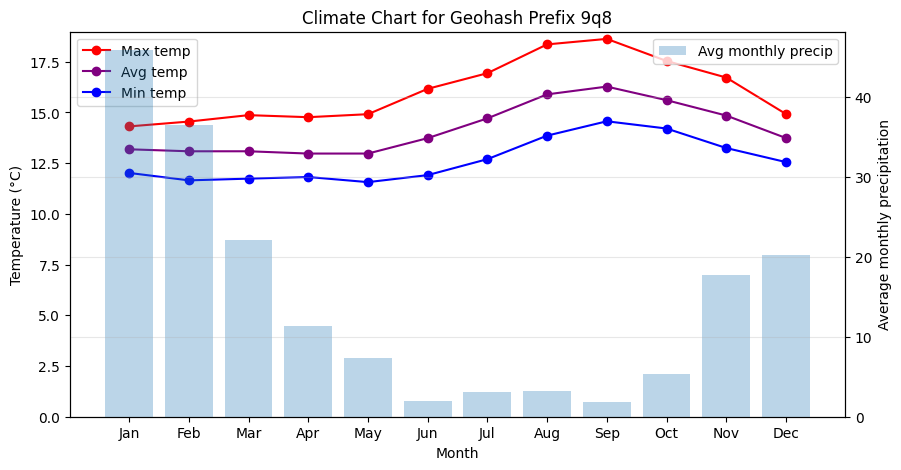

```
Total Climate Chart Spark runtime: 2224.99 seconds
```

```python
# ------------------------------------------------------------
# Plot
# ------------------------------------------------------------
pdf = climate.toPandas()

if len(pdf) == 0:
    print("No data found for this geohash prefix.")
else:
    month_labels = [
        "Jan", "Feb", "Mar", "Apr", "May", "Jun",
        "Jul", "Aug", "Sep", "Oct", "Nov", "Dec",
    ]

    pdf["month_name"] = pdf["month"].apply(lambda m: month_labels[int(m) - 1])

    fig, ax1 = plt.subplots(figsize=(10, 5))

    ax1.plot(
        pdf["month_name"],
        pdf["high_temp_c"],
        marker="o",
        color="red",
        label="Max temp",
    )

    ax1.plot(
        pdf["month_name"],
        pdf["avg_temp_c"],
        marker="o",
        color="purple",
        label="Avg temp",
    )

    ax1.plot(
        pdf["month_name"],
        pdf["low_temp_c"],
        marker="o",
        color="blue",
        label="Min temp",
    )

    ax1.set_xlabel("Month")
    ax1.set_ylabel("Temperature (°C)")
    ax1.set_ylim(bottom=0)
    ax1.legend(loc="upper left")

    ax2 = ax1.twinx()

    ax2.bar(
        pdf["month_name"],
        pdf["avg_monthly_precip"],
        alpha=0.3,
        label="Avg monthly precip",
    )

    ax2.set_ylabel("Average monthly precipitation")
    ax2.set_ylim(bottom=0)
    ax2.legend(loc="upper right")

    plt.title(f"Climate Chart for Geohash Prefix {GEOHASH_PREFIX}")
    plt.grid(True, axis="y", alpha=0.3)
    plt.show()

climate_chart_runtime = time.perf_counter() - climate_chart_runtime_start
print(f"Total Climate Chart Spark runtime: {climate_chart_runtime:.2f} seconds")
```

## Travel Startup

```python
import sys
import importlib
import re
import time

import matplotlib.pyplot as plt
import pandas as pd

from pyspark.sql import functions as F
from pyspark.sql.types import (
    StructType,
    StructField,
    StringType,
    LongType,
    DoubleType,
)
from pyspark.sql.window import Window

import util
import SparkHandler

importlib.reload(util)
importlib.reload(SparkHandler)

from util import safe_float
from SparkHandler import Sparky, SparkyBatchContext, SparkyAnalysisContext


# ============================================================
# CONFIG
# ============================================================
sc.setLogLevel("ERROR")
INPUT_GLOB = "hdfs:///3hr/2018/*"
BATCH_SIZE = 50
PARTIAL_OUT = "hdfs:///travel_startup_2018_partials"

TRAVEL_WINDOWS = [
    ("Winter Break / New Year", [12, 1]),
    ("Spring", [2, 3, 4]),
    ("Early Summer", [5, 6, 7]),
    ("Late Summer", [8, 9]),
    ("Fall", [10, 11]),
]

REGIONS = [
    {
        "region": "San Francisco Bay Area",
        "lat_min": 37.2,
        "lat_max": 38.2,
        "lon_min": -122.8,
        "lon_max": -121.7,
    },
    {
        "region": "Los Angeles Coast",
        "lat_min": 33.5,
        "lat_max": 34.4,
        "lon_min": -118.8,
        "lon_max": -117.7,
    },
    {
        "region": "San Diego Coast",
        "lat_min": 32.5,
        "lat_max": 33.1,
        "lon_min": -117.4,
        "lon_max": -116.8,
    },
    {
        "region": "Seattle / Puget Sound",
        "lat_min": 47.2,
        "lat_max": 47.9,
        "lon_min": -122.7,
        "lon_max": -121.9,
    },
    {
        "region": "Portland / Willamette Valley",
        "lat_min": 45.2,
        "lat_max": 45.8,
        "lon_min": -123.1,
        "lon_max": -122.2,
    },
    {
        "region": "Denver / Front Range",
        "lat_min": 39.4,
        "lat_max": 40.1,
        "lon_min": -105.4,
        "lon_max": -104.5,
    },
    {
        "region": "Las Vegas",
        "lat_min": 35.9,
        "lat_max": 36.5,
        "lon_min": -115.5,
        "lon_max": -114.8,
    },
    {
        "region": "Phoenix / Scottsdale",
        "lat_min": 33.2,
        "lat_max": 33.8,
        "lon_min": -112.4,
        "lon_max": -111.6,
    },
    {
        "region": "New York City",
        "lat_min": 40.3,
        "lat_max": 41.1,
        "lon_min": -74.4,
        "lon_max": -73.4,
    },
    {
        "region": "Chicago",
        "lat_min": 41.5,
        "lat_max": 42.2,
        "lon_min": -88.1,
        "lon_max": -87.3,
    },
    {
        "region": "Miami",
        "lat_min": 25.5,
        "lat_max": 26.1,
        "lon_min": -80.5,
        "lon_max": -80.0,
    },
    {
        "region": "New Orleans",
        "lat_min": 29.7,
        "lat_max": 30.3,
        "lon_min": -90.4,
        "lon_max": -89.7,
    },
    {
        "region": "Boston",
        "lat_min": 42.1,
        "lat_max": 42.6,
        "lon_min": -71.4,
        "lon_max": -70.8,
    },
    {
        "region": "Vancouver",
        "lat_min": 49.0,
        "lat_max": 49.5,
        "lon_min": -123.4,
        "lon_max": -122.7,
    },
]

IDEAL_TEMP_C = 21.0
MAX_COMFORT_HIGH_C = 30.0
MIN_COMFORT_LOW_C = 8.0


def safe_window_name(window_name):
    return re.sub(r"[^a-zA-Z0-9_]+", "_", window_name.lower()).strip("_")


def month_from_path(path):
    match = re.search(r"(20\d{2})(\d{2})(\d{2})", path)
    if match is None:
        return None
    return int(match.group(2))


def region_for_point(lat, lon):
    for region in REGIONS:
        if (
            region["lat_min"] <= lat <= region["lat_max"]
            and region["lon_min"] <= lon <= region["lon_max"]
        ):
            return region["region"]
    return None


# ============================================================
# SCHEMA
# ============================================================
raw_schema = StructType([
    StructField("region", StringType(), False),
    StructField("time_ms", LongType(), False),
    StructField("lat", DoubleType(), False),
    StructField("lon", DoubleType(), False),
    StructField("temp_k", DoubleType(), False),
    StructField("precip", DoubleType(), False),
    StructField("rh", DoubleType(), False),
    StructField("cloud", DoubleType(), False),
    StructField("snow", DoubleType(), False),
    StructField("wind_speed", DoubleType(), False),
])


# ============================================================
# PARTIAL TRANSFORM
# ============================================================
def travel_partial_transform(points):
    return (
        points
        .withColumn("lat_i", F.floor(F.col("lat") * 100).cast("int"))
        .withColumn("lon_i", F.floor(F.col("lon") * 100).cast("int"))
        .groupBy("region", "lat_i", "lon_i")
        .agg(
            F.sum("lat").alias("sum_lat"),
            F.sum("lon").alias("sum_lon"),
            F.count("*").alias("count_points"),

            F.sum("temp_k").alias("sum_temp_k"),
            F.count("temp_k").alias("count_temp"),
            F.min("temp_k").alias("min_temp_k"),
            F.max("temp_k").alias("max_temp_k"),

            F.sum("precip").alias("sum_precip"),
            F.count("precip").alias("count_precip"),

            F.sum("rh").alias("sum_rh"),
            F.count("rh").alias("count_rh"),

            F.sum("cloud").alias("sum_cloud"),
            F.count("cloud").alias("count_cloud"),

            F.sum("snow").alias("sum_snow"),
            F.max("snow").alias("max_snow"),
            F.count("snow").alias("count_snow"),

            F.sum("wind_speed").alias("sum_wind"),
            F.count("wind_speed").alias("count_wind"),
        )
    )


# ============================================================
# COMBINE PARTIALS
# ============================================================
def combine_travel_partials(partials):
    return (
        partials
        .groupBy("region", "lat_i", "lon_i")
        .agg(
            (F.sum("sum_lat") / F.sum("count_points")).alias("lat"),
            (F.sum("sum_lon") / F.sum("count_points")).alias("lon"),
```

```python
            F.sum("sum_temp_k").alias("sum_temp_k"),
            F.sum("count_temp").alias("count_temp"),
            F.min("min_temp_k").alias("low_temp_k"),
            F.max("max_temp_k").alias("high_temp_k"),

            F.sum("sum_precip").alias("sum_precip"),
            F.sum("count_precip").alias("count_precip"),

            F.sum("sum_rh").alias("sum_rh"),
            F.sum("count_rh").alias("count_rh"),

            F.sum("sum_cloud").alias("sum_cloud"),
            F.sum("count_cloud").alias("count_cloud"),

            F.sum("sum_snow").alias("sum_snow"),
            F.max("max_snow").alias("max_snow"),
            F.sum("count_snow").alias("count_snow"),

            F.sum("sum_wind").alias("sum_wind"),
            F.sum("count_wind").alias("count_wind"),

            F.sum("count_points").alias("cell_points"),
        )
        .withColumn("avg_temp_k", F.col("sum_temp_k") / F.col("count_temp"))
        .withColumn("avg_precip_per_3hr", F.col("sum_precip") / F.col("count_precip"))
        .withColumn("avg_daily_precip", F.col("avg_precip_per_3hr") * F.lit(8.0))
        .withColumn("avg_rh", F.col("sum_rh") / F.col("count_rh"))
        .withColumn("avg_cloud", F.col("sum_cloud") / F.col("count_cloud"))
        .withColumn("avg_snow", F.col("sum_snow") / F.col("count_snow"))
        .withColumn("avg_wind", F.col("sum_wind") / F.col("count_wind"))
    )


# ============================================================
# ANALYZER
# ============================================================
def make_travel_analyzer(window_name, months):
    def analyze_travel_window(cell_window):
        region_window = (
            cell_window
            .groupBy("region")
            .agg(
                F.avg("lat").alias("lat"),
                F.avg("lon").alias("lon"),

                F.avg("avg_temp_k").alias("avg_temp_k"),
                F.avg("low_temp_k").alias("low_temp_k"),
                F.avg("high_temp_k").alias("high_temp_k"),

                F.avg("avg_daily_precip").alias("avg_daily_precip"),
                F.avg("avg_rh").alias("avg_rh"),
                F.avg("avg_cloud").alias("avg_cloud"),
                F.avg("avg_snow").alias("avg_snow"),
                F.max("max_snow").alias("max_snow"),
                F.avg("avg_wind").alias("avg_wind"),

                F.sum("cell_points").alias("region_points"),
                F.count("*").alias("region_cells"),
            )
            .withColumn("travel_window", F.lit(window_name))
            .withColumn("months", F.lit(",".join(str(month) for month in months)))
            .withColumn("avg_temp_c", F.col("avg_temp_k") - F.lit(273.15))
            .withColumn("low_temp_c", F.col("low_temp_k") - F.lit(273.15))
            .withColumn("high_temp_c", F.col("high_temp_k") - F.lit(273.15))
        )

        return (
            region_window
            .withColumn(
                "temp_penalty",
                F.abs(F.col("avg_temp_c") - F.lit(IDEAL_TEMP_C)) * F.lit(3.0),
            )
            .withColumn(
                "heat_penalty",
                F.greatest(
                    F.col("high_temp_c") - F.lit(MAX_COMFORT_HIGH_C),
                    F.lit(0.0),
                ) * F.lit(2.0),
            )
            .withColumn(
                "cold_penalty",
                F.greatest(
                    F.lit(MIN_COMFORT_LOW_C) - F.col("low_temp_c"),
                    F.lit(0.0),
                ) * F.lit(2.0),
            )
            .withColumn(
                "rain_penalty",
                F.least(F.col("avg_daily_precip") * F.lit(5.0), F.lit(25.0)),
            )
            .withColumn(
                "humidity_penalty",
                F.greatest(F.col("avg_rh") - F.lit(70.0), F.lit(0.0)) * F.lit(0.35),
            )
            .withColumn(
                "cloud_penalty",
                F.least(F.col("avg_cloud") / F.lit(10.0), F.lit(10.0)),
            )
            .withColumn(
                "wind_penalty",
                F.greatest(F.col("avg_wind") - F.lit(6.0), F.lit(0.0)) * F.lit(3.0),
            )
            .withColumn(
                "snow_penalty",
                F.least(F.col("max_snow") * F.lit(20.0), F.lit(20.0)),
            )
            .withColumn(
                "comfort_index_raw",
                F.lit(100.0)
                - F.col("temp_penalty")
                - F.col("heat_penalty")
                - F.col("cold_penalty")
                - F.col("rain_penalty")
                - F.col("humidity_penalty")
                - F.col("cloud_penalty")
                - F.col("wind_penalty")
                - F.col("snow_penalty"),
            )
            .withColumn(
                "comfort_index",
                F.least(F.greatest(F.col("comfort_index_raw"), F.lit(0.0)), F.lit(100.0)),
            )
            .select(
                "travel_window",
                "months",
                "region",
                "lat",
                "lon",
                "comfort_index",
                "avg_temp_c",
                "low_temp_c",
                "high_temp_c",
                "avg_daily_precip",
                "avg_rh",
                "avg_cloud",
                "avg_wind",
                "avg_snow",
                "max_snow",
                "temp_penalty",
                "heat_penalty",
                "cold_penalty",
                "rain_penalty",
                "humidity_penalty",
                "cloud_penalty",
                "wind_penalty",
                "snow_penalty",
                "region_points",
                "region_cells",
            )
        )

    return analyze_travel_window


sparky = Sparky(spark, sc)

setup_ctx = SparkyBatchContext(
    glob_path=INPUT_GLOB,
    partial_out=PARTIAL_OUT,
    schema=raw_schema,
    parse_line=lambda line: None,
    partial_transform=travel_partial_transform,
    batch_size=BATCH_SIZE,
)

all_paths = sparky.setup_job(setup_ctx)

print("Total 2018 files:", len(all_paths))

if len(all_paths) == 0:
    raise ValueError(f"No files matched: {INPUT_GLOB}")
```

```python
paths_by_window = {}

for window_name, months in TRAVEL_WINDOWS:
    month_set = set(months)
    window_paths = [path for path in all_paths if month_from_path(path) in month_set]
    paths_by_window[window_name] = window_paths
    print(f"{window_name}: {len(window_paths)} 2018 files")


# ============================================================
# RESOLVE COLUMNS
# ============================================================
time_idx = sparky.required_col("time")
lat_idx = sparky.required_col("lat")
lon_idx = sparky.required_col("lon")
temp_idx = sparky.required_col("temperature_surface")
precip_idx = sparky.required_col("total_precipitation_surface_3_hour_accumulation")
rh_idx = sparky.required_col("relative_humidity_zerodegc_isotherm")
cloud_idx = sparky.required_col("total_cloud_cover_entire_atmosphere_single_layer")
snow_idx = sparky.required_col("snow_depth_surface")
wind_speed_idx = sparky.required_col("wind_speed_gust_surface")

print("Using column indexes:")
print("time:", time_idx)
print("lat:", lat_idx)
print("lon:", lon_idx)
print("temp:", temp_idx)
print("precip:", precip_idx)
print("rh:", rh_idx)
print("cloud:", cloud_idx)
print("snow:", snow_idx)
print("wind_speed:", wind_speed_idx)


# ============================================================
# PARSER
# ============================================================
def make_travel_parser(
    time_idx,
    lat_idx,
    lon_idx,
    temp_idx,
    precip_idx,
    rh_idx,
    cloud_idx,
    snow_idx,
    wind_speed_idx,
):
    def parse_travel_line(line):
        try:
            if line.startswith("1_time"):
                return None

            parts = line.rstrip("\t").split("\t")

            time_ms = safe_float(parts, time_idx)
            lat = safe_float(parts, lat_idx)
            lon = safe_float(parts, lon_idx)
            temp_k = safe_float(parts, temp_idx)
            precip = safe_float(parts, precip_idx)
            rh = safe_float(parts, rh_idx)
            cloud = safe_float(parts, cloud_idx)
            snow = safe_float(parts, snow_idx)
            wind_speed = safe_float(parts, wind_speed_idx)

            if (
                time_ms is None
                or lat is None
                or lon is None
                or temp_k is None
                or precip is None
                or rh is None
                or cloud is None
                or snow is None
                or wind_speed is None
            ):
                return None

            region = region_for_point(lat, lon)

            if region is None:
                return None

            return (
                region,
                int(time_ms),
                lat,
                lon,
                temp_k,
                precip,
                rh,
                cloud,
                snow,
                wind_speed,
            )

        except Exception:
            return None

    return parse_travel_line


parse_travel_line = make_travel_parser(
    time_idx=time_idx,
    lat_idx=lat_idx,
    lon_idx=lon_idx,
    temp_idx=temp_idx,
    precip_idx=precip_idx,
    rh_idx=rh_idx,
    cloud_idx=cloud_idx,
    snow_idx=snow_idx,
    wind_speed_idx=wind_speed_idx,
)


# ============================================================
# PROCESS ONE WINDOW
# ============================================================
def process_window(window_name, months, window_paths):
    cleaned_window_name = safe_window_name(window_name)
    window_out = f"{PARTIAL_OUT}/{cleaned_window_name}"

    print()
    print("=" * 80)
    print(f"Processing 2018 window: {window_name}")
    print(f"Months: {months}")
    print(f"Files: {len(window_paths)}")
    print("=" * 80)

    if len(window_paths) == 0:
        print(f"No 2018 files for {window_name}; skipping.")
        return None

    batch_ctx = SparkyBatchContext(
        glob_path=INPUT_GLOB,
        partial_out=window_out,
        schema=raw_schema,
        parse_line=parse_travel_line,
        partial_transform=travel_partial_transform,
        batch_size=BATCH_SIZE,
    )

    analysis_ctx = SparkyAnalysisContext(
        partial_in=window_out,
        combine_partials=combine_travel_partials,
        analyze=make_travel_analyzer(window_name, months),
        result_out=None,
    )

    window_start = time.perf_counter()

    for batch_id, start in enumerate(range(0, len(window_paths), batch_ctx.batch_size)):
        batch_start = time.perf_counter()
        batch_paths = window_paths[start:start + batch_ctx.batch_size]
        sparky.process_batch(batch_ctx, batch_paths, batch_id)
        batch_elapsed = time.perf_counter() - batch_start
        print(f"Finished {window_name} batch {batch_id} in {batch_elapsed:.2f} seconds")

    cell_window = sparky.combine(analysis_ctx)
    scored = sparky.analyze(analysis_ctx, cell_window)

    window_elapsed = time.perf_counter() - window_start
    print(f"Finished 2018 window {window_name} in {window_elapsed:.2f} seconds")

    return scored


# ============================================================
# RUN ALL TRAVEL WINDOWS
# ============================================================
scored_windows = []
overall_start = time.perf_counter()

for window_name, months in TRAVEL_WINDOWS:
    scored = process_window(
        window_name=window_name,
        months=months,
        window_paths=paths_by_window[window_name],
    )

    if scored is not None:
        scored_windows.append(scored)

overall_elapsed = time.perf_counter() - overall_start
print(f"Total 2018 Travel Startup Spark runtime: {overall_elapsed:.2f} seconds")

if len(scored_windows) == 0:
    raise ValueError("No scored 2018 windows were produced.")

all_scores = scored_windows[0]

for scored in scored_windows[1:]:
    all_scores = all_scores.unionByName(scored)


# ============================================================
# BEST REGION PER TRAVEL WINDOW
# ============================================================
ranked = (
    all_scores
    .withColumn(
        "rank_in_window",
        F.row_number().over(
            Window.partitionBy("travel_window").orderBy(F.desc("comfort_index"))
        ),
    )
)
```

```python
best_per_window = (
    ranked
    .filter(F.col("rank_in_window") == 1)
    .drop("rank_in_window")
    .orderBy(
        F.expr("""
            CASE travel_window
                WHEN 'Winter Break / New Year' THEN 1
                WHEN 'Spring' THEN 2
                WHEN 'Early Summer' THEN 3
                WHEN 'Late Summer' THEN 4
                WHEN 'Fall' THEN 5
                ELSE 99
            END
        """)
    )
)

print("Best destination for each 2018 travel window:")
best_per_window.select(
    "travel_window",
    "months",
    "region",
    "comfort_index",
    "avg_temp_c",
    "low_temp_c",
    "high_temp_c",
    "avg_daily_precip",
    "avg_rh",
    "avg_cloud",
    "avg_wind",
    "max_snow",
    "region_cells",
).show(truncate=False)

print("All 2018 destination scores:")
all_scores.orderBy("travel_window", F.desc("comfort_index")).select(
    "travel_window",
    "months",
    "region",
    "comfort_index",
    "avg_temp_c",
    "low_temp_c",
    "high_temp_c",
    "avg_daily_precip",
    "avg_rh",
    "avg_cloud",
    "avg_wind",
    "max_snow",
    "region_cells",
).show(200, truncate=False)
```

```
Deleted old partial output: hdfs:/travel_startup_2018_partials
Found 1443 files
```

```
Total 2018 files: 1443
Winter Break / New Year: 248 2018 files
Spring: 340 2018 files
Early Summer: 367 2018 files
Late Summer: 244 2018 files
Fall: 244 2018 files
Using column indexes:
time: 0
lat: 1
lon: 2
temp: 10
precip: 13
rh: 8
cloud: 12
snow: 9
wind_speed: 17

================================================================================
Processing 2018 window: Winter Break / New Year
Months: [12, 1]
Files: 248
================================================================================
Processing batch 0: 50 files
```

```
Finished Winter Break / New Year batch 0 in 23.74 seconds
Processing batch 1: 50 files
```

```
Finished Winter Break / New Year batch 1 in 21.65 seconds
Processing batch 2: 50 files
```

```
Finished Winter Break / New Year batch 2 in 21.77 seconds
Processing batch 3: 50 files
```

```
Finished Winter Break / New Year batch 3 in 17.31 seconds
Processing batch 4: 48 files
```

```
Finished Winter Break / New Year batch 4 in 16.17 seconds
Finished 2018 window Winter Break / New Year in 101.05 seconds

================================================================================
Processing 2018 window: Spring
Months: [2, 3, 4]
Files: 340
================================================================================
Processing batch 0: 50 files
```

```
Finished Spring batch 0 in 16.84 seconds
Processing batch 1: 50 files
```

```
Finished Spring batch 1 in 16.98 seconds
Processing batch 2: 50 files
```

```
Finished Spring batch 2 in 16.17 seconds
Processing batch 3: 50 files
```

```
Finished Spring batch 3 in 16.85 seconds
Processing batch 4: 50 files
```

```
Finished Spring batch 4 in 17.14 seconds
Processing batch 5: 50 files
```

```
Finished Spring batch 5 in 17.22 seconds
Processing batch 6: 40 files
```

```
Finished Spring batch 6 in 16.28 seconds
Finished 2018 window Spring in 117.94 seconds

================================================================================
Processing 2018 window: Early Summer
Months: [5, 6, 7]
Files: 367
================================================================================
Processing batch 0: 50 files
```

```
Finished Early Summer batch 0 in 16.98 seconds
Processing batch 1: 50 files
```

```
Finished Early Summer batch 1 in 15.34 seconds
Processing batch 2: 50 files
```

```
Finished Early Summer batch 2 in 16.10 seconds
Processing batch 3: 50 files
```

```
Finished Early Summer batch 3 in 17.33 seconds
Processing batch 4: 50 files
```

```
Finished Early Summer batch 4 in 16.82 seconds
Processing batch 5: 50 files
```

```
Finished Early Summer batch 5 in 17.62 seconds
Processing batch 6: 50 files
```

```
Finished Early Summer batch 6 in 17.86 seconds
Processing batch 7: 17 files
```

```
Finished Early Summer batch 7 in 10.67 seconds
Finished 2018 window Early Summer in 129.16 seconds

================================================================================
Processing 2018 window: Late Summer
Months: [8, 9]
Files: 244
================================================================================
Processing batch 0: 50 files
```

```
Finished Late Summer batch 0 in 16.75 seconds
Processing batch 1: 50 files
```

```
Finished Late Summer batch 1 in 17.77 seconds
Processing batch 2: 50 files
```

```
Finished Late Summer batch 2 in 18.31 seconds
Processing batch 3: 50 files
```

```
Finished Late Summer batch 3 in 16.74 seconds
Processing batch 4: 44 files
```

```
Finished Late Summer batch 4 in 17.10 seconds
Finished 2018 window Late Summer in 87.10 seconds

================================================================================
Processing 2018 window: Fall
Months: [10, 11]
Files: 244
================================================================================
Processing batch 0: 50 files
```

```
Finished Fall batch 0 in 17.50 seconds
Processing batch 1: 50 files
```

```
Finished Fall batch 1 in 16.95 seconds
Processing batch 2: 50 files
```

```
Finished Fall batch 2 in 15.63 seconds
Processing batch 3: 50 files
```

```
Finished Fall batch 3 in 16.51 seconds
Processing batch 4: 44 files
```

```
Finished Fall batch 4 in 17.10 seconds
Finished 2018 window Fall in 84.15 seconds
Total 2018 Travel Startup Spark runtime: 519.40 seconds
Best destination for each 2018 travel window:
```

```
+-----------------------+------+----------------------+-----------------+------------------+------------------+------------------+-------------------+------------------+------------------+------------------+--------+------------+
|travel_window          |months|region                |comfort_index    |avg_temp_c        |low_temp_c        |high_temp_c       |avg_daily_precip   |avg_rh            |avg_cloud         |avg_wind          |max_snow|region_cells|
+-----------------------+------+----------------------+-----------------+------------------+------------------+------------------+-------------------+------------------+------------------+------------------+--------+------------+
|Winter Break / New Year|12,1  |Miami                 |78.07625905889968|22.60698234062977 |12.499861904761872|30.206612857142943|1.7699692780337943 |30.741935483870964|43.60349462365591 |7.159790784130184 |0.0     |21          |
|Spring                 |2,3,4 |New Orleans           |75.72603480160166|19.214442488843872|6.202835517241397 |29.882799999999918|1.987981744421906  |34.21196754563895 |46.18225152129816 |6.254943275057809 |0.0     |29          |
|Early Summer           |5,6,7 |Vancouver             |76.88059243809968|17.738883249614958|7.667636521739155 |31.854160000000036|0.9808079611420447 |58.77898125245823 |36.24570548513209 |2.939737445120247 |0.02172 |23          |
|Late Summer            |8,9   |San Francisco Bay Area|78.30875940109274|19.323642155191294|10.4081458666667  |36.11454746666681 |0.09863387978142077|20.676612021857917|39.375027322404385|4.793583148777318 |1.2E-4  |75          |
|Fall                   |10,11 |Los Angeles Coast     |82.2612633729508 |19.143465542740046|11.329275571428695|33.20703571428572 |0.5796545667447308 |26.397599531615924|28.535889929742382|3.3943909924268145|1.6E-4  |70          |
+-----------------------+------+----------------------+-----------------+------------------+------------------+------------------+-------------------+------------------+------------------+------------------+--------+------------+

All 2018 destination scores:
```

```
[Stage 847:=============================================>           (4 + 1) / 5]
```

```
+-----------------------+------+----------------------------+------------------+-------------------+--------------------+------------------+-------------------+------------------+------------------+------------------+--------+------------+
|travel_window          |months|region                      |comfort_index     |avg_temp_c         |low_temp_c          |high_temp_c       |avg_daily_precip   |avg_rh            |avg_cloud         |avg_wind          |max_snow|region_cells|
+-----------------------+------+----------------------------+------------------+-------------------+--------------------+------------------+-------------------+------------------+------------------+------------------+--------+------------+
|Early Summer           |5,6,7 |Vancouver                   |76.8805924380998  |17.738883249614958 |7.667636521739155   |31.85415999999998 |0.9808079611420449 |58.778981252458244|36.24570548513209 |2.939737445120247 |0.02172 |23          |
|Early Summer           |5,6,7 |San Francisco Bay Area      |75.23419130027237 |18.594241428519638 |8.945867600000042   |36.24976840000022 |0.1333878292461399 |28.30153861398728 |43.81257039055402 |5.973426027602543 |4.0E-5  |75          |
|Early Summer           |5,6,7 |Boston                      |68.71109728719576 |21.34224604774886  |6.2502580952381095  |36.7153295238096  |1.661411703646036  |45.31821435785649 |47.5632541845076  |6.089545925244583 |0.0     |21          |
|Early Summer           |5,6,7 |Chicago                     |67.27978765866976 |20.157102663653916 |6.3914039024390945  |33.806859024390235|3.0575197713830002 |45.534758081876774|40.73011231474713 |5.5604947237523765|0.0     |41          |
|Early Summer           |5,6,7 |Los Angeles Coast           |65.29434501907262 |23.09865853016754  |12.361159000000043  |41.73394728571452 |0.15988711560918653|26.86214844920203 |41.415492409497865|2.9103841196220315|4.0E-5  |70          |
|Early Summer           |5,6,7 |Seattle / Puget Sound       |65.08614318948342 |19.54412570807858  |6.672773513513505   |39.57482486486492 |0.8950217247219973 |51.90821853243979 |42.670226084395026|3.145185755161205 |0.0     |37          |
|Early Summer           |5,6,7 |San Diego Coast             |65.04266619945477 |22.34063886648505  |11.719746400000076  |42.14704920000008 |0.3068664850136239 |26.71588920326975 |51.069863760217984|2.655238927747139 |0.0     |25          |
|Early Summer           |5,6,7 |New York City               |61.49962273024549 |21.583587757740816 |5.88843345454552    |35.008065818181876|3.529749814218481  |45.51155926182808 |48.61600198166955 |5.661918150071341 |0.0     |55          |
|Early Summer           |5,6,7 |Portland / Willamette Valley|60.256616593248694|19.270396457008815 |4.911733333333359   |41.103897500000016|0.4607553739025128 |42.67463276899789 |38.6566757493188  |3.592475078387603 |4.0E-5  |36          |
|Early Summer           |5,6,7 |Denver / Front Range        |47.38774939600382 |21.7473702925912   |2.846803095238158   |44.16499380952371 |1.5713961333852342 |56.44744753341117 |33.83177630725314 |4.02809529046062  |0.02468 |42          |
|Early Summer           |5,6,7 |New Orleans                 |35.072104705440026|30.00199334398195  |16.794864827586252  |39.02017965517251 |3.3674245983275393 |47.916197388142436|30.444329606314003|3.780804649848726 |0.0     |29          |
|Early Summer           |5,6,7 |Miami                       |34.061678971065085|28.8349238782925   |22.670041904761945  |36.3000366666667  |6.954262358894512  |58.154596877124696|48.33476060724017 |4.438683072408201 |0.0     |21          |
|Early Summer           |5,6,7 |Las Vegas                   |28.930224415985528|29.585398483197082 |8.889546666666718   |51.28879733333332 |0.29037238873751137|38.99650682942779 |12.84123524069028 |4.251871068663942 |0.0     |30          |
|Early Summer           |5,6,7 |Phoenix / Scottsdale        |8.828341656826964 |33.53106707462916  |11.292545277777776  |55.0890052777778  |0.445201332122313  |36.030672734786556|11.744399031183772|3.893489302041704 |0.0     |36          |
```

[output cut: 57 more lines]

## Your Itinerary

The itinerary has been designed for travelling in 2019-20, with 2018 data as a base for our trademarked comfort scorer pro max. We will start our travels in Feb, so that we can end the year with a bang with Christmas + New Year. We will divide your journey into 5 time periods.

- Feb - Apr
- May - Jul
- Aug - Sep
- Oct - Nov
- Dec - Jan

### Spring (Feb - Apr)

Spring time in New Orleans would be amazing! Check out one of the beautiful gardens you can visit:

[figure not shown]

There are also festivals to attend, like this one:

[figure not shown]

### Early Summer (May - Jul)

The longest leg of this year-long journey takes us to Vancouver, Canada!

[figure not shown]

### Late Summer (Aug - Sept)

San Francisco Bay Area

There are lots of things to do in San Francisco, and it might be a good idea to visit Seattle, and other surrounding places.

- San Francisco

[figure not shown]

### Fall (Oct - Nov)

Los Angeles coast had the best score for fall. You can enjoy:

- Santa Monica Beach

[figure not shown]

- Venice Beach

[figure not shown]

and many more beaches, each with its own charm!

Although Los Angeles coast scored the highest on this leg of the trip, we will also visit other places nearby!

Time to go to San Diego.

[figure not shown]

Enjoy the festivities in October!

[figure not shown]

Las Vegas is close too!

- Las Vegas

[figure not shown]

### Christmas - New Year

Time to head to Miami for Christmas and New year celebrations! This party and beach town averages 70F at this time.

[figure not shown]

#### Remarks

I think it is a little awkward that Late Summer was SF bay area and Fall was LA. If I had to do this differently, maybe I would have enforced a distance too? Something to make sure that places close to each other wouldn't be picked in conscutive travel windows...

## LEAST FOGGY (I AM RICH)

```python
from pyspark.sql import functions as F
from pyspark.sql.types import StructType, StructField, LongType, DoubleType

from SparkHandler import Sparky, SparkyBatchContext, SparkyAnalysisContext
import util

import math
import gc
import os
import time
import folium
from IPython.display import IFrame, display

# Restore SparkContext in case `sc` got overwritten by matplotlib
sc = spark.sparkContext

# ============================================================
# CONFIG
# ============================================================

INPUT_GLOB = "hdfs:///3hr/*/*_20*{07,08,09,10}*_*"
BATCH_SIZE = 50

PARTIAL_OUT = f"hdfs:///user/{sc.sparkUser()}/least_foggy_bay_area_partials"
RESULT_OUT = None

# Bay Area bounding box
LAT_MIN = 36.8
LAT_MAX = 38.9
LON_MIN = -123.2
LON_MAX = -121.4

# Fog season
FOG_MONTHS = [5, 6, 7, 8, 9]

# 20 -> 0.05 degree cells
CELL_SCALE = 20

MIN_CELL_POINTS = 100
TOP_N = 10
```

```python
# ============================================================
# SCHEMA
# ============================================================

raw_schema = StructType([
    StructField("time_ms", LongType(), False),
    StructField("lat", DoubleType(), False),
    StructField("lon", DoubleType(), False),
    StructField("cloud", DoubleType(), True),
    StructField("visibility", DoubleType(), True),
])

time_idx = None
lat_idx = None
lon_idx = None
cloud_idx = None
vis_idx = None
```

```python
# ============================================================
# PARSER
# ============================================================

def parse_fog_line(line):
    try:
        if line.startswith("1_time"):
            return None

        parts = line.rstrip("\t").split("\t")

        time_ms = util.safe_float(parts, time_idx)
        lat = util.safe_float(parts, lat_idx)
        lon = util.safe_float(parts, lon_idx)

        if time_ms is None or lat is None or lon is None:
            return None

        # Early geographic filter
        if not (LAT_MIN <= lat <= LAT_MAX and LON_MIN <= lon <= LON_MAX):
            return None

        cloud = util.safe_float(parts, cloud_idx)
        visibility = util.safe_float(parts, vis_idx)

        return (
            int(time_ms),
            lat,
            lon,
            cloud,
            visibility,
        )

    except Exception:
        return None

# ============================================================
# PARTIAL TRANSFORM
# This runs once per 50-file batch
# ============================================================

def partial_transform(points):
    points = (
        points
        .withColumn(
            "timestamp",
            F.from_unixtime((F.col("time_ms") / 1000).cast("long")).cast("timestamp")
        )
        .withColumn("month", F.month("timestamp"))
    )

    if FOG_MONTHS is not None:
        points = points.filter(F.col("month").isin(FOG_MONTHS))

    return (
        points
        .withColumn("lat_i", F.floor(F.col("lat") * CELL_SCALE).cast("int"))
        .withColumn("lon_i", F.floor(F.col("lon") * CELL_SCALE).cast("int"))
        .groupBy("lat_i", "lon_i")
        .agg(
            F.sum("lat").alias("sum_lat"),
            F.sum("lon").alias("sum_lon"),
            F.count("*").alias("count_points"),

            F.sum("cloud").alias("sum_cloud"),
            F.count("cloud").alias("count_cloud"),

            F.sum("visibility").alias("sum_visibility"),
            F.count("visibility").alias("count_visibility"),
        )
    )

# ============================================================
# COMBINE PARTIALS
# This combines all batch parquet files
# ============================================================

def combine_fog_partials(partials):
    combined = (
        partials
        .groupBy("lat_i", "lon_i")
        .agg(
            F.sum("sum_lat").alias("sum_lat"),
            F.sum("sum_lon").alias("sum_lon"),
            F.sum("count_points").alias("cell_points"),

            F.sum("sum_cloud").alias("sum_cloud"),
            F.sum("count_cloud").alias("count_cloud"),

            F.sum("sum_visibility").alias("sum_visibility"),
            F.sum("count_visibility").alias("count_visibility"),
        )
    )

    return (
        combined
        .withColumn("lat", F.col("sum_lat") / F.col("cell_points"))
        .withColumn("lon", F.col("sum_lon") / F.col("cell_points"))

        .withColumn(
            "avg_cloud",
            F.when(F.col("count_cloud") > 0, F.col("sum_cloud") / F.col("count_cloud"))
        )
        .withColumn(
            "avg_visibility",
            F.when(
                F.col("count_visibility") > 0,
                F.col("sum_visibility") / F.col("count_visibility")
            )
        )

        .select(
            "lat_i",
            "lon_i",
            "lat",
            "lon",
            "cell_points",
            "avg_cloud",
            "avg_visibility",
        )
    )
```

```python
# ============================================================
# ANALYZE
# Builds fog_score and clarity_score
# ============================================================

def clamp01(col):
    return F.least(F.greatest(col, F.lit(0.0)), F.lit(1.0))

def analyze_least_foggy(cell_stats):
    scored = (
        cell_stats
        .withColumn("avg_cloud_filled", F.coalesce(F.col("avg_cloud"), F.lit(40.0)))
        .withColumn("avg_visibility_filled", F.coalesce(F.col("avg_visibility"), F.lit(20000.0)))
    )

    cloud_term = clamp01(F.col("avg_cloud_filled") / F.lit(100.0))
    vis_term = clamp01((F.lit(20000.0) - F.col("avg_visibility_filled")) / F.lit(20000.0))

    if vis_idx is not None:
        scored = scored.withColumn(
            "fog_score",
            F.lit(0.30) * cloud_term +
            F.lit(0.20) * vis_term
        )
    else:
        scored = scored.withColumn(
            "fog_score", cloud_term
        )

    return (
        scored
        .withColumn("clarity_score", F.lit(100.0) * (F.lit(1.0) - F.col("fog_score")))
        .filter(F.col("cell_points") >= MIN_CELL_POINTS)
        .orderBy(
            F.desc("clarity_score"),
            F.asc("avg_cloud_filled"),
        )
    )

# ============================================================
# SETUP SPARKY
# ============================================================

sparky = Sparky(spark, sc)

batch_ctx = SparkyBatchContext(
    glob_path=INPUT_GLOB,
    partial_out=PARTIAL_OUT,
    schema=raw_schema,
    parse_line=parse_fog_line,
    partial_transform=partial_transform,
    batch_size=BATCH_SIZE,
)

least_foggy_runtime_start = time.perf_counter()
input_paths = sparky.setup_job(batch_ctx)

print("Total input files:", len(input_paths))
print("Batch size:", BATCH_SIZE)
print("Number of batches:", (len(input_paths) + BATCH_SIZE - 1) // BATCH_SIZE)

if len(input_paths) == 0:
    raise ValueError(f"No files matched: {INPUT_GLOB}")

# ============================================================
# COLUMN DISCOVERY FROM sparky.columns
# ============================================================

def required_idx(name):
    key = name.strip().lower()
    if key not in sparky.columns:
        raise ValueError(f"Missing required column: {name}")
    return sparky.columns[key]

def optional_idx(name):
    key = name.strip().lower()
    return sparky.columns.get(key)

def optional_idx_contains(*tokens):
    tokens = [t.strip().lower() for t in tokens]

    for col_name, idx in sparky.columns.items():
        if all(token in col_name for token in tokens):
            return idx

    return None

time_idx = required_idx("time")
lat_idx = required_idx("lat")
lon_idx = required_idx("lon")

cloud_idx = optional_idx("total_cloud_cover_entire_atmosphere_single_layer")
vis_idx = optional_idx("visibility_surface")

print("Using column indices:")
print("time:", time_idx)
print("lat:", lat_idx)
print("lon:", lon_idx)
print("cloud cover:", cloud_idx)
print("visibility:", vis_idx)
```

```
Deleted old partial output: hdfs:/user/rsbhatia2/least_foggy_bay_area_partials
Found 3194 files
```

```
[Stage 848:>                                                        (0 + 1) / 1]
```

```
Total input files: 3194
Batch size: 50
Number of batches: 64
Using column indices:
time: 0
lat: 1
lon: 2
cloud cover: 12
visibility: 15
```

```python
# ============================================================
# RUN BATCHES THROUGH SPARKY
# ============================================================

for batch_id, start in enumerate(range(0, len(input_paths), BATCH_SIZE)):
    batch_paths = input_paths[start:start + BATCH_SIZE]
    sparky.process_batch(batch_ctx, batch_paths, batch_id)
```

```
Processing batch 0: 50 files
```

```
Processing batch 1: 50 files
```

```
Processing batch 2: 50 files
```

```
Processing batch 3: 50 files
```

```
Processing batch 4: 50 files
```

```
Processing batch 5: 50 files
```

```
Processing batch 6: 50 files
```

```
Processing batch 7: 50 files
```

```
Processing batch 8: 50 files
```

```
Processing batch 9: 50 files
```

```
Processing batch 10: 50 files
```

```
Processing batch 11: 50 files
```

```
Processing batch 12: 50 files
```

```
Processing batch 13: 50 files
```

```
Processing batch 14: 50 files
```

```
Processing batch 15: 50 files
```

```
Processing batch 16: 50 files
```

```
Processing batch 17: 50 files
```

```
Processing batch 18: 50 files
```

```
Processing batch 19: 50 files
```

```
Processing batch 20: 50 files
```

```
Processing batch 21: 50 files
```

```
Processing batch 22: 50 files
```

```
Processing batch 23: 50 files
```

```
Processing batch 24: 50 files
```

```
Processing batch 25: 50 files
```

```
Processing batch 26: 50 files
```

```
Processing batch 27: 50 files
```

```
Processing batch 28: 50 files
```

```
Processing batch 29: 50 files
```

```
Processing batch 30: 50 files
```

```
Processing batch 31: 50 files
```

```
Processing batch 32: 50 files
```

```
Processing batch 33: 50 files
```

```
Processing batch 34: 50 files
```

```
Processing batch 35: 50 files
```

```
Processing batch 36: 50 files
```

```
Processing batch 37: 50 files
```

```
Processing batch 38: 50 files
```

```
Processing batch 39: 50 files
```

```
Processing batch 40: 50 files
```

```
Processing batch 41: 50 files
```

```
Processing batch 42: 50 files
```

```
Processing batch 43: 50 files
```

```
Processing batch 44: 50 files
```

```
Processing batch 45: 50 files
```

```
Processing batch 46: 50 files
```

```
Processing batch 47: 50 files
```

```
Processing batch 48: 50 files
```

```
Processing batch 49: 50 files
```

```
Processing batch 50: 50 files
```

```
Processing batch 51: 50 files
```

```
Processing batch 52: 50 files
```

```
Processing batch 53: 50 files
```

```
Processing batch 54: 50 files
```

```
Processing batch 55: 50 files
```

```
Processing batch 56: 50 files
```

```
Processing batch 57: 50 files
```

```
Processing batch 58: 50 files
```

```
Processing batch 59: 50 files
```

```
Processing batch 60: 50 files
```

```
Processing batch 61: 50 files
```

```
Processing batch 62: 50 files
```

```
Processing batch 63: 44 files
```

```python
# ============================================================
# COMBINE + ANALYZE THROUGH SPARKY
# ============================================================

analysis_ctx = SparkyAnalysisContext(
    partial_in=PARTIAL_OUT,
    combine_partials=combine_fog_partials,
    analyze=analyze_least_foggy,
    result_out=RESULT_OUT,
)

cell_stats = sparky.combine(analysis_ctx)
least_foggy = sparky.analyze(analysis_ctx, cell_stats)
```

```python
# ============================================================
# SHOW RESULTS
# ============================================================

print("Top least-foggy Bay Area cells:")

top_pdf = (
    least_foggy
    .select(
        "lat",
        "lon",
        "clarity_score",
        "fog_score",
        "avg_cloud",
        "avg_visibility",
        "cell_points",
    )
    .limit(TOP_N)
    .toPandas()
)

display(top_pdf)

least_foggy_runtime = time.perf_counter() - least_foggy_runtime_start
print(f"Total Least Foggy Spark runtime: {least_foggy_runtime:.2f} seconds")
```

```
Top least-foggy Bay Area cells:
```

|  | lat | lon | clarity_score | fog_score | avg_cloud | avg_visibility | cell_points |
| --- | --- | --- | --- | --- | --- | --- | --- |
| 0 | 38.877293 | -122.166343 | 98.172023 | 0.018280 | 6.093256 | 24106.990715 | 1892 |
| 1 | 38.850548 | -122.303162 | 98.143547 | 0.018565 | 6.188177 | 24084.512906 | 1201 |
| 2 | 38.773071 | -122.139185 | 98.137302 | 0.018627 | 6.208993 | 24103.445741 | 1892 |
| 3 | 38.788658 | -122.008523 | 98.038884 | 0.019611 | 6.537052 | 24080.099917 | 1201 |
| 4 | 38.689884 | -121.978465 | 98.010408 | 0.019896 | 6.631973 | 24102.070079 | 1892 |
| 5 | 38.892870 | -122.035550 | 98.001166 | 0.019988 | 6.662781 | 24054.870941 | 1201 |
| 6 | 38.746358 | -122.275882 | 97.996919 | 0.020031 | 6.676936 | 24090.507910 | 1201 |
| 7 | 38.668795 | -122.112081 | 97.958951 | 0.020410 | 6.803497 | 24092.757910 | 1892 |
| 8 | 37.580908 | -121.420552 | 97.957952 | 0.020420 | 6.806828 | 24069.001296 | 1892 |
| 9 | 38.834758 | -122.433918 | 97.953455 | 0.020465 | 6.821815 | 24105.667963 | 1892 |

```
Total Least Foggy Spark runtime: 896.84 seconds
```

```python
# ============================================================
# REAL MAP: TOP LAT/LON POINTS ONLY
# ============================================================

def fmt(value, digits=2):
    if value is None:
        return "N/A"
    try:
        if math.isnan(value):
            return "N/A"
    except TypeError:
        pass
    return f"{value:.{digits}f}"

center_lat = top_pdf["lat"].mean() if len(top_pdf) > 0 else 37.7
center_lon = top_pdf["lon"].mean() if len(top_pdf) > 0 else -122.2

m = folium.Map(
    location=[center_lat, center_lon],
    zoom_start=9,
    tiles=None,
)

folium.TileLayer(
    tiles="https://{s}.basemaps.cartocdn.com/light_all/{z}/{x}/{y}{r}.png",
    attr='&copy; <a href="https://www.openstreetmap.org/copyright">OpenStreetMap</a> contributors &copy; <a href="https://carto.com/attributions">CARTO</a>',
    name="CartoDB Positron",
    control=False,
).add_to(m)

for i, row in top_pdf.reset_index(drop=True).iterrows():
    rank = i + 1

    popup_html = f"""
    <b>Rank {rank}: Least-foggy candidate</b><br>
    Latitude: {row['lat']:.4f}<br>
    Longitude: {row['lon']:.4f}<br>
    Clarity score: {fmt(row['clarity_score'])}<br>
    Fog score: {fmt(row['fog_score'], 3)}<br>
    Avg cloud cover: {fmt(row['avg_cloud'])}<br>
    Avg visibility: {fmt(row['avg_visibility'])}<br>
    Cell points: {int(row['cell_points'])}
    """

    folium.Marker(
        location=[row["lat"], row["lon"]],
        popup=folium.Popup(popup_html, max_width=350),
        tooltip=f"#{rank}: clarity {row['clarity_score']:.2f}",
        icon=folium.DivIcon(
            html=f"""
            <div style="
                background-color: black;
                color: white;
                border-radius: 50%;
                width: 30px;
                height: 30px;
                text-align: center;
                line-height: 30px;
                font-weight: bold;
                border: 2px solid white;
                box-shadow: 0 0 4px gray;
            ">
                {rank}
            </div>
            """
        ),
    ).add_to(m)

if len(top_pdf) > 0:
    bounds = [
        [top_pdf["lat"].min(), top_pdf["lon"].min()],
        [top_pdf["lat"].max(), top_pdf["lon"].max()],
    ]
    m.fit_bounds(bounds)

html_path = "least_foggy_bay_area_points.html"
m.save(html_path)

print("Saved map to:", html_path)
display(IFrame(src=html_path, width=950, height=700))
```

```
Saved map to: least_foggy_bay_area_points.html
```

[interactive chart not shown]

## YOLO

Once I am rich and famous and rich and famous and rich, I am going to live in YOLO county, CA. It is the best place for a fogphobic trillionaire like me.

[figure not shown]

## SolarWind Inc

```python
from pyspark.sql import functions as F
from pyspark.sql.types import (
    StructType, StructField,
    StringType, DoubleType
)

from SparkHandler import Sparky, SparkyBatchContext, SparkyAnalysisContext
import util

import os
import time
import math
import folium
from IPython.display import display, IFrame

sc = spark.sparkContext

# ============================================================
# CONFIG
# ============================================================

INPUT_GLOB = "hdfs:///3hr/*/*"
BATCH_SIZE = 50

PARTIAL_OUT = f"hdfs:///user/{sc.sparkUser()}/solarwind_partials_vegetation_land_proxy"
RESULT_OUT = None

GEOHASH_PRECISION = 4

FILE_STRIDE = 24

MIN_GEOHASH_POINTS = 200
TOP_N = 3

MIN_AVG_VEGETATION = 1.0

LAT_COLUMN = "lat"
LON_COLUMN = "lon"
CLOUD_COLUMN = "total_cloud_cover_entire_atmosphere_single_layer"
PRECIP_COLUMN = "total_precipitation_surface_3_hour_accumulation"
WIND_GUST_COLUMN = "wind_speed_gust_surface"
TEMP_COLUMN = "temperature_surface"
VEGETATION_COLUMN = "vegetation_surface"

# ============================================================
# GEOHASH ENCODER
# ============================================================

_BASE32 = "0123456789bcdefghjkmnpqrstuvwxyz"

def encode_geohash(lat, lon, precision=4):
    lat_range = [-90.0, 90.0]
    lon_range = [-180.0, 180.0]

    bits = [16, 8, 4, 2, 1]
    bit = 0
    ch = 0
    even = True
    geohash = []

    while len(geohash) < precision:
        if even:
            mid = (lon_range[0] + lon_range[1]) / 2.0
            if lon >= mid:
                ch |= bits[bit]
                lon_range[0] = mid
            else:
                lon_range[1] = mid
        else:
            mid = (lat_range[0] + lat_range[1]) / 2.0
            if lat >= mid:
                ch |= bits[bit]
                lat_range[0] = mid
            else:
                lat_range[1] = mid

        even = not even

        if bit < 4:
            bit += 1
        else:
            geohash.append(_BASE32[ch])
            bit = 0
            ch = 0

    return "".join(geohash)

# ============================================================
# SCHEMA
# ============================================================

raw_schema = StructType([
    StructField("geohash", StringType(), False),
    StructField("lat", DoubleType(), False),
    StructField("lon", DoubleType(), False),
    StructField("cloud", DoubleType(), False),
    StructField("precip", DoubleType(), False),
    StructField("wind_speed", DoubleType(), False),
    StructField("wind_power_proxy", DoubleType(), False),
    StructField("temp_k", DoubleType(), False),
    StructField("vegetation", DoubleType(), True),
])

lat_idx = None
lon_idx = None
cloud_idx = None
precip_idx = None
wind_gust_idx = None
temp_idx = None
vegetation_idx = None

# ============================================================
# PARSER
# ============================================================

def parse_solarwind_line(line):
    try:
        if line.startswith("1_time"):
            return None

        parts = line.rstrip("\t").split("\t")

        lat = util.safe_float(parts, lat_idx)
        lon = util.safe_float(parts, lon_idx)
        cloud = util.safe_float(parts, cloud_idx)
        precip = util.safe_float(parts, precip_idx)
        wind_speed = util.safe_float(parts, wind_gust_idx)
        temp_k = util.safe_float(parts, temp_idx)
        vegetation = util.safe_float(parts, vegetation_idx)

        if (
            lat is None
            or lon is None
            or cloud is None
            or precip is None
            or wind_speed is None
            or temp_k is None
        ):
            return None

        geohash = encode_geohash(lat, lon, GEOHASH_PRECISION)

        # Wind power is approximately proportional to wind speed cubed.
        wind_power_proxy = wind_speed ** 3

        return (
            geohash,
            lat,
            lon,
            cloud,
            precip,
            wind_speed,
            wind_power_proxy,
            temp_k,
            vegetation,
        )

    except Exception:
        return None

# ============================================================
# PARTIAL TRANSFORM
# Runs once per batch
# ============================================================

def partial_transform(points):
    return (
        points
        .groupBy("geohash")
        .agg(
            F.sum("lat").alias("sum_lat"),
            F.sum("lon").alias("sum_lon"),
            F.count("*").alias("count_points"),

            F.sum("cloud").alias("sum_cloud"),
            F.count("cloud").alias("count_cloud"),

            F.sum("precip").alias("sum_precip"),
            F.count("precip").alias("count_precip"),

            F.sum("wind_speed").alias("sum_wind_speed"),
            F.sum("wind_power_proxy").alias("sum_wind_power_proxy"),
            F.max("wind_speed").alias("max_wind_speed"),
            F.count("wind_speed").alias("count_wind"),

            F.sum("temp_k").alias("sum_temp_k"),
            F.count("temp_k").alias("count_temp"),

            F.sum("vegetation").alias("sum_vegetation"),
            F.count("vegetation").alias("count_vegetation"),
        )
    )

# ============================================================
# COMBINE PARTIALS
# Combines batch parquet files into geohash-level rows
# ============================================================

def combine_solarwind_partials(partials):
    combined = (
        partials
        .groupBy("geohash")
        .agg(
            F.sum("sum_lat").alias("sum_lat"),
            F.sum("sum_lon").alias("sum_lon"),
            F.sum("count_points").alias("points"),

            F.sum("sum_cloud").alias("sum_cloud"),
            F.sum("count_cloud").alias("count_cloud"),

            F.sum("sum_precip").alias("sum_precip"),
            F.sum("count_precip").alias("count_precip"),

            F.sum("sum_wind_speed").alias("sum_wind_speed"),
            F.sum("sum_wind_power_proxy").alias("sum_wind_power_proxy"),
            F.max("max_wind_speed").alias("max_wind_speed"),
            F.sum("count_wind").alias("count_wind"),
```

```python
            F.sum("sum_temp_k").alias("sum_temp_k"),
            F.sum("count_temp").alias("count_temp"),

            F.sum("sum_vegetation").alias("sum_vegetation"),
            F.sum("count_vegetation").alias("count_vegetation"),
        )
    )

    return (
        combined
        .withColumn("lat", F.col("sum_lat") / F.col("points"))
        .withColumn("lon", F.col("sum_lon") / F.col("points"))

        .withColumn("avg_cloud_cover", F.col("sum_cloud") / F.col("count_cloud"))

        # NAM total precipitation field is a 3-hour accumulation.
        .withColumn("avg_precip_3hr", F.col("sum_precip") / F.col("count_precip"))
        .withColumn("avg_daily_precip", F.col("avg_precip_3hr") * F.lit(8.0))

        .withColumn("avg_wind_speed", F.col("sum_wind_speed") / F.col("count_wind"))
        .withColumn("avg_wind_power_proxy", F.col("sum_wind_power_proxy") / F.col("count_wind"))

        .withColumn("avg_temp_k", F.col("sum_temp_k") / F.col("count_temp"))
        .withColumn("avg_temp_c", F.col("avg_temp_k") - F.lit(273.15))

        .withColumn(
            "avg_vegetation",
            F.when(
                F.col("count_vegetation") > 0,
                F.col("sum_vegetation") / F.col("count_vegetation")
            )
        )

        .filter(F.col("points") >= MIN_GEOHASH_POINTS)

        # Approximate land filter.
        # This removes open-ocean-like geohashes using vegetation_surface.
        .filter(F.col("avg_vegetation") >= MIN_AVG_VEGETATION)

        .select(
            "geohash",
            "lat",
            "lon",
            "points",
            "avg_vegetation",
            "avg_cloud_cover",
            "avg_precip_3hr",
            "avg_daily_precip",
            "avg_wind_speed",
            "avg_wind_power_proxy",
            "max_wind_speed",
            "avg_temp_c",
        )
    )

# ============================================================
# ANALYZE / SCORE
# ============================================================

def norm_expr(col_name, min_value, max_value):
    if min_value is None or max_value is None or max_value == min_value:
        return F.lit(50.0)

    return (
        (F.col(col_name) - F.lit(float(min_value))) /
        (F.lit(float(max_value)) - F.lit(float(min_value))) *
        F.lit(100.0)
    )

def analyze_solarwind(geohash_stats):
    ranges = geohash_stats.agg(
        F.min("avg_cloud_cover").alias("cloud_min"),
        F.max("avg_cloud_cover").alias("cloud_max"),

        F.min("avg_daily_precip").alias("precip_min"),
        F.max("avg_daily_precip").alias("precip_max"),

        F.min("avg_wind_power_proxy").alias("wind_power_min"),
        F.max("avg_wind_power_proxy").alias("wind_power_max"),
    ).first().asDict()

    scored = (
        geohash_stats
        .withColumn(
            "cloud_norm",
            norm_expr("avg_cloud_cover", ranges["cloud_min"], ranges["cloud_max"])
        )
        .withColumn(
            "precip_norm",
            norm_expr("avg_daily_precip", ranges["precip_min"], ranges["precip_max"])
        )
        .withColumn(
            "wind_norm",
            norm_expr("avg_wind_power_proxy", ranges["wind_power_min"], ranges["wind_power_max"])
        )

        # Solar proxy:
        # lower cloud cover + lower precipitation = better solar farm candidate.
        .withColumn(
            "solar_score",
            (
                F.lit(0.75) * (F.lit(100.0) - F.col("cloud_norm")) +
                F.lit(0.25) * (F.lit(100.0) - F.col("precip_norm"))
            )
        )

        .withColumn("wind_score", F.col("wind_norm"))

        .withColumn(
            "combined_score",
            F.lit(0.50) * F.col("solar_score") + F.lit(0.50) * F.col("wind_score")
        )
    )

    base_cols = [
        "geohash",
        "lat",
        "lon",
        "points",
        "avg_vegetation",
        "solar_score",
        "wind_score",
        "combined_score",
        "avg_cloud_cover",
        "avg_daily_precip",
        "avg_wind_speed",
        "avg_wind_power_proxy",
        "max_wind_speed",
        "avg_temp_c",
    ]

    solar_top3 = (
        scored
        .orderBy(F.desc("solar_score"))
        .limit(TOP_N)
        .select(*base_cols)
        .withColumn("category", F.lit("Solar"))
        .withColumn("category_score", F.col("solar_score"))
    )

    wind_top3 = (
        scored
        .orderBy(F.desc("wind_score"))
        .limit(TOP_N)
        .select(*base_cols)
        .withColumn("category", F.lit("Wind"))
        .withColumn("category_score", F.col("wind_score"))
    )

    combined_top3 = (
        scored
        .orderBy(F.desc("combined_score"))
        .limit(TOP_N)
        .select(*base_cols)
        .withColumn("category", F.lit("Solar + Wind"))
        .withColumn("category_score", F.col("combined_score"))
    )

    return (
        solar_top3
        .unionByName(wind_top3)
        .unionByName(combined_top3)
        .select(
            "category",
            "geohash",
            "lat",
            "lon",
            "category_score",
            "solar_score",
            "wind_score",
            "combined_score",
            "avg_vegetation",
            "avg_cloud_cover",
            "avg_daily_precip",
            "avg_wind_speed",
            "avg_wind_power_proxy",
            "max_wind_speed",
            "avg_temp_c",
            "points",
        )
    )

# ============================================================
# SETUP SPARKY
# ============================================================

sparky = Sparky(spark, sc)

batch_ctx = SparkyBatchContext(
    glob_path=INPUT_GLOB,
    partial_out=PARTIAL_OUT,
    schema=raw_schema,
    parse_line=parse_solarwind_line,
    partial_transform=partial_transform,
    batch_size=BATCH_SIZE,
)

input_paths = sparky.setup_job(batch_ctx)

input_paths = input_paths[::FILE_STRIDE]

print("Total files after stride:", len(input_paths))
print("Batch size:", BATCH_SIZE)
print("Number of batches:", (len(input_paths) + BATCH_SIZE - 1) // BATCH_SIZE)
```

```python
if len(input_paths) == 0:
    raise ValueError(f"No files matched: {INPUT_GLOB}")


def required_idx(name):
    key = name.strip().lower()
    if key not in sparky.columns:
        print("Available related columns:")
        for col_name, idx in sparky.columns.items():
            if name.split("_")[0] in col_name:
                print(idx, col_name)
        raise ValueError(f"Missing required column: {name}")
    return sparky.columns[key]

lat_idx = required_idx(LAT_COLUMN)
lon_idx = required_idx(LON_COLUMN)
cloud_idx = required_idx(CLOUD_COLUMN)
precip_idx = required_idx(PRECIP_COLUMN)
wind_gust_idx = required_idx(WIND_GUST_COLUMN)
temp_idx = required_idx(TEMP_COLUMN)
vegetation_idx = required_idx(VEGETATION_COLUMN)

print("Using column indices:")
print("lat:", lat_idx)
print("lon:", lon_idx)
print("cloud:", cloud_idx)
print("precip:", precip_idx)
print("wind gust:", wind_gust_idx)
print("temp:", temp_idx)
print("vegetation:", vegetation_idx)

# ============================================================
# RUN BATCHES
# ============================================================

overall_start = time.perf_counter()

for batch_id, start in enumerate(range(0, len(input_paths), BATCH_SIZE)):
    batch_paths = input_paths[start:start + BATCH_SIZE]
    sparky.process_batch(batch_ctx, batch_paths, batch_id)

overall_elapsed = time.perf_counter() - overall_start
print(f"Total SolarWind batch runtime: {overall_elapsed:.2f} seconds")

# ============================================================
# COMBINE + ANALYZE
# ============================================================

analysis_ctx = SparkyAnalysisContext(
    partial_in=PARTIAL_OUT,
    combine_partials=combine_solarwind_partials,
    analyze=analyze_solarwind,
    result_out=RESULT_OUT,
)

geohash_stats = sparky.combine(analysis_ctx)
top9 = sparky.analyze(analysis_ctx, geohash_stats)


display_cols = [
    "category",
    "geohash",
    "lat",
    "lon",
    "category_score",
    "solar_score",
    "wind_score",
    "combined_score",
    "avg_vegetation",
    "avg_cloud_cover",
    "avg_daily_precip",
    "avg_wind_speed",
    "avg_wind_power_proxy",
    "max_wind_speed",
    "avg_temp_c",
    "points",
]

top9_pdf = top9.select(*display_cols).toPandas()

for col in [
    "lat",
    "lon",
    "category_score",
    "solar_score",
    "wind_score",
    "combined_score",
    "avg_vegetation",
    "avg_cloud_cover",
    "avg_daily_precip",
    "avg_wind_speed",
    "avg_wind_power_proxy",
    "max_wind_speed",
    "avg_temp_c",
]:
    top9_pdf[col] = top9_pdf[col].round(3)

print("Top 3 solar, top 3 wind, top 3 solar+wind:")
display(top9_pdf)

print("Solar top 3:")
display(top9_pdf[top9_pdf["category"] == "Solar"].reset_index(drop=True))

print("Wind top 3:")
display(top9_pdf[top9_pdf["category"] == "Wind"].reset_index(drop=True))

print("Solar + Wind top 3:")
display(top9_pdf[top9_pdf["category"] == "Solar + Wind"].reset_index(drop=True))

# ============================================================
# SAVE CSV + INTERACTIVE MAP
# ============================================================

csv_path = "solarwind_top9.csv"
top9_pdf.to_csv(csv_path, index=False)
print("Saved CSV:", csv_path)

def fmt(value, digits=2):
    if value is None:
        return "N/A"
    try:
        if math.isnan(value):
            return "N/A"
    except TypeError:
        pass
    return f"{value:.{digits}f}"

center_lat = top9_pdf["lat"].mean() if len(top9_pdf) > 0 else 39.0
center_lon = top9_pdf["lon"].mean() if len(top9_pdf) > 0 else -98.0

m = folium.Map(
    location=[center_lat, center_lon],
    zoom_start=4,
    tiles=None,
)

folium.TileLayer(
    tiles="https://{s}.basemaps.cartocdn.com/light_all/{z}/{x}/{y}{r}.png",
    attr='&copy; <a href="https://www.openstreetmap.org/copyright">OpenStreetMap</a> contributors &copy; <a href="https://carto.com/attributions">CARTO</a>',
    name="CartoDB Positron",
    control=False,
).add_to(m)

category_colors = {
    "Solar": "orange",
    "Wind": "blue",
    "Solar + Wind": "green",
}

category_labels = {
    "Solar": "S",
    "Wind": "W",
    "Solar + Wind": "B",
}

category_offsets = {
    "Solar": (0.00, -0.08),
    "Wind": (0.00, 0.08),
    "Solar + Wind": (0.08, 0.00),
}

for i, row in top9_pdf.reset_index(drop=True).iterrows():
    rank = i + 1
    category = row["category"]

    lat_offset, lon_offset = category_offsets.get(category, (0.0, 0.0))
    marker_lat = row["lat"] + lat_offset
    marker_lon = row["lon"] + lon_offset

    popup_html = f"""
    <b>{category} candidate #{rank}</b><br>
    Geohash: <b>{row['geohash']}</b><br>
    Latitude: {row['lat']:.4f}<br>
    Longitude: {row['lon']:.4f}<br>
    Category score: {fmt(row['category_score'])}<br>
    Solar score: {fmt(row['solar_score'])}<br>
    Wind score: {fmt(row['wind_score'])}<br>
    Combined score: {fmt(row['combined_score'])}<br>
    Avg vegetation: {fmt(row['avg_vegetation'])}<br>
    Avg cloud cover: {fmt(row['avg_cloud_cover'])}<br>
    Avg daily precip: {fmt(row['avg_daily_precip'], 3)}<br>
    Avg wind speed: {fmt(row['avg_wind_speed'], 3)}<br>
    Avg wind power proxy: {fmt(row['avg_wind_power_proxy'], 3)}<br>
    Max wind speed: {fmt(row['max_wind_speed'], 3)}<br>
    Avg temp C: {fmt(row['avg_temp_c'])}<br>
    Points: {int(row['points'])}
    """

    marker_html = f"""
    <div style="
        background-color: {category_colors.get(category, 'black')};
        color: white;
        border-radius: 50%;
        width: 32px;
        height: 32px;
        text-align: center;
        line-height: 32px;
        font-weight: bold;
        border: 2px solid white;
        box-shadow: 0 0 5px gray;
        font-size: 13px;
    ">
        {category_labels.get(category, '?')}{rank}
    </div>
    """

    folium.Marker(
        location=[marker_lat, marker_lon],
        popup=folium.Popup(popup_html, max_width=400),
        tooltip=f"{category}: {row['geohash']} | score {row['category_score']:.2f}",
        icon=folium.DivIcon(html=marker_html),
    ).add_to(m)
```

```python
legend_html = """
<div style="
    position: fixed;
    bottom: 30px;
    left: 30px;
    z-index: 9999;
    background-color: white;
    padding: 10px 12px;
    border: 2px solid #999;
    border-radius: 8px;
    font-size: 14px;
    box-shadow: 0 0 5px gray;
">
<b>SolarWind Categories</b><br>
<span style="color: orange; font-weight: bold;">●</span> Solar<br>
<span style="color: blue; font-weight: bold;">●</span> Wind<br>
<span style="color: green; font-weight: bold;">●</span> Solar + Wind<br>
</div>
"""

m.get_root().html.add_child(folium.Element(legend_html))

if len(top9_pdf) > 0:
    bounds = [
        [top9_pdf["lat"].min(), top9_pdf["lon"].min()],
        [top9_pdf["lat"].max(), top9_pdf["lon"].max()],
    ]
    m.fit_bounds(bounds)

html_path = "solarwind_top9_map.html"
m.save(html_path)

print("Saved interactive map to:", html_path)
display(IFrame(src=html_path, width=950, height=700))
```

```
Deleted old partial output: hdfs:/user/rsbhatia2/solarwind_partials_vegetation_land_proxy
Found 6770 files
Total files after stride: 283
Batch size: 50
Number of batches: 6
Using column indices:
lat: 1
lon: 2
cloud: 12
precip: 13
wind gust: 17
temp: 10
vegetation: 14
Processing batch 0: 50 files
```

```
Processing batch 1: 50 files
```

```
Processing batch 2: 50 files
```

```
Processing batch 3: 50 files
```

```
Processing batch 4: 50 files
```

```
Processing batch 5: 33 files
```

```
Total SolarWind batch runtime: 177.01 seconds
```

```
[Stage 1051:=============>(14 + 1) / 15][Stage 1053:=============>(14 + 1) / 15]
```

```
Top 3 solar, top 3 wind, top 3 solar+wind:
```

|  | category | geohash | lat | lon | category_score | solar_score | wind_score | combined_score | avg_vegetation | avg_cloud_cover | avg_daily_precip | avg_wind_speed | avg_wind_power_proxy | max_wind_speed | avg_temp_c | points |
| --- | --- | --- | --- | --- | --- | --- | --- | --- | --- | --- | --- | --- | --- | --- | --- | --- |
| 0 | Solar | 9mve | 32.956 | -115.867 | 99.997 | 99.997 | 6.541 | 53.269 | 15.324 | 9.372 | 0.003 | 3.986 | 164.238 | 16.208 | 18.479 | 984 |
| 1 | Solar | 9mvd | 32.772 | -115.800 | 99.699 | 99.699 | 12.526 | 56.112 | 15.594 | 9.663 | 0.001 | 4.578 | 310.271 | 18.808 | 18.547 | 656 |
| 2 | Solar | 9mqr | 30.840 | -114.777 | 99.673 | 99.673 | 5.519 | 52.596 | 1.000 | 9.427 | 0.242 | 3.982 | 139.307 | 16.534 | 20.138 | 328 |
| 3 | Wind | 9xmp | 42.097 | -105.316 | 100.000 | 84.474 | 100.000 | 92.237 | 22.888 | 23.421 | 0.884 | 8.803 | 2444.358 | 30.145 | 6.011 | 656 |
| 4 | Wind | f8kf | 46.860 | -60.592 | 99.185 | 40.757 | 99.185 | 69.971 | 43.327 | 62.215 | 4.077 | 10.095 | 2424.465 | 33.301 | 6.727 | 492 |
| 5 | Wind | f8kc | 46.667 | -60.645 | 97.334 | 35.933 | 97.334 | 66.634 | 43.839 | 65.168 | 5.654 | 10.100 | 2379.319 | 32.601 | 5.982 | 820 |
| 6 | Solar + Wind | 9xmp | 42.097 | -105.316 | 92.237 | 84.474 | 100.000 | 92.237 | 22.888 | 23.421 | 0.884 | 8.803 | 2444.358 | 30.145 | 6.011 | 656 |
| 7 | Solar + Wind | 9xmn | 41.907 | -105.273 | 90.685 | 85.231 | 96.139 | 90.685 | 19.524 | 22.720 | 0.857 | 8.905 | 2350.160 | 30.245 | 6.323 | 492 |
| 8 | Solar + Wind | 9xm4 | 41.229 | -105.333 | 87.434 | 84.414 | 90.454 | 87.434 | 22.397 | 23.637 | 0.739 | 9.239 | 2211.469 | 28.337 | 4.174 | 656 |

```
Solar top 3:
```

|  | category | geohash | lat | lon | category_score | solar_score | wind_score | combined_score | avg_vegetation | avg_cloud_cover | avg_daily_precip | avg_wind_speed | avg_wind_power_proxy | max_wind_speed | avg_temp_c | points |
| --- | --- | --- | --- | --- | --- | --- | --- | --- | --- | --- | --- | --- | --- | --- | --- | --- |
| 0 | Solar | 9mve | 32.956 | -115.867 | 99.997 | 99.997 | 6.541 | 53.269 | 15.324 | 9.372 | 0.003 | 3.986 | 164.238 | 16.208 | 18.479 | 984 |
| 1 | Solar | 9mvd | 32.772 | -115.800 | 99.699 | 99.699 | 12.526 | 56.112 | 15.594 | 9.663 | 0.001 | 4.578 | 310.271 | 18.808 | 18.547 | 656 |
| 2 | Solar | 9mqr | 30.840 | -114.777 | 99.673 | 99.673 | 5.519 | 52.596 | 1.000 | 9.427 | 0.242 | 3.982 | 139.307 | 16.534 | 20.138 | 328 |

```
Wind top 3:
```

|  | category | geohash | lat | lon | category_score | solar_score | wind_score | combined_score | avg_vegetation | avg_cloud_cover | avg_daily_precip | avg_wind_speed | avg_wind_power_proxy | max_wind_speed | avg_temp_c | points |
| --- | --- | --- | --- | --- | --- | --- | --- | --- | --- | --- | --- | --- | --- | --- | --- | --- |
| 0 | Wind | 9xmp | 42.097 | -105.316 | 100.000 | 84.474 | 100.000 | 92.237 | 22.888 | 23.421 | 0.884 | 8.803 | 2444.358 | 30.145 | 6.011 | 656 |
| 1 | Wind | f8kf | 46.860 | -60.592 | 99.185 | 40.757 | 99.185 | 69.971 | 43.327 | 62.215 | 4.077 | 10.095 | 2424.465 | 33.301 | 6.727 | 492 |
| 2 | Wind | f8kc | 46.667 | -60.645 | 97.334 | 35.933 | 97.334 | 66.634 | 43.839 | 65.168 | 5.654 | 10.100 | 2379.319 | 32.601 | 5.982 | 820 |

```
Solar + Wind top 3:
```

|  | category | geohash | lat | lon | category_score | solar_score | wind_score | combined_score | avg_vegetation | avg_cloud_cover | avg_daily_precip | avg_wind_speed | avg_wind_power_proxy | max_wind_speed | avg_temp_c | points |
| --- | --- | --- | --- | --- | --- | --- | --- | --- | --- | --- | --- | --- | --- | --- | --- | --- |
| 0 | Solar + Wind | 9xmp | 42.097 | -105.316 | 92.237 | 84.474 | 100.000 | 92.237 | 22.888 | 23.421 | 0.884 | 8.803 | 2444.358 | 30.145 | 6.011 | 656 |
| 1 | Solar + Wind | 9xmn | 41.907 | -105.273 | 90.685 | 85.231 | 96.139 | 90.685 | 19.524 | 22.720 | 0.857 | 8.905 | 2350.160 | 30.245 | 6.323 | 492 |
| 2 | Solar + Wind | 9xm4 | 41.229 | -105.333 | 87.434 | 84.414 | 90.454 | 87.434 | 22.397 | 23.637 | 0.739 | 9.239 | 2211.469 | 28.337 | 4.174 | 656 |

```
Saved CSV: solarwind_top9.csv
Saved interactive map to: solarwind_top9_map.html
```

[interactive chart not shown]

## SOLARWIND INC. REPORT (CLASSIFIED)

For now, we shall release a public facing report, we think Canada might be a good shout.

## SOLARWIND INC. REPORT

We ran our spark data analysis tools on the datasets, to find the best place to setup solar and wind farms. Here are the results of our groundbeaking technology:

**Solar Farms**  
The following places were identified as being ideal for solar farms:

- Imperial County, CA

| Solar Score | Geohash | Avg Cloud Cover |
| --- | --- | --- |
| 100 | 9mve | 9.37 |

- Dunaway Road, Imperial County, CA

| Solar Score | Geohash | Avg Cloud Cover |
| --- | --- | --- |
| 99.7 | 9mvd | 9.66 |

- Municipio de San Felipe, Mexico

| Solar Score | Geohash | Avg Cloud Cover |
| --- | --- | --- |
| 99.67 | 9mqr | 9.43 |

The council decided that they were not ready to expand business into Mexico yet. Imperial County shall be the target for the next 5 years.  
To see more detailed information, kindly refer to the tables attached above the map.

**Wind Farms**  
The following places were identifed as being ideal for wind farms.

- Albany County, Wyoming

| Wind Score | Geohash | Avg Wind Speed |
| --- | --- | --- |
| 100 | 9xmp | 8.803 |

- Cape North, Nova Scotia, Canada

| Wind Score | Geohash | Avg Wind Speed |
| --- | --- | --- |
| 99.19 | f8kf | 10.095 |

- Cheticamp Flats, Nova Scotia, Canada

| Wind Score | Geohash | Avg Wind Speed |
| --- | --- | --- |
| 97.33 | f8kc | 10.1 |

**Solar + Wind Farms**

This is some prime real estate. These locations are number one priority, because they support good solar and wind farms in the same location, that will be cost-effective for maintenance.

- Britania Mountain, Wyoming

| Total Score | Wind Score | Solar Score | Geohash |
| --- | --- | --- | --- |
| 92.24 | 100 | 84.47 | 9xmp |

- Albany County, Wyoming, United States of America

| Total Score | Wind Score | Solar Score | Geohash |
| --- | --- | --- | --- |
| 90.69 | 96.14 | 85.23 | 9xmn |

This location is very close to a government park, so it is unlikely we will be able to do anything here.

- Albany County, Wyoming. This time, near a lake.

| Total Score | Wind Score | Solar Score | Geohash |
| --- | --- | --- | --- |
| 87.43 | 90.45 | 84.41 | 9xm4 |

This concludes our report. For more information, please take a look at the tables above the map.

## CLIMATE CHANGE

```python
from pyspark.sql import functions as F
from pyspark.sql.types import (
    StructType, StructField,
    StringType, LongType, DoubleType
)

from SparkHandler import Sparky, SparkyBatchContext, SparkyAnalysisContext
import util

from IPython.display import display
import pandas as pd
import matplotlib.pyplot as plt
import os
import time
import math

sc = spark.sparkContext

# ============================================================
# CONFIG
# ============================================================

INPUT_GLOB = "hdfs:///3hr/*/*"
BATCH_SIZE = 50

PARTIAL_OUT = f"hdfs:///user/{sc.sparkUser()}/climate_change_geohash2_partials"
RESULT_OUT = None

FILE_STRIDE = 1

GEOHASH_PRECISION = 2

YEARS_BACK = 5

MIN_YEARS_FOR_TREND = 2

TOP_REGIONS_TO_DISPLAY = 10

TIME_COLUMN = "time"
LAT_COLUMN = "lat"
LON_COLUMN = "lon"

ALBEDO_COLUMN = "albedo_surface"
PRECIPITABLE_WATER_COLUMN = "precipitable_water_entire_atmosphere_single_layer"
PRESSURE_SURFACE_COLUMN = "pressure_surface"
RH_ZERO_COLUMN = "relative_humidity_zerodegc_isotherm"
SNOW_DEPTH_COLUMN = "snow_depth_surface"
TEMP_COLUMN = "temperature_surface"
CLOUD_COLUMN = "total_cloud_cover_entire_atmosphere_single_layer"
PRECIP_COLUMN = "total_precipitation_surface_3_hour_accumulation"
VEGETATION_COLUMN = "vegetation_surface"
VISIBILITY_COLUMN = "visibility_surface"
WIND_GUST_COLUMN = "wind_speed_gust_surface"


_BASE32 = "0123456789bcdefghjkmnpqrstuvwxyz"

def encode_geohash(lat, lon, precision=2):
    lat_range = [-90.0, 90.0]
    lon_range = [-180.0, 180.0]

    bits = [16, 8, 4, 2, 1]
    bit = 0
    ch = 0
    even = True
    geohash = []

    while len(geohash) < precision:
        if even:
            mid = (lon_range[0] + lon_range[1]) / 2.0
            if lon >= mid:
                ch |= bits[bit]
                lon_range[0] = mid
            else:
                lon_range[1] = mid
        else:
            mid = (lat_range[0] + lat_range[1]) / 2.0
            if lat >= mid:
                ch |= bits[bit]
                lat_range[0] = mid
            else:
                lat_range[1] = mid

        even = not even

        if bit < 4:
            bit += 1
        else:
            geohash.append(_BASE32[ch])
            bit = 0
            ch = 0

    return "".join(geohash)

# ============================================================
# SCHEMA
# ============================================================

raw_schema = StructType([
    StructField("geohash2", StringType(), False),
    StructField("time_ms", LongType(), False),
    StructField("lat", DoubleType(), False),
    StructField("lon", DoubleType(), False),

    StructField("temp_k", DoubleType(), False),
    StructField("precipitable_water", DoubleType(), False),
    StructField("pressure_surface", DoubleType(), False),
    StructField("rh_zerodegc", DoubleType(), False),
    StructField("snow_depth", DoubleType(), False),
    StructField("cloud_cover", DoubleType(), False),
    StructField("precip_3hr", DoubleType(), False),
    StructField("vegetation", DoubleType(), False),
    StructField("visibility", DoubleType(), False),
    StructField("wind_gust", DoubleType(), False),
    StructField("albedo", DoubleType(), False),
])


time_idx = None
lat_idx = None
lon_idx = None

albedo_idx = None
precipitable_water_idx = None
pressure_surface_idx = None
rh_zero_idx = None
snow_depth_idx = None
temp_idx = None
cloud_idx = None
precip_idx = None
vegetation_idx = None
visibility_idx = None
wind_gust_idx = None

# ============================================================
# PARSER
# ============================================================

def parse_climate_change_line(line):
    try:
        if line.startswith("1_time"):
            return None

        parts = line.rstrip("\t").split("\t")

        time_ms = util.safe_float(parts, time_idx)
        lat = util.safe_float(parts, lat_idx)
        lon = util.safe_float(parts, lon_idx)

        temp_k = util.safe_float(parts, temp_idx)
        precipitable_water = util.safe_float(parts, precipitable_water_idx)
        pressure_surface = util.safe_float(parts, pressure_surface_idx)
        rh_zerodegc = util.safe_float(parts, rh_zero_idx)
        snow_depth = util.safe_float(parts, snow_depth_idx)
        cloud_cover = util.safe_float(parts, cloud_idx)
        precip_3hr = util.safe_float(parts, precip_idx)
        vegetation = util.safe_float(parts, vegetation_idx)
        visibility = util.safe_float(parts, visibility_idx)
        wind_gust = util.safe_float(parts, wind_gust_idx)
        albedo = util.safe_float(parts, albedo_idx)

        if (
            time_ms is None
            or lat is None
            or lon is None
            or temp_k is None
            or precipitable_water is None
            or pressure_surface is None
            or rh_zerodegc is None
            or snow_depth is None
            or cloud_cover is None
            or precip_3hr is None
            or vegetation is None
            or visibility is None
            or wind_gust is None
            or albedo is None
        ):
            return None

        geohash2 = encode_geohash(lat, lon, GEOHASH_PRECISION)

        return (
            geohash2,
            int(time_ms),
            lat,
            lon,
            temp_k,
            precipitable_water,
            pressure_surface,
            rh_zerodegc,
            snow_depth,
            cloud_cover,
            precip_3hr,
            vegetation,
            visibility,
            wind_gust,
            albedo,
        )

    except Exception:
        return None

# ============================================================
# PARTIAL TRANSFORM
# geohash2 + year aggregates
# ============================================================

def partial_transform(points):
    yearly = (
        points
        .withColumn(
            "timestamp",
            F.from_unixtime((F.col("time_ms") / 1000).cast("long")).cast("timestamp")
        )
        .withColumn("year", F.year("timestamp"))
    )
```

```python
    return (
        yearly
        .groupBy("geohash2", "year")
        .agg(
            F.sum("lat").alias("sum_lat"),
            F.sum("lon").alias("sum_lon"),
            F.count("*").alias("count_points"),

            F.sum("temp_k").alias("sum_temp_k"),
            F.count("temp_k").alias("count_temp"),

            F.sum("precipitable_water").alias("sum_precipitable_water"),
            F.count("precipitable_water").alias("count_precipitable_water"),

            F.sum("pressure_surface").alias("sum_pressure_surface"),
            F.count("pressure_surface").alias("count_pressure_surface"),

            F.sum("rh_zerodegc").alias("sum_rh_zerodegc"),
            F.count("rh_zerodegc").alias("count_rh_zerodegc"),

            F.sum("snow_depth").alias("sum_snow_depth"),
            F.count("snow_depth").alias("count_snow_depth"),

            F.sum("cloud_cover").alias("sum_cloud_cover"),
            F.count("cloud_cover").alias("count_cloud_cover"),

            F.sum("precip_3hr").alias("sum_precip_3hr"),
            F.count("precip_3hr").alias("count_precip_3hr"),

            F.sum("vegetation").alias("sum_vegetation"),
            F.count("vegetation").alias("count_vegetation"),

            F.sum("visibility").alias("sum_visibility"),
            F.count("visibility").alias("count_visibility"),

            F.sum("wind_gust").alias("sum_wind_gust"),
            F.count("wind_gust").alias("count_wind_gust"),

            F.sum("albedo").alias("sum_albedo"),
            F.count("albedo").alias("count_albedo"),
        )
    )

# ============================================================
# COMBINE PARTIALS
# ============================================================

def combine_climate_partials(partials):
    combined = (
        partials
        .groupBy("geohash2", "year")
        .agg(
            F.sum("sum_lat").alias("sum_lat"),
            F.sum("sum_lon").alias("sum_lon"),
            F.sum("count_points").alias("points"),

            F.sum("sum_temp_k").alias("sum_temp_k"),
            F.sum("count_temp").alias("count_temp"),

            F.sum("sum_precipitable_water").alias("sum_precipitable_water"),
            F.sum("count_precipitable_water").alias("count_precipitable_water"),

            F.sum("sum_pressure_surface").alias("sum_pressure_surface"),
            F.sum("count_pressure_surface").alias("count_pressure_surface"),

            F.sum("sum_rh_zerodegc").alias("sum_rh_zerodegc"),
            F.sum("count_rh_zerodegc").alias("count_rh_zerodegc"),

            F.sum("sum_snow_depth").alias("sum_snow_depth"),
            F.sum("count_snow_depth").alias("count_snow_depth"),

            F.sum("sum_cloud_cover").alias("sum_cloud_cover"),
            F.sum("count_cloud_cover").alias("count_cloud_cover"),

            F.sum("sum_precip_3hr").alias("sum_precip_3hr"),
            F.sum("count_precip_3hr").alias("count_precip_3hr"),

            F.sum("sum_vegetation").alias("sum_vegetation"),
            F.sum("count_vegetation").alias("count_vegetation"),

            F.sum("sum_visibility").alias("sum_visibility"),
            F.sum("count_visibility").alias("count_visibility"),

            F.sum("sum_wind_gust").alias("sum_wind_gust"),
            F.sum("count_wind_gust").alias("count_wind_gust"),

            F.sum("sum_albedo").alias("sum_albedo"),
            F.sum("count_albedo").alias("count_albedo"),
        )
    )

    return (
        combined
        .withColumn("lat", F.col("sum_lat") / F.col("points"))
        .withColumn("lon", F.col("sum_lon") / F.col("points"))

        .withColumn("avg_temp_k", F.col("sum_temp_k") / F.col("count_temp"))
        .withColumn("avg_temp_c", F.col("avg_temp_k") - F.lit(273.15))

        .withColumn("avg_precipitable_water", F.col("sum_precipitable_water") / F.col("count_precipitable_water"))
        .withColumn("avg_pressure_surface", F.col("sum_pressure_surface") / F.col("count_pressure_surface"))
        .withColumn("avg_rh_zerodegc", F.col("sum_rh_zerodegc") / F.col("count_rh_zerodegc"))
        .withColumn("avg_snow_depth", F.col("sum_snow_depth") / F.col("count_snow_depth"))
        .withColumn("avg_cloud_cover", F.col("sum_cloud_cover") / F.col("count_cloud_cover"))

        # NAM total precipitation is a 3-hour accumulation.
        .withColumn("avg_precip_3hr", F.col("sum_precip_3hr") / F.col("count_precip_3hr"))
        .withColumn("avg_daily_precip", F.col("avg_precip_3hr") * F.lit(8.0))

        .withColumn("avg_vegetation", F.col("sum_vegetation") / F.col("count_vegetation"))
        .withColumn("avg_visibility", F.col("sum_visibility") / F.col("count_visibility"))
        .withColumn("avg_wind_gust", F.col("sum_wind_gust") / F.col("count_wind_gust"))
        .withColumn("avg_albedo", F.col("sum_albedo") / F.col("count_albedo"))

        .select(
            "geohash2",
            "year",
            "lat",
            "lon",
            "points",
            "avg_temp_c",
            "avg_precipitable_water",
            "avg_pressure_surface",
            "avg_rh_zerodegc",
            "avg_snow_depth",
            "avg_cloud_cover",
            "avg_daily_precip",
            "avg_vegetation",
            "avg_visibility",
            "avg_wind_gust",
            "avg_albedo",
        )
    )

# ============================================================
# SPARKY SETUP
# ============================================================

sparky = Sparky(spark, sc)

batch_ctx = SparkyBatchContext(
    glob_path=INPUT_GLOB,
    partial_out=PARTIAL_OUT,
    schema=raw_schema,
    parse_line=parse_climate_change_line,
    partial_transform=partial_transform,
    batch_size=BATCH_SIZE,
)

input_paths = sparky.setup_job(batch_ctx)

input_paths = input_paths[::FILE_STRIDE]

print("Files used:", len(input_paths))
print("Batch size:", BATCH_SIZE)
print("Number of batches:", (len(input_paths) + BATCH_SIZE - 1) // BATCH_SIZE)

if len(input_paths) == 0:
    raise ValueError(f"No files matched: {INPUT_GLOB}")


def required_idx(name):
    key = name.strip().lower()
    if key not in sparky.columns:
        print("Available related columns:")
        for col_name, idx in sparky.columns.items():
            if name.split("_")[0] in col_name:
                print(idx, col_name)
        raise ValueError(f"Missing required column: {name}")
    return sparky.columns[key]
```

```python
time_idx = required_idx(TIME_COLUMN)
lat_idx = required_idx(LAT_COLUMN)
lon_idx = required_idx(LON_COLUMN)

albedo_idx = required_idx(ALBEDO_COLUMN)
precipitable_water_idx = required_idx(PRECIPITABLE_WATER_COLUMN)
pressure_surface_idx = required_idx(PRESSURE_SURFACE_COLUMN)
rh_zero_idx = required_idx(RH_ZERO_COLUMN)
snow_depth_idx = required_idx(SNOW_DEPTH_COLUMN)
temp_idx = required_idx(TEMP_COLUMN)
cloud_idx = required_idx(CLOUD_COLUMN)
precip_idx = required_idx(PRECIP_COLUMN)
vegetation_idx = required_idx(VEGETATION_COLUMN)
visibility_idx = required_idx(VISIBILITY_COLUMN)
wind_gust_idx = required_idx(WIND_GUST_COLUMN)

print("Using column indices:")
print("time:", time_idx)
print("lat:", lat_idx)
print("lon:", lon_idx)
print("albedo:", albedo_idx)
print("precipitable water:", precipitable_water_idx)
print("pressure surface:", pressure_surface_idx)
print("RH zero C:", rh_zero_idx)
print("snow depth:", snow_depth_idx)
print("temp:", temp_idx)
print("cloud:", cloud_idx)
print("precip:", precip_idx)
print("vegetation:", vegetation_idx)
print("visibility:", visibility_idx)
print("wind gust:", wind_gust_idx)

# ============================================================
# RUN BATCHES
# ============================================================

overall_start = time.perf_counter()

for batch_id, start in enumerate(range(0, len(input_paths), BATCH_SIZE)):
    batch_paths = input_paths[start:start + BATCH_SIZE]
    sparky.process_batch(batch_ctx, batch_paths, batch_id)

overall_elapsed = time.perf_counter() - overall_start
print(f"Total Climate Change batch runtime: {overall_elapsed:.2f} seconds")

# ============================================================
# COMBINE
# ============================================================

analysis_ctx = SparkyAnalysisContext(
    partial_in=PARTIAL_OUT,
    combine_partials=combine_climate_partials,
    analyze=lambda df: df,
    result_out=RESULT_OUT,
)

yearly_stats_all = sparky.combine(analysis_ctx)


year_bounds = yearly_stats_all.agg(
    F.min("year").alias("min_year"),
    F.max("year").alias("max_year"),
    F.countDistinct("year").alias("n_years"),
).first().asDict()

min_year_available = year_bounds["min_year"]
max_year_available = year_bounds["max_year"]
n_years_available = year_bounds["n_years"]

start_year = max_year_available - YEARS_BACK + 1

print("Available years:", min_year_available, "to", max_year_available)
print("Distinct years:", n_years_available)
print("Using years:", start_year, "to", max_year_available)

yearly_stats = (
    yearly_stats_all
    .filter((F.col("year") >= start_year) & (F.col("year") <= max_year_available))
)

display(
    yearly_stats
    .groupBy("year")
    .agg(F.countDistinct("geohash2").alias("geohash2_regions"))
    .orderBy("year")
    .toPandas()
)

# ============================================================
# TEMPERATURE TRENDS BY TWO-CHARACTER GEOHASH
# ============================================================

trend_stats = (
    yearly_stats
    .groupBy("geohash2")
    .agg(
        F.avg("lat").alias("lat"),
        F.avg("lon").alias("lon"),
        F.countDistinct("year").alias("n_years"),
        F.min("year").alias("first_year"),
        F.max("year").alias("last_year"),

        F.avg("year").alias("avg_year"),
        F.avg("avg_temp_c").alias("mean_temp_c"),
        F.avg(F.col("year") * F.col("avg_temp_c")).alias("avg_year_temp"),
        F.avg(F.col("year") * F.col("year")).alias("avg_year_sq"),
    )
    .withColumn(
        "temp_slope_c_per_year",
        (
            F.col("avg_year_temp") - F.col("avg_year") * F.col("mean_temp_c")
        ) / (
            F.col("avg_year_sq") - F.col("avg_year") * F.col("avg_year")
        )
    )
    .withColumn(
        "estimated_temp_change_c",
        F.col("temp_slope_c_per_year") * (F.col("last_year") - F.col("first_year"))
    )
    .filter(F.col("n_years") >= MIN_YEARS_FOR_TREND)
)

warming_regions = (
    trend_stats
    .filter(F.col("temp_slope_c_per_year") > 0)
    .orderBy(F.desc("temp_slope_c_per_year"))
)

cooling_or_flat_regions = (
    trend_stats
    .filter(F.col("temp_slope_c_per_year") <= 0)
    .orderBy(F.asc("temp_slope_c_per_year"))
)

print("Top warming two-character geohash regions:")
display(
    warming_regions
    .select(
        "geohash2",
        "lat",
        "lon",
        "n_years",
        "first_year",
        "last_year",
        "mean_temp_c",
        "temp_slope_c_per_year",
        "estimated_temp_change_c",
    )
    .limit(TOP_REGIONS_TO_DISPLAY)
    .toPandas()
)

print("Cooling/flat two-character geohash regions:")
display(
    cooling_or_flat_regions
    .select(
        "geohash2",
        "lat",
        "lon",
        "n_years",
        "first_year",
        "last_year",
        "mean_temp_c",
        "temp_slope_c_per_year",
        "estimated_temp_change_c",
    )
    .limit(TOP_REGIONS_TO_DISPLAY)
    .toPandas()
)

# ============================================================
# CORRELATION MATRIX FOR WARMING REGIONS
# ============================================================

warming_yearly = (
    yearly_stats
    .join(
        warming_regions.select("geohash2"),
        on="geohash2",
        how="inner",
    )
)

feature_cols = [
    "avg_temp_c",
    "avg_precipitable_water",
    "avg_pressure_surface",
    "avg_rh_zerodegc",
    "avg_snow_depth",
    "avg_cloud_cover",
    "avg_daily_precip",
    "avg_vegetation",
    "avg_visibility",
    "avg_wind_gust",
    "avg_albedo",
]

warming_pdf = warming_yearly.select(
    "geohash2",
    "year",
    *feature_cols,
).toPandas()

print("Rows used for warming-region correlation matrix:", len(warming_pdf))

if len(warming_pdf) == 0:
    print("No warming regions found with the current trend filter.")
else:
    global_corr = warming_pdf[feature_cols].corr(method="pearson")

    print("Global PCC correlation matrix across warming regions:")
    display(global_corr.round(3))

    # Heatmap
    plt.figure(figsize=(11, 9))
    im = plt.imshow(global_corr.values, vmin=-1, vmax=1)
    plt.colorbar(im, label="Pearson correlation coefficient")
    plt.xticks(range(len(feature_cols)), feature_cols, rotation=60, ha="right")
    plt.yticks(range(len(feature_cols)), feature_cols)
    plt.title("PCC Correlation Matrix for Warming Geohash-2 Regions")
    plt.tight_layout()
```

```
Deleted old partial output: hdfs:/user/rsbhatia2/climate_change_geohash2_partials
Found 6770 files
```

```
Files used: 6770
Batch size: 50
Number of batches: 136
Using column indices:
time: 0
lat: 1
lon: 2
albedo: 3
precipitable water: 4
pressure surface: 6
RH zero C: 8
snow depth: 9
temp: 10
cloud: 12
precip: 13
vegetation: 14
visibility: 15
wind gust: 17
Processing batch 0: 50 files
```

```
Processing batch 1: 50 files
```

```
Processing batch 2: 50 files
```

```
Processing batch 3: 50 files
```

```
Processing batch 4: 50 files
```

```
Processing batch 5: 50 files
```

```
Processing batch 6: 50 files
```

```
Processing batch 7: 50 files
```

```
Processing batch 8: 50 files
```

```
Processing batch 9: 50 files
```

```
Processing batch 10: 50 files
```

```
Processing batch 11: 50 files
```

```
Processing batch 12: 50 files
```

```
Processing batch 13: 50 files
```

```
Processing batch 14: 50 files
```

```
Processing batch 15: 50 files
```

```
Processing batch 16: 50 files
```

```
Processing batch 17: 50 files
```

```
Processing batch 18: 50 files
```

```
Processing batch 19: 50 files
```

```
Processing batch 20: 50 files
```

```
Processing batch 21: 50 files
```

```
Processing batch 22: 50 files
```

```
Processing batch 23: 50 files
```

```
Processing batch 24: 50 files
```

```
Processing batch 25: 50 files
```

```
Processing batch 26: 50 files
```

```
Processing batch 27: 50 files
```

```
Processing batch 28: 50 files
```

```
Processing batch 29: 50 files
```

```
Processing batch 30: 50 files
```

```
Processing batch 31: 50 files
```

```
Processing batch 32: 50 files
```

```
Processing batch 33: 50 files
```

```
Processing batch 34: 50 files
```

```
Processing batch 35: 50 files
```

```
Processing batch 36: 50 files
```

```
Processing batch 37: 50 files
```

```
Processing batch 38: 50 files
```

```
Processing batch 39: 50 files
```

```
Processing batch 40: 50 files
```

```
Processing batch 41: 50 files
```

```
Processing batch 42: 50 files
```

```
Processing batch 43: 50 files
```

```
Processing batch 44: 50 files
```

```
Processing batch 45: 50 files
```

```
Processing batch 46: 50 files
```

```
Processing batch 47: 50 files
```

```
Processing batch 48: 50 files
```

```
Processing batch 49: 50 files
```

```
Processing batch 50: 50 files
```

```
Processing batch 51: 50 files
```

```
Processing batch 52: 50 files
```

```
Processing batch 53: 50 files
```

```
Processing batch 54: 50 files
```

```
Processing batch 55: 50 files
```

```
Processing batch 56: 50 files
```

```
Processing batch 57: 50 files
```

```
Processing batch 58: 50 files
```

```
Processing batch 59: 50 files
```

```
Processing batch 60: 50 files
```

```
Processing batch 61: 50 files
```

```
Processing batch 62: 50 files
```

```
Processing batch 63: 50 files
```

```
Processing batch 64: 50 files
```

```
Processing batch 65: 50 files
```

```
Processing batch 66: 50 files
```

```
Processing batch 67: 50 files
```

```
Processing batch 68: 50 files
```

```
Processing batch 69: 50 files
```

```
Processing batch 70: 50 files
```

```
Processing batch 71: 50 files
```

```
Processing batch 72: 50 files
```

```
Processing batch 73: 50 files
```

```
Processing batch 74: 50 files
```

```
Processing batch 75: 50 files
```

```
Processing batch 76: 50 files
```

```
Processing batch 77: 50 files
```

```
Processing batch 78: 50 files
```

```
Processing batch 79: 50 files
```

```
Processing batch 80: 50 files
```

```
Processing batch 81: 50 files
```

```
Processing batch 82: 50 files
```

```
Processing batch 83: 50 files
```

```
Processing batch 84: 50 files
```

```
Processing batch 85: 50 files
```

```
Processing batch 86: 50 files
```

```
Processing batch 87: 50 files
```

```
Processing batch 88: 50 files
```

```
Processing batch 89: 50 files
```

```
Processing batch 90: 50 files
```

```
Processing batch 91: 50 files
```

```
Processing batch 92: 50 files
```

```
Processing batch 93: 50 files
```

```
Processing batch 94: 50 files
```

```
Processing batch 95: 50 files
```

```
Processing batch 96: 50 files
```

```
Processing batch 97: 50 files
```

```
Processing batch 98: 50 files
```

```
Processing batch 99: 50 files
```

```
Processing batch 101: 50 files
```

```
Processing batch 102: 50 files
```

```
Processing batch 103: 50 files
```

```
Processing batch 104: 50 files
```

```
Processing batch 105: 50 files
```

```
Processing batch 106: 50 files
```

```
Processing batch 107: 50 files
```

```
Processing batch 108: 50 files
```

```
Processing batch 109: 50 files
```

```
Processing batch 110: 50 files
```

```
Processing batch 111: 50 files
```

```
Processing batch 112: 50 files
```

```
Processing batch 113: 50 files
```

```
Processing batch 114: 50 files
```

```
Processing batch 115: 50 files
```

```
Processing batch 116: 50 files
```

```
Processing batch 117: 50 files
```

```
Processing batch 118: 50 files
```

```
Processing batch 119: 50 files
```

```
Processing batch 120: 50 files
```

```
Processing batch 121: 50 files
```

```
Processing batch 122: 50 files
```

```
Processing batch 123: 50 files
```

```
Processing batch 124: 50 files
```

```
Processing batch 125: 50 files
```

```
Processing batch 126: 50 files
```

```
Processing batch 127: 50 files
```

```
Processing batch 128: 50 files
```

```
Processing batch 129: 50 files
```

```
Processing batch 130: 50 files
```

```
Processing batch 131: 50 files
```

```
Processing batch 132: 50 files
```

```
Processing batch 133: 50 files
```

```
Processing batch 134: 50 files
```

```
Processing batch 135: 20 files
```

```
Total Climate Change batch runtime: 4697.74 seconds
```

```
Available years: 2017 to 2019
Distinct years: 3
Using years: 2015 to 2019
```

|  | year | geohash2_regions |
| --- | --- | --- |
| 0 | 2017 | 77 |
| 1 | 2018 | 77 |
| 2 | 2019 | 77 |

```
Top warming two-character geohash regions:
```

|  | geohash2 | lat | lon | n_years | first_year | last_year | mean_temp_c | temp_slope_c_per_year | estimated_temp_change_c |
| --- | --- | --- | --- | --- | --- | --- | --- | --- | --- |
| 0 | 8x | 44.818510 | -146.372595 | 3 | 2017 | 2019 | 12.233501 | 0.309031 | 0.618062 |
| 1 | b8 | 48.606524 | -147.518343 | 3 | 2017 | 2019 | 10.344493 | 0.251628 | 0.503257 |
| 2 | bb | 47.805079 | -140.624287 | 3 | 2017 | 2019 | 11.473247 | 0.231085 | 0.462169 |
| 3 | b9 | 53.291323 | -148.854043 | 3 | 2017 | 2019 | 8.761258 | 0.230133 | 0.460267 |
| 4 | 8z | 42.307755 | -140.070052 | 3 | 2017 | 2019 | 14.511733 | 0.196659 | 0.393319 |
| 5 | bc | 53.431775 | -140.625296 | 3 | 2017 | 2019 | 9.985080 | 0.003220 | 0.006440 |

```
Cooling/flat two-character geohash regions:
```

|  | geohash2 | lat | lon | n_years | first_year | last_year | mean_temp_c | temp_slope_c_per_year | estimated_temp_change_c |
| --- | --- | --- | --- | --- | --- | --- | --- | --- | --- |
| 0 | f4 | 58.692086 | -84.460206 | 3 | 2017 | 2019 | -5.820832 | -2.999996 | -5.999993 |
| 1 | cd | 58.668861 | -106.779269 | 3 | 2017 | 2019 | -0.262855 | -2.982981 | -5.965962 |
| 2 | c8 | 47.805292 | -106.877264 | 3 | 2017 | 2019 | 6.949232 | -2.922989 | -5.845978 |
| 3 | f3 | 53.435855 | -73.124153 | 3 | 2017 | 2019 | -0.518192 | -2.784224 | -5.568448 |
| 4 | c9 | 53.433213 | -106.876210 | 3 | 2017 | 2019 | 3.537299 | -2.709362 | -5.418725 |
| 5 | cb | 47.798558 | -95.625294 | 3 | 2017 | 2019 | 6.174566 | -2.702436 | -5.404873 |
| 6 | f6 | 58.369469 | -73.322819 | 3 | 2017 | 2019 | -4.076636 | -2.698814 | -5.397629 |
| 7 | cc | 53.438562 | -95.625057 | 3 | 2017 | 2019 | 2.391764 | -2.644396 | -5.288792 |
| 8 | f1 | 53.431203 | -84.376120 | 3 | 2017 | 2019 | -0.525059 | -2.624037 | -5.248074 |
| 9 | cf | 58.797982 | -95.624255 | 3 | 2017 | 2019 | -3.979622 | -2.606682 | -5.213364 |

```
Rows used for warming-region correlation matrix: 18
Global PCC correlation matrix across warming regions:
```

|  | avg_temp_c | avg_precipitable_water | avg_pressure_surface | avg_rh_zerodegc | avg_snow_depth | avg_cloud_cover | avg_daily_precip | avg_vegetation | avg_visibility | avg_wind_gust | avg_albedo |
| --- | --- | --- | --- | --- | --- | --- | --- | --- | --- | --- | --- |
| avg_temp_c | 1.000 | 0.920 | 0.963 | -0.957 | NaN | -0.108 | -0.028 | NaN | 0.356 | -0.576 | NaN |
| avg_precipitable_water | 0.920 | 1.000 | 0.925 | -0.894 | NaN | 0.032 | 0.334 | NaN | 0.013 | -0.310 | NaN |
| avg_pressure_surface | 0.963 | 0.925 | 1.000 | -0.973 | NaN | -0.000 | 0.076 | NaN | 0.231 | -0.441 | NaN |
| avg_rh_zerodegc | -0.957 | -0.894 | -0.973 | 1.000 | NaN | 0.039 | 0.034 | NaN | -0.249 | 0.478 | NaN |
| avg_snow_depth | NaN | NaN | NaN | NaN | NaN | NaN | NaN | NaN | NaN | NaN | NaN |
| avg_cloud_cover | -0.108 | 0.032 | -0.000 | 0.039 | NaN | 1.000 | 0.444 | NaN | -0.525 | 0.508 | NaN |
| avg_daily_precip | -0.028 | 0.334 | 0.076 | 0.034 | NaN | 0.444 | 1.000 | NaN | -0.713 | 0.545 | NaN |
| avg_vegetation | NaN | NaN | NaN | NaN | NaN | NaN | NaN | NaN | NaN | NaN | NaN |
| avg_visibility | 0.356 | 0.013 | 0.231 | -0.249 | NaN | -0.525 | -0.713 | NaN | 1.000 | -0.647 | NaN |
| avg_wind_gust | -0.576 | -0.310 | -0.441 | 0.478 | NaN | 0.508 | 0.545 | NaN | -0.647 | 1.000 | NaN |
| avg_albedo | NaN | NaN | NaN | NaN | NaN | NaN | NaN | NaN | NaN | NaN | NaN |

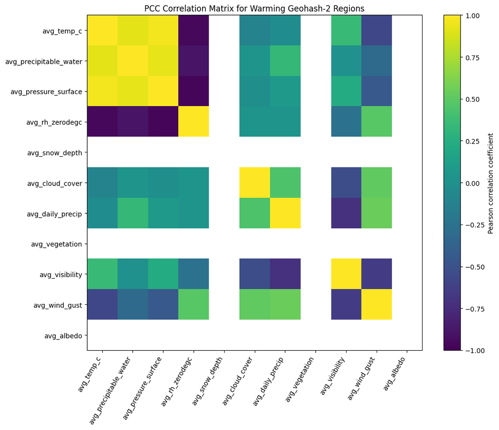

```
Saved correlation heatmap: /bigdata/students/rsbhatia2/plots/climate_change_global_corr.png
Temperature-vs-feature PCC by warming region:
```

|  | geohash2 | n_years | pcc_temp_vs_avg_precipitable_water | pcc_temp_vs_avg_pressure_surface | pcc_temp_vs_avg_rh_zerodegc | pcc_temp_vs_avg_snow_depth | pcc_temp_vs_avg_cloud_cover | pcc_temp_vs_avg_daily_precip | pcc_temp_vs_avg_vegetation | pcc_temp_vs_avg_visibility | pcc_temp_vs_avg_wind_gust | pcc_temp_vs_avg_albedo |
| --- | --- | --- | --- | --- | --- | --- | --- | --- | --- | --- | --- | --- |
| 0 | 8z | 3 | 0.573 | -0.992 | 0.979 | NaN | 0.148 | 0.266 | NaN | 0.417 | -0.993 | NaN |
| 1 | b9 | 3 | -0.664 | 0.742 | -0.265 | NaN | 0.409 | -0.993 | NaN | 1.000 | -0.753 | NaN |
| 2 | b8 | 3 | -0.953 | 0.543 | -0.625 | NaN | -0.716 | -0.981 | NaN | 1.000 | -0.126 | NaN |
| 3 | bb | 3 | -0.401 | 0.306 | -0.615 | NaN | -0.264 | -0.452 | NaN | 0.923 | -0.954 | NaN |
| 4 | bc | 3 | 0.098 | 0.354 | 0.290 | NaN | -0.198 | -0.429 | NaN | 0.057 | -0.880 | NaN |
| 5 | 8x | 3 | -0.359 | -0.099 | -0.726 | NaN | 0.267 | -0.749 | NaN | 0.703 | 0.723 | NaN |

```
How much temp-feature correlations differ by region:
```

|  | correlation | min_pcc | max_pcc | mean_pcc | std_pcc | range_pcc |
| --- | --- | --- | --- | --- | --- | --- |
| 1 | pcc_temp_vs_avg_pressure_surface | -0.992 | 0.742 | 0.142 | 0.622 | 1.734 |
| 6 | pcc_temp_vs_avg_wind_gust | -0.993 | 0.723 | -0.497 | 0.677 | 1.716 |
| 2 | pcc_temp_vs_avg_rh_zerodegc | -0.726 | 0.979 | -0.160 | 0.671 | 1.705 |
| 0 | pcc_temp_vs_avg_precipitable_water | -0.953 | 0.573 | -0.284 | 0.546 | 1.525 |
| 4 | pcc_temp_vs_avg_daily_precip | -0.993 | 0.266 | -0.556 | 0.472 | 1.259 |
| 3 | pcc_temp_vs_avg_cloud_cover | -0.716 | 0.409 | -0.059 | 0.415 | 1.125 |
| 5 | pcc_temp_vs_avg_visibility | 0.057 | 1.000 | 0.683 | 0.380 | 0.943 |

```
Full PCC matrix for warming region 8x:
```

|  | avg_temp_c | avg_precipitable_water | avg_pressure_surface | avg_rh_zerodegc | avg_snow_depth | avg_cloud_cover | avg_daily_precip | avg_vegetation | avg_visibility | avg_wind_gust | avg_albedo |
| --- | --- | --- | --- | --- | --- | --- | --- | --- | --- | --- | --- |
| avg_temp_c | 1.000 | -0.359 | -0.099 | -0.726 | NaN | 0.267 | -0.749 | NaN | 0.703 | 0.723 | NaN |
| avg_precipitable_water | -0.359 | 1.000 | -0.893 | 0.903 | NaN | 0.803 | 0.887 | NaN | -0.916 | -0.904 | NaN |
| avg_pressure_surface | -0.099 | -0.893 | 1.000 | -0.613 | NaN | -0.985 | -0.585 | NaN | 0.638 | 0.615 | NaN |
| avg_rh_zerodegc | -0.726 | 0.903 | -0.613 | 1.000 | NaN | 0.469 | 0.999 | NaN | -0.999 | -1.000 | NaN |
| avg_snow_depth | NaN | NaN | NaN | NaN | NaN | NaN | NaN | NaN | NaN | NaN | NaN |
| avg_cloud_cover | 0.267 | 0.803 | -0.985 | 0.469 | NaN | 1.000 | 0.438 | NaN | -0.497 | -0.472 | NaN |
| avg_daily_precip | -0.749 | 0.887 | -0.585 | 0.999 | NaN | 0.438 | 1.000 | NaN | -0.998 | -0.999 | NaN |
| avg_vegetation | NaN | NaN | NaN | NaN | NaN | NaN | NaN | NaN | NaN | NaN | NaN |
| avg_visibility | 0.703 | -0.916 | 0.638 | -0.999 | NaN | -0.497 | -0.998 | NaN | 1.000 | 1.000 | NaN |
| avg_wind_gust | 0.723 | -0.904 | 0.615 | -1.000 | NaN | -0.472 | -0.999 | NaN | 1.000 | 1.000 | NaN |
| avg_albedo | NaN | NaN | NaN | NaN | NaN | NaN | NaN | NaN | NaN | NaN | NaN |

```
Full PCC matrix for warming region b8:
```

|  | avg_temp_c | avg_precipitable_water | avg_pressure_surface | avg_rh_zerodegc | avg_snow_depth | avg_cloud_cover | avg_daily_precip | avg_vegetation | avg_visibility | avg_wind_gust | avg_albedo |
| --- | --- | --- | --- | --- | --- | --- | --- | --- | --- | --- | --- |
| avg_temp_c | 1.000 | -0.953 | 0.543 | -0.625 | NaN | -0.716 | -0.981 | NaN | 1.000 | -0.126 | NaN |
| avg_precipitable_water | -0.953 | 1.000 | -0.262 | 0.357 | NaN | 0.895 | 0.993 | NaN | -0.958 | 0.422 | NaN |
| avg_pressure_surface | 0.543 | -0.262 | 1.000 | -0.995 | NaN | 0.196 | -0.371 | NaN | 0.527 | 0.764 | NaN |
| avg_rh_zerodegc | -0.625 | 0.357 | -0.995 | 1.000 | NaN | -0.097 | 0.462 | NaN | -0.609 | -0.696 | NaN |
| avg_snow_depth | NaN | NaN | NaN | NaN | NaN | NaN | NaN | NaN | NaN | NaN | NaN |
| avg_cloud_cover | -0.716 | 0.895 | 0.196 | -0.097 | NaN | 1.000 | 0.837 | NaN | -0.730 | 0.782 | NaN |
| avg_daily_precip | -0.981 | 0.993 | -0.371 | 0.462 | NaN | 0.837 | 1.000 | NaN | -0.985 | 0.315 | NaN |
| avg_vegetation | NaN | NaN | NaN | NaN | NaN | NaN | NaN | NaN | NaN | NaN | NaN |
| avg_visibility | 1.000 | -0.958 | 0.527 | -0.609 | NaN | -0.730 | -0.985 | NaN | 1.000 | -0.145 | NaN |
| avg_wind_gust | -0.126 | 0.422 | 0.764 | -0.696 | NaN | 0.782 | 0.315 | NaN | -0.145 | 1.000 | NaN |
| avg_albedo | NaN | NaN | NaN | NaN | NaN | NaN | NaN | NaN | NaN | NaN | NaN |

```
Full PCC matrix for warming region bb:
```

|  | avg_temp_c | avg_precipitable_water | avg_pressure_surface | avg_rh_zerodegc | avg_snow_depth | avg_cloud_cover | avg_daily_precip | avg_vegetation | avg_visibility | avg_wind_gust | avg_albedo |
| --- | --- | --- | --- | --- | --- | --- | --- | --- | --- | --- | --- |
| avg_temp_c | 1.000 | -0.401 | 0.306 | -0.615 | NaN | -0.264 | -0.452 | NaN | 0.923 | -0.954 | NaN |
| avg_precipitable_water | -0.401 | 1.000 | -0.995 | 0.969 | NaN | -0.777 | 0.998 | NaN | -0.723 | 0.659 | NaN |
| avg_pressure_surface | 0.306 | -0.995 | 1.000 | -0.939 | NaN | 0.837 | -0.988 | NaN | 0.649 | -0.579 | NaN |
| avg_rh_zerodegc | -0.615 | 0.969 | -0.939 | 1.000 | NaN | -0.598 | 0.981 | NaN | -0.871 | 0.824 | NaN |
| avg_snow_depth | NaN | NaN | NaN | NaN | NaN | NaN | NaN | NaN | NaN | NaN | NaN |
| avg_cloud_cover | -0.264 | -0.777 | 0.837 | -0.598 | NaN | 1.000 | -0.741 | NaN | 0.127 | -0.039 | NaN |
| avg_daily_precip | -0.452 | 0.998 | -0.988 | 0.981 | NaN | -0.741 | 1.000 | NaN | -0.761 | 0.700 | NaN |
| avg_vegetation | NaN | NaN | NaN | NaN | NaN | NaN | NaN | NaN | NaN | NaN | NaN |
| avg_visibility | 0.923 | -0.723 | 0.649 | -0.871 | NaN | 0.127 | -0.761 | NaN | 1.000 | -0.996 | NaN |
| avg_wind_gust | -0.954 | 0.659 | -0.579 | 0.824 | NaN | -0.039 | 0.700 | NaN | -0.996 | 1.000 | NaN |
| avg_albedo | NaN | NaN | NaN | NaN | NaN | NaN | NaN | NaN | NaN | NaN | NaN |

```
Full PCC matrix for warming region b9:
```

|  | avg_temp_c | avg_precipitable_water | avg_pressure_surface | avg_rh_zerodegc | avg_snow_depth | avg_cloud_cover | avg_daily_precip | avg_vegetation | avg_visibility | avg_wind_gust | avg_albedo |
| --- | --- | --- | --- | --- | --- | --- | --- | --- | --- | --- | --- |
| avg_temp_c | 1.000 | -0.664 | 0.742 | -0.265 | NaN | 0.409 | -0.993 | NaN | 1.000 | -0.753 | NaN |
| avg_precipitable_water | -0.664 | 1.000 | -0.994 | 0.897 | NaN | -0.954 | 0.574 | NaN | -0.673 | 0.992 | NaN |
| avg_pressure_surface | 0.742 | -0.994 | 1.000 | -0.843 | NaN | 0.915 | -0.660 | NaN | 0.750 | -1.000 | NaN |
| avg_rh_zerodegc | -0.265 | 0.897 | -0.843 | 1.000 | NaN | -0.988 | 0.152 | NaN | -0.276 | 0.834 | NaN |
| avg_snow_depth | NaN | NaN | NaN | NaN | NaN | NaN | NaN | NaN | NaN | NaN | NaN |
| avg_cloud_cover | 0.409 | -0.954 | 0.915 | -0.988 | NaN | 1.000 | -0.301 | NaN | 0.419 | -0.909 | NaN |
| avg_daily_precip | -0.993 | 0.574 | -0.660 | 0.152 | NaN | -0.301 | 1.000 | NaN | -0.992 | 0.672 | NaN |
| avg_vegetation | NaN | NaN | NaN | NaN | NaN | NaN | NaN | NaN | NaN | NaN | NaN |
| avg_visibility | 1.000 | -0.673 | 0.750 | -0.276 | NaN | 0.419 | -0.992 | NaN | 1.000 | -0.760 | NaN |
| avg_wind_gust | -0.753 | 0.992 | -1.000 | 0.834 | NaN | -0.909 | 0.672 | NaN | -0.760 | 1.000 | NaN |
| avg_albedo | NaN | NaN | NaN | NaN | NaN | NaN | NaN | NaN | NaN | NaN | NaN |

```
Full PCC matrix for warming region 8z:
```

|  | avg_temp_c | avg_precipitable_water | avg_pressure_surface | avg_rh_zerodegc | avg_snow_depth | avg_cloud_cover | avg_daily_precip | avg_vegetation | avg_visibility | avg_wind_gust | avg_albedo |
| --- | --- | --- | --- | --- | --- | --- | --- | --- | --- | --- | --- |
| avg_temp_c | 1.000 | 0.573 | -0.992 | 0.979 | NaN | 0.148 | 0.266 | NaN | 0.417 | -0.993 | NaN |
| avg_precipitable_water | 0.573 | 1.000 | -0.464 | 0.395 | NaN | -0.726 | 0.942 | NaN | -0.507 | -0.472 | NaN |
| avg_pressure_surface | -0.992 | -0.464 | 1.000 | -0.997 | NaN | -0.272 | -0.141 | NaN | -0.529 | 1.000 | NaN |
| avg_rh_zerodegc | 0.979 | 0.395 | -0.997 | 1.000 | NaN | 0.345 | 0.065 | NaN | 0.592 | -0.996 | NaN |
| avg_snow_depth | NaN | NaN | NaN | NaN | NaN | NaN | NaN | NaN | NaN | NaN | NaN |
| avg_cloud_cover | 0.148 | -0.726 | -0.272 | 0.345 | NaN | 1.000 | -0.914 | NaN | 0.961 | -0.264 | NaN |
| avg_daily_precip | 0.266 | 0.942 | -0.141 | 0.065 | NaN | -0.914 | 1.000 | NaN | -0.766 | -0.150 | NaN |
| avg_vegetation | NaN | NaN | NaN | NaN | NaN | NaN | NaN | NaN | NaN | NaN | NaN |
| avg_visibility | 0.417 | -0.507 | -0.529 | 0.592 | NaN | 0.961 | -0.766 | NaN | 1.000 | -0.521 | NaN |
| avg_wind_gust | -0.993 | -0.472 | 1.000 | -0.996 | NaN | -0.264 | -0.150 | NaN | -0.521 | 1.000 | NaN |
| avg_albedo | NaN | NaN | NaN | NaN | NaN | NaN | NaN | NaN | NaN | NaN | NaN |

```
Saved warming regions: /bigdata/students/rsbhatia2/plots/climate_change_warming_regions.csv
Saved regional temp correlations: /bigdata/students/rsbhatia2/plots/climate_change_regional_temp_correlations.csv
```

```python
    plot_dir = f"/bigdata/students/{os.environ['USER']}/plots"
    os.makedirs(plot_dir, exist_ok=True)

    corr_path = f"{plot_dir}/climate_change_global_corr.png"
    plt.savefig(corr_path, dpi=150, bbox_inches="tight")
    plt.show()

    print("Saved correlation heatmap:", corr_path)

# ============================================================
# Do correlations between temperature and other features differ across warming regions?
# ============================================================

regional_corr_exprs = []

for feature in feature_cols:
    if feature == "avg_temp_c":
        continue

    regional_corr_exprs.append(
        F.corr("avg_temp_c", feature).alias(f"pcc_temp_vs_{feature}")
    )

regional_temp_corrs = (
    warming_yearly
    .groupBy("geohash2")
    .agg(
        F.countDistinct("year").alias("n_years"),
        *regional_corr_exprs,
    )
    .filter(F.col("n_years") >= MIN_YEARS_FOR_TREND)
)

print("Temperature-vs-feature PCC by warming region:")
regional_temp_corrs_pdf = regional_temp_corrs.toPandas()
display(regional_temp_corrs_pdf.round(3))

# ============================================================
# Compare variation in correlations across regions
# ============================================================

corr_value_cols = [
    c for c in regional_temp_corrs_pdf.columns
    if c.startswith("pcc_temp_vs_")
]

if len(regional_temp_corrs_pdf) > 0:
    corr_variation = []

    for col in corr_value_cols:
        series = regional_temp_corrs_pdf[col].dropna()

        if len(series) > 0:
            corr_variation.append({
                "correlation": col,
                "min_pcc": series.min(),
                "max_pcc": series.max(),
                "mean_pcc": series.mean(),
                "std_pcc": series.std(),
                "range_pcc": series.max() - series.min(),
            })

    corr_variation_pdf = pd.DataFrame(corr_variation).sort_values(
        "range_pcc",
        ascending=False,
    )

    print("How much temp-feature correlations differ by region:")
    display(corr_variation_pdf.round(3))


top_warming_geohashes = [
    row["geohash2"]
    for row in warming_regions
        .select("geohash2")
        .limit(5)
        .collect()
]

for gh in top_warming_geohashes:
    region_pdf = warming_pdf[warming_pdf["geohash2"] == gh].copy()

    if len(region_pdf) < MIN_YEARS_FOR_TREND:
        continue

    region_corr = region_pdf[feature_cols].corr(method="pearson")

    print(f"Full PCC matrix for warming region {gh}:")
    display(region_corr.round(3))

# ============================================================
# SAVE TABLES
# ============================================================

# NOTE: Matthew, change this if you want to run stuff. idk you are allowed you to save things in my dir?
plot_dir = f"/bigdata/students/{os.environ['USER']}/plots"
os.makedirs(plot_dir, exist_ok=True)

warming_csv = f"{plot_dir}/climate_change_warming_regions.csv"
regional_corr_csv = f"{plot_dir}/climate_change_regional_temp_correlations.csv"

warming_regions.toPandas().to_csv(warming_csv, index=False)
regional_temp_corrs_pdf.to_csv(regional_corr_csv, index=False)

print("Saved warming regions:", warming_csv)
print("Saved regional temp correlations:", regional_corr_csv)
```

## Weather Station

Data selection is through the server. Here is how I ran the server for this:

`python server.py --input-glob "hdfs:///3hr/2019/*_20*{08}*_*" --host 0.0.0.0 --port 28420 --threads 3 --max-files 1500 --hold-open-after-done --file-stride 4`

```python
from collections import defaultdict, deque
import math
import os
import socket
import subprocess
import time


import matplotlib.pyplot as plt
from IPython.display import clear_output, display
from pyspark.streaming import StreamingContext

sc = spark.sparkContext

# ============================================================
# CONFIG
# ============================================================

WEATHER_HOST = "mc08"
WEATHER_PORT = 28420
WEATHER_BATCH_INTERVAL_SECONDS = 5
WEATHER_HISTORY_LIMIT = 500
WEATHER_SAVE_FRAMES = True
WEATHER_FRAME_DIR = f"/bigdata/students/rsbhatia2/weather_station_frames"
WEATHER_VIDEO_OUT = f"/bigdata/students/rsbhatia2/weather_station.mp4"
WEATHER_VIDEO_FPS = 2
WEATHER_CHECKPOINT_DIR = f"hdfs:///user/{sc.sparkUser()}/weather_station_streaming_checkpoint"

TIME_IDX = 0
LAT_IDX = 1
LON_IDX = 2
PRESSURE_SURFACE_IDX = 6
HUMIDITY_IDX = 8
TEMP_SURFACE_IDX = 10
PRECIP_3HR_IDX = 13
VISIBILITY_IDX = 15
WIND_GUST_IDX = 17

WEATHER_LOCATIONS = [
    {
        "name": "San Francisco Bay Area",
        "lat_min": 37.2,
        "lat_max": 38.2,
        "lon_min": -122.8,
        "lon_max": -121.7,
    },
    {
        "name": "Los Angeles Coast",
        "lat_min": 33.5,
        "lat_max": 34.4,
        "lon_min": -118.8,
        "lon_max": -117.7,
    },
    {
        "name": "Seattle / Puget Sound",
        "lat_min": 47.2,
        "lat_max": 47.9,
        "lon_min": -122.7,
        "lon_max": -121.9,
    },
    {
        "name": "Chicago",
        "lat_min": 41.5,
        "lat_max": 42.2,
        "lon_min": -88.1,
        "lon_max": -87.3,
    },
    {
        "name": "Miami",
        "lat_min": 25.5,
        "lat_max": 26.1,
        "lon_min": -80.5,
        "lon_max": -80.0,
    },
]

WEATHER_METRICS = [
    ("temp_c", "Temp C"),
    ("pressure_hpa", "Pressure hPa"),
    ("humidity_pct", "Humidity %"),
    ("precip", "Precip"),
    ("visibility_km", "Visibility km"),
    ("wind_gust", "Wind Gust"),
]

WEATHER_STREAMING_CONTEXT = None
WEATHER_HISTORY = {
    location["name"]: {metric_key: deque(maxlen=WEATHER_HISTORY_LIMIT) for metric_key, _ in WEATHER_METRICS}
    for location in WEATHER_LOCATIONS
}
WEATHER_BATCH_LABELS = deque(maxlen=WEATHER_HISTORY_LIMIT)
WEATHER_FRAME_COUNT = 0
WEATHER_STOP_REQUESTED = False

# ============================================================
# PARSING AND AGGREGATION
# ============================================================

def weather_safe_float(parts, idx):
    if idx is None or idx >= len(parts):
        return None

    value = parts[idx].strip()
    if value == "" or value.lower() == "null":
        return None

    return float(value)


def weather_location_for(lat, lon):
    for location in WEATHER_LOCATIONS:
        if (
            location["lat_min"] <= lat <= location["lat_max"]
            and location["lon_min"] <= lon <= location["lon_max"]
        ):
            return location["name"]

    return None


def empty_weather_summary():
    return (0,) + tuple(0.0 for _ in range(len(WEATHER_METRICS) * 2))


def metric_pair(value):
    if value is None:
        return (0.0, 0.0)

    try:
        value = float(value)
    except Exception:
        return (0.0, 0.0)

    if not math.isfinite(value):
        return (0.0, 0.0)

    return (value, 1.0)


def extract_weather_values(parts):
    temp_k = weather_safe_float(parts, TEMP_SURFACE_IDX)
    pressure_pa = weather_safe_float(parts, PRESSURE_SURFACE_IDX)
    humidity_pct = weather_safe_float(parts, HUMIDITY_IDX)
    precip = weather_safe_float(parts, PRECIP_3HR_IDX)
    visibility_m = weather_safe_float(parts, VISIBILITY_IDX)
    wind_gust = weather_safe_float(parts, WIND_GUST_IDX)

    return [
        temp_k - 273.15 if temp_k is not None else None,
        pressure_pa / 100.0 if pressure_pa is not None else None,
        humidity_pct,
        precip,
        visibility_m / 1000.0 if visibility_m is not None else None,
        wind_gust,
    ]


def parse_weather_station_line(line):
    try:
        if not line or line.startswith("1_time"):
            return None

        parts = line.rstrip("\t").split("\t")

        lat = weather_safe_float(parts, LAT_IDX)
        lon = weather_safe_float(parts, LON_IDX)
        if lat is None or lon is None:
            return None

        location_name = weather_location_for(lat, lon)
        if location_name is None:
            return None

        metric_values = extract_weather_values(parts)
        metric_pairs = [metric_pair(value) for value in metric_values]

        if not any(count > 0 for _, count in metric_pairs):
            return None

        flattened = []
        for metric_sum, metric_count in metric_pairs:
            flattened.extend([metric_sum, metric_count])

        return (location_name, (1,) + tuple(flattened))

    except Exception:
        return None


def classify_weather_station_line(line):
    counts = [("raw_lines", 1)]

    try:
        if not line or line.startswith("1_time"):
            return counts

        parts = line.rstrip("\t").split("\t")

        lat = weather_safe_float(parts, LAT_IDX)
        lon = weather_safe_float(parts, LON_IDX)
        if lat is None or lon is None:
            return counts

        counts.append(("valid_latlon", 1))

        if weather_location_for(lat, lon) is None:
            return counts

        counts.append(("selected_location", 1))

        metric_values = extract_weather_values(parts)
        if any(metric_pair(value)[1] > 0 for value in metric_values):
            counts.append(("usable_metric", 1))

        return counts

    except Exception:
        counts.append(("parse_errors", 1))
        return counts


def combine_weather_summaries(left, right):
    return tuple(left[i] + right[i] for i in range(len(left)))


def update_weather_state(new_values, current_state):
    if current_state is None:
        current_state = empty_weather_summary()

    total = current_state
    for value in new_values:
        total = combine_weather_summaries(total, value)
```

```python
    return total


def weather_state_to_means(state):
    means = {}

    for idx, (metric_key, _) in enumerate(WEATHER_METRICS):
        pair_start = 1 + idx * 2
        metric_sum = state[pair_start]
        metric_count = state[pair_start + 1]
        means[metric_key] = metric_sum / metric_count if metric_count > 0 else None

    return means


# ============================================================
# VISUALIZATION
# ============================================================

def update_weather_history(timestamp, rows):
    batch_label = timestamp.strftime("%H:%M:%S") if hasattr(timestamp, "strftime") else str(timestamp)
    WEATHER_BATCH_LABELS.append(batch_label)

    row_by_location = dict(rows)
    for location in WEATHER_LOCATIONS:
        location_name = location["name"]
        means = weather_state_to_means(row_by_location[location_name]) if location_name in row_by_location else None

        for metric_key, _ in WEATHER_METRICS:
            value = means[metric_key] if means is not None else None
            WEATHER_HISTORY[location_name][metric_key].append(value)


def draw_weather_dashboard():
    global WEATHER_FRAME_COUNT

    fig, axes = plt.subplots(
        nrows=len(WEATHER_METRICS),
        ncols=len(WEATHER_LOCATIONS),
        figsize=(18, 12),
        sharex=True,
    )

    x_values = list(range(len(WEATHER_BATCH_LABELS)))

    for row_idx, (metric_key, metric_label) in enumerate(WEATHER_METRICS):
        for col_idx, location in enumerate(WEATHER_LOCATIONS):
            ax = axes[row_idx][col_idx]
            location_name = location["name"]
            y_values = list(WEATHER_HISTORY[location_name][metric_key])

            ax.plot(x_values[-len(y_values):], y_values, marker="o", linewidth=1.5, markersize=3)
            ax.grid(True, alpha=0.25)

            if row_idx == 0:
                ax.set_title(location_name, fontsize=10)
            if col_idx == 0:
                ax.set_ylabel(metric_label, fontsize=9)
            if row_idx == len(WEATHER_METRICS) - 1:
                ax.set_xlabel("Batch", fontsize=9)

    fig.suptitle("Weather Station Online Summary", fontsize=16)
    fig.tight_layout(rect=[0, 0, 1, 0.97])

    if WEATHER_SAVE_FRAMES:
        os.makedirs(WEATHER_FRAME_DIR, exist_ok=True)
        frame_path = os.path.join(WEATHER_FRAME_DIR, f"weather_station_{WEATHER_FRAME_COUNT:05d}.png")
        fig.savefig(frame_path, dpi=120, bbox_inches="tight")
        WEATHER_FRAME_COUNT += 1

    clear_output(wait=True)
    display(fig)
    plt.close(fig)


def handle_weather_batch(timestamp, rdd):
    if WEATHER_STOP_REQUESTED:
        return

    rows = rdd.collect()
    update_weather_history(timestamp, rows)
    draw_weather_dashboard()

    total_records = sum(row[1][0] for row in rows)
    print(f"Batch: {timestamp} | Online locations: {len(rows)} | Location rows summarized: {total_records}")


def handle_weather_debug_batch(timestamp, rdd):
    if WEATHER_STOP_REQUESTED:
        return

    counts = dict(rdd.collect()) if not rdd.isEmpty() else {}
    print(
        "Debug counts | "
        f"Batch: {timestamp} | "
        f"raw lines: {counts.get('raw_lines', 0)} | "
        f"valid lat/lon: {counts.get('valid_latlon', 0)} | "
        f"selected location: {counts.get('selected_location', 0)} | "
        f"usable metric: {counts.get('usable_metric', 0)} | "
        f"parse errors: {counts.get('parse_errors', 0)}"
    )


# ============================================================
# STREAM CONTROLS
# ============================================================

def build_weather_streaming_context():
    ssc = StreamingContext(sc, WEATHER_BATCH_INTERVAL_SECONDS)
    ssc.checkpoint(WEATHER_CHECKPOINT_DIR)

    lines = ssc.socketTextStream(WEATHER_HOST, WEATHER_PORT)

    debug_counts = lines.flatMap(classify_weather_station_line).reduceByKey(lambda left, right: left + right)
    debug_counts.foreachRDD(handle_weather_debug_batch)

    parsed = lines.map(parse_weather_station_line).filter(lambda row: row is not None)
    batch_summaries = parsed.reduceByKey(combine_weather_summaries)
    online_summaries = batch_summaries.updateStateByKey(update_weather_state)
    online_summaries.foreachRDD(handle_weather_batch)

    return ssc


def weather_server_is_listening(timeout_seconds=2.0):
    try:
        with socket.create_connection((WEATHER_HOST, WEATHER_PORT), timeout=timeout_seconds):
            return True
    except OSError as exc:
        print(f"Could not connect to {WEATHER_HOST}:{WEATHER_PORT}: {exc}")
        print("Start server.py first and wait until it prints the Listening message.")
        return False


def start_weather_station():
    global WEATHER_STREAMING_CONTEXT, WEATHER_STOP_REQUESTED

    WEATHER_STOP_REQUESTED = False

    if WEATHER_SAVE_FRAMES:
        os.makedirs(WEATHER_FRAME_DIR, exist_ok=True)
        print(f"Saving dashboard frames to: {WEATHER_FRAME_DIR}")

    if WEATHER_STREAMING_CONTEXT is not None:
        print("Weather station stream is already running. Call stop_weather_station() first if needed.")
        return WEATHER_STREAMING_CONTEXT

    print(f"Connecting Spark Streaming to {WEATHER_HOST}:{WEATHER_PORT}")
    print("Start server.py first, then call stop_weather_station() when the demo is done.")

    if not weather_server_is_listening():
        print("Spark Streaming was not started.")
        return None

    WEATHER_STREAMING_CONTEXT = build_weather_streaming_context()
    WEATHER_STREAMING_CONTEXT.start()
    return WEATHER_STREAMING_CONTEXT


def run_weather_station():
    return start_weather_station()


def stop_weather_station():
    global WEATHER_STREAMING_CONTEXT, WEATHER_STOP_REQUESTED

    WEATHER_STOP_REQUESTED = True

    if WEATHER_STREAMING_CONTEXT is None:
        print("Weather station stream is not running.")
        return

    WEATHER_STREAMING_CONTEXT.stop(stopSparkContext=False, stopGraceFully=False)
    WEATHER_STREAMING_CONTEXT = None
    print("Weather station stream stopped.")
```

```python
def reset_weather_station_frames():
    global WEATHER_FRAME_COUNT, WEATHER_STOP_REQUESTED

    os.makedirs(WEATHER_FRAME_DIR, exist_ok=True)
    for filename in os.listdir(WEATHER_FRAME_DIR):
        if filename.startswith("weather_station_") and filename.endswith(".png"):
            os.remove(os.path.join(WEATHER_FRAME_DIR, filename))

    WEATHER_FRAME_COUNT = 0
    WEATHER_STOP_REQUESTED = False
    print(f"Cleared weather station frames from: {WEATHER_FRAME_DIR}")

print("Weather Station code loaded.")
print("Remote test server command is in the comments at the top of this cell.")
print("Frames save automatically while the dashboard updates.")
print("Run stop_weather_station() when the video has enough dashboard updates.")
```

```
Weather Station code loaded.
Remote test server command is in the comments at the top of this cell.
Frames save automatically while the dashboard updates.
Run stop_weather_station() when the video has enough dashboard updates.
```

```python
reset_weather_station_frames()
```

```
Cleared weather station frames from: /bigdata/students/rsbhatia2/weather_station_frames
```

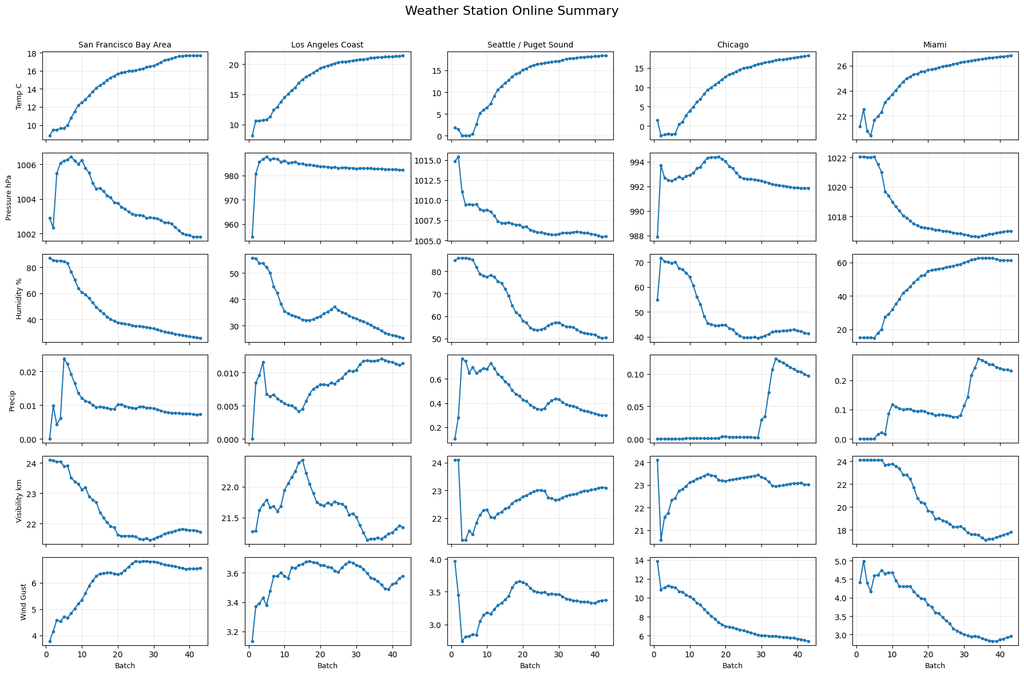

```
[Stage 2424:>                                                       (0 + 1) / 1]
```

```python
weather_station_streaming_runtime_start = time.perf_counter()
run_weather_station()
```

```python
stop_weather_station()

weather_station_streaming_runtime = time.perf_counter() - weather_station_streaming_runtime_start
print(f"Total Weather Station streaming runtime: {weather_station_streaming_runtime:.2f} seconds")
```

[output not shown]

```
Weather station stream stopped.
Total Weather Station streaming runtime: 420.03 seconds
```

You can find the video in the repository. It is called `weather_station.mp4`

## Prediction/Classification

### Fog Classification With MLlib

This extends the least-foggy Bay Area analysis with a logistic regression classifier. The model predicts whether an individual Bay Area weather observation is `foggy` or `clear`.

The label is built from `visibility_surface`: observations with visibility at or below `10000` meters are labeled foggy, observations with visibility at or above `18000` meters are labeled clear, and middle-visibility observations are dropped. Visibility is intentionally not used as a training feature so the model does not simply learn the label rule.

This improves the least-foggy analysis by checking whether weather variables other than visibility can distinguish foggy from clear Bay Area conditions. If the model performs well, the hand-built clarity ranking is supported by a learned classifier; if it performs poorly, that suggests visibility is doing most of the work and the score should be interpreted more cautiously.

```python
from pyspark.sql import functions as F
from pyspark.sql.types import StructType, StructField, LongType, DoubleType
from pyspark.ml import Pipeline
from pyspark.ml.classification import LogisticRegression
from pyspark.ml.evaluation import BinaryClassificationEvaluator, MulticlassClassificationEvaluator
from pyspark.ml.feature import StandardScaler, VectorAssembler
import time

from SparkHandler import Sparky, SparkyBatchContext, SparkyAnalysisContext
import util

sc = spark.sparkContext
fog_classification_runtime_start = time.perf_counter()

# ============================================================
# CONFIG
# ============================================================

FOG_CLASSIFICATION_INPUT_GLOB = "hdfs:///3hr/*/*_20*{05,06,07,08,09}*_*"
FOG_CLASSIFICATION_BATCH_SIZE = 50
FOG_CLASSIFICATION_PARTIAL_OUT = f"hdfs:///user/{sc.sparkUser()}/fog_classification_partials"

# Bay Area bounding box, same as least foggy cause this is directly comparing to that.
FOG_LAT_MIN = 36.8
FOG_LAT_MAX = 38.9
FOG_LON_MIN = -123.2
FOG_LON_MAX = -121.4

FOG_MONTHS = [5, 6, 7, 8, 9]
FOGGY_VISIBILITY_MAX = 10000.0
CLEAR_VISIBILITY_MIN = 18000.0

FOG_FEATURE_COLS = [
    "cloud",
    "temp_c",
    "rh",
    "pressure",
    "wind",
    "month",
    "hour",
    "lat",
    "lon",
]

fog_raw_schema = StructType([
    StructField("time_ms", LongType(), False),
    StructField("lat", DoubleType(), False),
    StructField("lon", DoubleType(), False),
    StructField("cloud", DoubleType(), False),
    StructField("temp_k", DoubleType(), False),
    StructField("rh", DoubleType(), False),
    StructField("pressure", DoubleType(), False),
    StructField("wind", DoubleType(), False),
    StructField("visibility", DoubleType(), False),
])

fog_time_idx = None
fog_lat_idx = None
fog_lon_idx = None
fog_cloud_idx = None
fog_temp_idx = None
fog_rh_idx = None
fog_pressure_idx = None
fog_wind_idx = None
fog_visibility_idx = None
```

```python
def parse_fog_classification_line(line):
    try:
        if line.startswith("1_time"):
            return None

        parts = line.rstrip("\t").split("\t")

        time_ms = util.safe_float(parts, fog_time_idx)
        lat = util.safe_float(parts, fog_lat_idx)
        lon = util.safe_float(parts, fog_lon_idx)

        if time_ms is None or lat is None or lon is None:
            return None

        if not (FOG_LAT_MIN <= lat <= FOG_LAT_MAX and FOG_LON_MIN <= lon <= FOG_LON_MAX):
            return None

        cloud = util.safe_float(parts, fog_cloud_idx)
        temp_k = util.safe_float(parts, fog_temp_idx)
        rh = util.safe_float(parts, fog_rh_idx)
        pressure = util.safe_float(parts, fog_pressure_idx)
        wind = util.safe_float(parts, fog_wind_idx)
        visibility = util.safe_float(parts, fog_visibility_idx)

        if any(value is None for value in [cloud, temp_k, rh, pressure, wind, visibility]):
            return None

        return (
            int(time_ms),
            lat,
            lon,
            cloud,
            temp_k,
            rh,
            pressure,
            wind,
            visibility,
        )

    except Exception:
        return None


def fog_classification_partial_transform(points):
    labeled = (
        points
        .withColumn(
            "timestamp",
            F.from_unixtime((F.col("time_ms") / 1000).cast("long")).cast("timestamp")
        )
        .withColumn("year", F.year("timestamp"))
        .withColumn("month", F.month("timestamp"))
        .withColumn("hour", F.hour("timestamp"))
        .filter(F.col("month").isin(FOG_MONTHS))
        .withColumn("temp_c", F.col("temp_k") - F.lit(273.15))
        .withColumn(
            "label",
            F.when(F.col("visibility") <= F.lit(FOGGY_VISIBILITY_MAX), F.lit(1.0))
             .when(F.col("visibility") >= F.lit(CLEAR_VISIBILITY_MIN), F.lit(0.0))
        )
        .filter(F.col("label").isNotNull())
    )

    return labeled.select(
        "year",
        "month",
        "hour",
        "lat",
        "lon",
        "cloud",
        "temp_c",
        "rh",
        "pressure",
        "wind",
        "label",
    )


def combine_fog_classification_partials(partials):
    return partials


def analyze_fog_classification_rows(rows):
    return rows
```

```python
fog_sparky = Sparky(spark, sc)

fog_batch_ctx = SparkyBatchContext(
    glob_path=FOG_CLASSIFICATION_INPUT_GLOB,
    partial_out=FOG_CLASSIFICATION_PARTIAL_OUT,
    schema=fog_raw_schema,
    parse_line=parse_fog_classification_line,
    partial_transform=fog_classification_partial_transform,
    batch_size=FOG_CLASSIFICATION_BATCH_SIZE,
)

fog_input_paths = fog_sparky.setup_job(fog_batch_ctx)

if len(fog_input_paths) == 0:
    raise ValueError(f"No files matched: {FOG_CLASSIFICATION_INPUT_GLOB}")


def fog_required_idx(name):
    key = name.strip().lower()
    if key not in fog_sparky.columns:
        raise ValueError(f"Missing required column: {name}")
    return fog_sparky.columns[key]

fog_time_idx = fog_required_idx("time")
fog_lat_idx = fog_required_idx("lat")
fog_lon_idx = fog_required_idx("lon")
fog_cloud_idx = fog_required_idx("total_cloud_cover_entire_atmosphere_single_layer")
fog_temp_idx = fog_required_idx("temperature_surface")
fog_rh_idx = fog_required_idx("relative_humidity_zerodegc_isotherm")
fog_pressure_idx = fog_required_idx("pressure_surface")
fog_wind_idx = fog_required_idx("wind_speed_gust_surface")
fog_visibility_idx = fog_required_idx("visibility_surface")

print("Using column indices:")
print("time:", fog_time_idx)
print("lat:", fog_lat_idx)
print("lon:", fog_lon_idx)
print("cloud cover:", fog_cloud_idx)
print("temperature:", fog_temp_idx)
print("relative humidity:", fog_rh_idx)
print("pressure:", fog_pressure_idx)
print("wind gust:", fog_wind_idx)
print("visibility:", fog_visibility_idx)
print("visibility is used only for labels, not model features")

for batch_id, start in enumerate(range(0, len(fog_input_paths), fog_batch_ctx.batch_size)):
    batch_paths = fog_input_paths[start:start + fog_batch_ctx.batch_size]
    fog_sparky.process_batch(fog_batch_ctx, batch_paths, batch_id)
```

```
Deleted old partial output: hdfs:/user/rsbhatia2/fog_classification_partials
Found 4381 files
```

```
Using column indices:
time: 0
lat: 1
lon: 2
cloud cover: 12
temperature: 10
relative humidity: 8
pressure: 6
wind gust: 17
visibility: 15
visibility is used only for labels, not model features
Processing batch 0: 50 files
```

```
Processing batch 1: 50 files
```

```
Processing batch 2: 50 files
```

```
Processing batch 3: 50 files
```

```
Processing batch 4: 50 files
```

```
Processing batch 5: 50 files
```

```
Processing batch 6: 50 files
```

```
Processing batch 7: 50 files
```

```
Processing batch 8: 50 files
```

```
Processing batch 9: 50 files
```

```
Processing batch 10: 50 files
```

```
Processing batch 11: 50 files
```

```
Processing batch 12: 50 files
```

```
Processing batch 13: 50 files
```

```
Processing batch 14: 50 files
```

```
Processing batch 15: 50 files
```

```
Processing batch 16: 50 files
```

```
Processing batch 17: 50 files
```

```
Processing batch 18: 50 files
```

```
Processing batch 19: 50 files
```

```
Processing batch 20: 50 files
```

```
Processing batch 21: 50 files
```

```
Processing batch 22: 50 files
```

```
Processing batch 23: 50 files
```

```
Processing batch 24: 50 files
```

```
Processing batch 25: 50 files
```

```
Processing batch 26: 50 files
```

```
Processing batch 27: 50 files
```

```
Processing batch 28: 50 files
```

```
Processing batch 29: 50 files
```

```
Processing batch 30: 50 files
```

```
Processing batch 31: 50 files
```

```
Processing batch 32: 50 files
```

```
Processing batch 33: 50 files
```

```
Processing batch 34: 50 files
```

```
Processing batch 35: 50 files
```

```
Processing batch 36: 50 files
```

```
Processing batch 37: 50 files
```

```
Processing batch 38: 50 files
```

```
Processing batch 39: 50 files
```

```
Processing batch 40: 50 files
```

```
Processing batch 41: 50 files
```

```
Processing batch 42: 50 files
```

```
Processing batch 43: 50 files
```

```
Processing batch 44: 50 files
```

```
Processing batch 45: 50 files
```

```
Processing batch 46: 50 files
```

```
Processing batch 47: 50 files
```

```
Processing batch 48: 50 files
```

```
Processing batch 49: 50 files
```

```
Processing batch 50: 50 files
```

```
Processing batch 51: 50 files
```

```
Processing batch 52: 50 files
```

```
Processing batch 53: 50 files
```

```
Processing batch 54: 50 files
```

```
Processing batch 55: 50 files
```

```
Processing batch 56: 50 files
```

```
Processing batch 57: 50 files
```

```
Processing batch 58: 50 files
```

```
Processing batch 59: 50 files
```

```
Processing batch 60: 50 files
```

```
Processing batch 61: 50 files
```

```
Processing batch 62: 50 files
```

```
Processing batch 63: 50 files
```

```
Processing batch 64: 50 files
```

```
Processing batch 65: 50 files
```

```
Processing batch 66: 50 files
```

```
Processing batch 67: 50 files
```

```
Processing batch 68: 50 files
```

```
Processing batch 69: 50 files
```

```
Processing batch 70: 50 files
```

```
Processing batch 71: 50 files
```

```
Processing batch 72: 50 files
```

```
Processing batch 73: 50 files
```

```
Processing batch 74: 50 files
```

```
Processing batch 75: 50 files
```

```
Processing batch 76: 50 files
```

```
Processing batch 77: 50 files
```

```
Processing batch 78: 50 files
```

```
Processing batch 79: 50 files
```

```
Processing batch 80: 50 files
```

```
Processing batch 81: 50 files
```

```
Processing batch 82: 50 files
```

```
Processing batch 83: 50 files
```

```
Processing batch 84: 50 files
```

```
Processing batch 85: 50 files
```

```
Processing batch 86: 50 files
```

```
Processing batch 87: 31 files
```

```python
fog_analysis_ctx = SparkyAnalysisContext(
    partial_in=FOG_CLASSIFICATION_PARTIAL_OUT,
    combine_partials=combine_fog_classification_partials,
    analyze=analyze_fog_classification_rows,
    result_out=None,
)

fog_rows = fog_sparky.analyze(fog_analysis_ctx, fog_sparky.combine(fog_analysis_ctx)).cache()

train = fog_rows.filter(F.col("year").between(2015, 2018)).cache()
test = fog_rows.filter(F.col("year") == 2019).cache()

print("Training label counts:")
train.groupBy("label").count().orderBy("label").show()

print("Test label counts:")
test.groupBy("label").count().orderBy("label").show()

train_label_count = train.select("label").distinct().count()
test_label_count = test.select("label").distinct().count()

if train_label_count < 2:
    raise ValueError("Training set does not contain both foggy and clear labels.")

if test_label_count < 2:
    raise ValueError("Test set does not contain both foggy and clear labels.")

print("Model feature columns:", FOG_FEATURE_COLS)
print("visibility_surface excluded from features:", "visibility" not in FOG_FEATURE_COLS)

assembler = VectorAssembler(
    inputCols=FOG_FEATURE_COLS,
    outputCol="features",
    handleInvalid="skip",
)

scaler = StandardScaler(
    inputCol="features",
    outputCol="scaled_features",
    withStd=True,
    withMean=True,
)

lr = LogisticRegression(
    labelCol="label",
    featuresCol="scaled_features",
    maxIter=50,
    regParam=0.01,
    elasticNetParam=0.0,
)

fog_pipeline = Pipeline(stages=[assembler, scaler, lr])
fog_model = fog_pipeline.fit(train)
fog_predictions = fog_model.transform(test).cache()

print("Prediction rows:", fog_predictions.count())
```

```
Training label counts:
```

```
+-----+------+
|label| count|
+-----+------+
|  0.0|271661|
|  1.0| 33021|
+-----+------+

Test label counts:
+-----+------+
|label| count|
+-----+------+
|  0.0|131402|
|  1.0| 17243|
+-----+------+

Model feature columns: ['cloud', 'temp_c', 'rh', 'pressure', 'wind', 'month', 'hour', 'lat', 'lon']
visibility_surface excluded from features: True
```

```
[Stage 1638:====================================================> (57 + 2) / 59]
```

```
Prediction rows: 148645
```

```python
lr_model = fog_model.stages[-1]

coefficient_rows = [
    (feature, float(coef))
    for feature, coef in zip(FOG_FEATURE_COLS, lr_model.coefficients)
]

coefficient_df = spark.createDataFrame(coefficient_rows, ["feature", "coefficient"])
print("Logistic regression coefficients:")
coefficient_df.orderBy(F.desc(F.abs(F.col("coefficient")))).show(truncate=False)

print("Confusion matrix: rows are actual labels, columns are predictions")
(
    fog_predictions
    .groupBy("label")
    .pivot("prediction", [0.0, 1.0])
    .count()
    .na.fill(0)
    .orderBy("label")
    .show()
)

accuracy = MulticlassClassificationEvaluator(
    labelCol="label",
    predictionCol="prediction",
    metricName="accuracy",
).evaluate(fog_predictions)

weighted_f1 = MulticlassClassificationEvaluator(
    labelCol="label",
    predictionCol="prediction",
    metricName="f1",
).evaluate(fog_predictions)

area_under_roc = BinaryClassificationEvaluator(
    labelCol="label",
    rawPredictionCol="rawPrediction",
    metricName="areaUnderROC",
).evaluate(fog_predictions)

print(f"Accuracy: {accuracy:.4f}")
print(f"Weighted F1: {weighted_f1:.4f}")
print(f"Area under ROC: {area_under_roc:.4f}")

print("Example predictions:")
(
    fog_predictions
    .select(
        "year",
        "month",
        "hour",
        "lat",
        "lon",
        "label",
        "prediction",
        "probability",
        "cloud",
        "temp_c",
        "rh",
        "pressure",
        "wind",
    )
    .orderBy("year", "month", "hour")
    .show(20, truncate=False)
)

fog_classification_runtime = time.perf_counter() - fog_classification_runtime_start
print(f"Total Prediction/Classification Spark runtime: {fog_classification_runtime:.2f} seconds")
```

```
Logistic regression coefficients:
```

```
+--------+--------------------+
|feature |coefficient         |
+--------+--------------------+
|cloud   |1.1067942230378602  |
|temp_c  |-0.7872210748882439 |
|lon     |-0.400521811557659  |
|pressure|0.3690058883045009  |
|wind    |-0.36672343270150165|
|month   |0.21371538457949868 |
|hour    |0.15716091232829532 |
|lat     |-0.15161985573516182|
|rh      |-0.06357281862133732|
+--------+--------------------+

Confusion matrix: rows are actual labels, columns are predictions
+-----+------+----+
|label|   0.0| 1.0|
+-----+------+----+
|  0.0|129296|2106|
|  1.0| 14647|2596|
+-----+------+----+
```

```
Accuracy: 0.8873
Weighted F1: 0.8577
Area under ROC: 0.9072
Example predictions:
+----+-----+----+------------------+-------------------+-----+----------+-----------------------------------------+-----+------------------+----+----------+---------+
|year|month|hour|lat               |lon                |label|prediction|probability                              |cloud|temp_c            |rh  |pressure  |wind     |
+----+-----+----+------------------+-------------------+-----+----------+-----------------------------------------+-----+------------------+----+----------+---------+
|2019|5    |2   |37.76021306282369 |-122.9866273902384 |0.0  |0.0       |[0.6557099198197698,0.3442900801802302]  |100.0|14.695400000000006|37.0|101081.0  |4.8545904|
|2019|5    |2   |37.76021306282369 |-122.9866273902384 |0.0  |0.0       |[0.6026044674460598,0.3973955325539402]  |100.0|13.338459999999998|66.0|101222.89 |3.1258583|
|2019|5    |2   |37.76021306282369 |-122.9866273902384 |0.0  |0.0       |[0.6040506172227778,0.39594938277722225] |100.0|13.251059999999995|23.0|101211.266|4.5      |
|2019|5    |2   |38.49513874119703 |-122.48812487581753|0.0  |0.0       |[0.8234601659614486,0.17653983403855145] |100.0|11.678500000000042|93.0|97879.695 |2.6258583|
|2019|5    |2   |37.76021306282369 |-122.9866273902384 |0.0  |0.0       |[0.7772587866947785,0.22274121330522145] |100.0|13.197660000000042|5.0 |101257.664|13.644336|
|2019|5    |2   |37.07226085949479 |-121.8466103871987 |0.0  |0.0       |[0.8415230708804309,0.15847692911956912] |100.0|14.138480000000015|28.0|98074.89  |2.7258582|
|2019|5    |2   |37.80626966684229 |-122.03276508131742|1.0  |0.0       |[0.8951205781739128,0.10487942182608723] |79.0 |9.611080000000015 |24.0|98697.67  |6.3      |
|2019|5    |2   |37.13199613541767 |-122.82142370021901|0.0  |0.0       |[0.6123541199467968,0.3876458800532032]  |100.0|13.59847000000002 |46.0|101278.09 |4.325858 |
|2019|5    |2   |37.76021306282369 |-122.9866273902384 |0.0  |0.0       |[0.8160051563116283,0.1839948436883717]  |95.0 |13.342200000000048|32.0|101263.4  |13.7301  |
|2019|5    |2   |38.68439162763422 |-121.98154998865351|0.0  |0.0       |[0.8545880423737439,0.14541195762625614] |100.0|13.478480000000047|56.0|99533.3   |3.4258583|
|2019|5    |2   |37.07226085949479 |-121.8466103871987 |0.0  |0.0       |[0.8876160529681716,0.11238394703182841] |78.0 |11.221060000000023|24.0|97992.87  |2.8      |
|2019|5    |2   |37.44953919998765 |-122.2168242814588 |0.0  |0.0       |[0.7763555894809914,0.22364441051900863] |100.0|15.238500000000045|32.0|99916.49  |3.0258584|
|2019|5    |2   |38.80965104619415 |-121.87476520122758|0.0  |0.0       |[0.9803487412712196,0.019651258728780374]|17.0 |11.217650000000049|39.0|100447.266|4.1443357|
|2019|5    |2   |37.5548823631671  |-121.55606012175988|0.0  |0.0       |[0.9220186583455454,0.07798134165445458] |100.0|12.278470000000027|32.0|95062.89  |2.7258582|
|2019|5    |2   |37.13199613541767 |-122.82142370021901|0.0  |0.0       |[0.5844937625445045,0.41550623745549553] |100.0|13.461080000000038|22.0|101248.87 |3.9      |
|2019|5    |2   |37.5967978678328  |-121.97931844540852|0.0  |0.0       |[0.817165050891673,0.18283494910832698]  |100.0|13.688469999999995|34.0|99323.695 |3.4258583|
|2019|5    |2   |37.76021306282369 |-122.9866273902384 |0.0  |0.0       |[0.7055133871642577,0.2944866128357423]  |100.0|14.050900000000013|21.0|101608.766|9.306425 |
|2019|5    |2   |36.838970056062415|-122.60836677431931|0.0  |0.0       |[0.6105370835193823,0.3894629164806177]  |100.0|13.798500000000047|25.0|101310.09 |3.8258584|
|2019|5    |2   |38.68439162763422 |-121.98154998865351|0.0  |0.0       |[0.9802840247373842,0.019715975262615815]|0.0  |6.141080000000045 |8.0 |99388.87  |3.4      |
|2019|5    |2   |36.84100827316722 |-121.92525054696785|0.0  |0.0       |[0.7255518025469067,0.27444819745309335] |100.0|14.37847000000005 |27.0|101310.09 |3.2258582|
+----+-----+----+------------------+-------------------+-----+----------+-----------------------------------------+-----+------------------+----+----------+---------+
only showing top 20 rows

Total Prediction/Classification Spark runtime: 1312.98 seconds
```

### Fog Classification Results

The classifier was trained on `304682` labeled Bay Area observations from 2015-2018 and tested on `148645` labeled observations from 2019. The training set contains `271661` clear observations and `33021` foggy observations. The test set contains `131402` clear observations and `17243` foggy observations, so the data is strongly weighted toward clear conditions.

The model performs well overall on the 2019 holdout set: accuracy is `0.8873`, weighted F1 is `0.8577`, and area under ROC is `0.9072`. The ROC score is the most useful headline metric here because it shows the model can separate foggy and clear observations well even though `visibility_surface` was excluded from the training features.

The strongest learned signal is cloud cover. Its coefficient is `1.1068`, so higher cloud cover pushes predictions toward foggy. Surface temperature has a coefficient of `-0.7872`, meaning warmer observations push predictions toward clear. Longitude, pressure, wind, month, hour, and latitude also affect the prediction. Relative humidity has the smallest coefficient, `-0.0636`, so it contributes little in this fitted model.

The confusion matrix shows that the model is much stronger at identifying clear observations than foggy observations. It correctly predicts `129296` clear observations and misclassifies only `2106` clear observations as foggy. For foggy observations, it correctly predicts `2596` and misses `14647`. In other words, this model is conservative about predicting fog, which makes sense given the class imbalance in the test set.

This improves the least-foggy analysis because it checks the hand-built clarity score against a learned model. The model uses weather variables other than visibility and still gets strong holdout performance, especially for identifying clear conditions. The main caveat is that the current classifier should be treated as a clear-condition detector more than a fog-event detector unless the training data is rebalanced or the decision threshold is tuned.

The main problem here, is that clear observations dominate the dataset. So the classifier mostly learns how to avoid false positives for fog predictions. As a model that is limiting, but since the we are talking about least foggy here, being able to accurately predict if there is going to be fog is useful for Least Foggy.

# Part 2

## Clash Royale

Clash Royale is a 2016 real-time strategy mobile game developed and published by Supercell. It combines elements of collectible card games, tower defense, and multiplayer online battle arena (MOBA). Players collect cards and create a deck to use in 3–5 minute battles, with the aim to destroy opposing towers whilst defending. (from wikipedia)

Number of games in the dataset: 37.9 Million

### Task 1: Full-Deck Elo

In this task, I am going to apply an aggregated Elo system to decks. Each deck is made of 8 cards, and I consider all combinations of the cards as the same deck.

Example: for 3 card decks, `[a, b, c]` and `[c, a, b]` are the same deck for this task.

```python
from pyspark import StorageLevel
from pyspark.sql import functions as F
import time

ROYALE_BATTLES_GLOB = "hdfs:///royale/*/*.csv"
ROYALE_CARD_MASTER_PATH = "hdfs:///royale/CardMasterListSeason18_12082020.csv"
ROYALE_TASK1_PARTIAL_OUT = "hdfs:///sparky/royale_task1_matchup_partials"
ROYALE_TASK1_MATCHUP_OUT = "hdfs:///sparky/royale_task1_matchups"
ROYALE_TASK1_RATINGS_OUT = "hdfs:///sparky/royale_task1_ratings"
ROYALE_TASK1_BATCH_SIZE = 1
ROYALE_TASK1_K = 32.0
ROYALE_TASK1_ITERATIONS = 5
ROYALE_TASK1_MIN_GAMES = 100

# Prevent Spark from spending heap building enormous plan strings when an action starts.
# Kept running out of heap space when doing this, so our overlords suggested this.
spark.conf.set("spark.sql.maxPlanStringLength", "4096")

previous_log_level = sc.getLogLevel() if hasattr(sc, "getLogLevel") else "WARN"
sc.setLogLevel("ERROR")
royale_task1_runtime_start = time.perf_counter()

winner_card_cols = [f"winner.card{i}.id" for i in range(1, 9)]
loser_card_cols = [f"loser.card{i}.id" for i in range(1, 9)]


def clear_hdfs_path(path):
    hadoop_path = spark._jvm.org.apache.hadoop.fs.Path(path)
    fs = spark._jvm.org.apache.hadoop.fs.FileSystem.get(spark._jsc.hadoopConfiguration())
    if fs.exists(hadoop_path):
        fs.delete(hadoop_path, True)
        print(f"Deleted old output: {path}")


def hdfs_glob_paths(glob_path):
    fs = spark._jvm.org.apache.hadoop.fs.FileSystem.get(spark._jsc.hadoopConfiguration())
    statuses = fs.globStatus(spark._jvm.org.apache.hadoop.fs.Path(glob_path))
    if statuses is None:
        return []
    return sorted(str(status.getPath()) for status in statuses)


def deck_key(cols):
    return F.concat_ws(
        "|",
        F.array_sort(F.array(*[F.col(f"`{col}`").cast("string") for col in cols])),
    )


def build_matchup_counts(df):
    return (
        df
        .select(
            deck_key(winner_card_cols).alias("winner_deck"),
            deck_key(loser_card_cols).alias("loser_deck"),
        )
        .where(
            F.col("winner_deck").isNotNull()
            & F.col("loser_deck").isNotNull()
            & (F.size(F.split(F.col("winner_deck"), "\\|")) == 8)
            & (F.size(F.split(F.col("loser_deck"), "\\|")) == 8)
        )
        .groupBy("winner_deck", "loser_deck")
        .agg(F.count("*").alias("games"))
    )


battle_paths = hdfs_glob_paths(ROYALE_BATTLES_GLOB)
if len(battle_paths) == 0:
    raise ValueError(f"No battle CSV files matched: {ROYALE_BATTLES_GLOB}")

print(f"Found {len(battle_paths)} battle CSV files")
clear_hdfs_path(ROYALE_TASK1_PARTIAL_OUT)
clear_hdfs_path(ROYALE_TASK1_MATCHUP_OUT)
clear_hdfs_path(ROYALE_TASK1_RATINGS_OUT)

for batch_id, start in enumerate(range(0, len(battle_paths), ROYALE_TASK1_BATCH_SIZE)):
    batch_paths = battle_paths[start:start + ROYALE_TASK1_BATCH_SIZE]
    print(f"Processing Clash Royale Task 1 batch {batch_id}: {len(batch_paths)} file(s)")

    batch_df = (
        spark.read
        .option("header", "true")
        .option("multiLine", "false")
        .csv(batch_paths)
    )

    missing_cols = [col for col in winner_card_cols + loser_card_cols if col not in batch_df.columns]
    if missing_cols:
        raise ValueError(f"Missing expected battle columns in batch {batch_id}: {missing_cols}")

    partial_matchups = build_matchup_counts(batch_df)
    (
        partial_matchups
        .write
        .mode("overwrite")
        .parquet(f"{ROYALE_TASK1_PARTIAL_OUT}/batch_{batch_id:04d}")
    )

    print(f"Wrote partial matchup counts for batch {batch_id}")

combined_matchups = (
    spark.read
    .parquet(f"{ROYALE_TASK1_PARTIAL_OUT}/batch_*")
    .groupBy("winner_deck", "loser_deck")
    .agg(F.sum("games").alias("games"))
)

(
    combined_matchups
    .write
    .mode("overwrite")
    .parquet(ROYALE_TASK1_MATCHUP_OUT)
)

matchups = spark.read.parquet(ROYALE_TASK1_MATCHUP_OUT).persist(StorageLevel.DISK_ONLY)
matchup_count = matchups.count()
print(f"Combined matchup rows: {matchup_count}")

initial_ratings = (
    matchups.select(F.col("winner_deck").alias("deck"))
    .union(matchups.select(F.col("loser_deck").alias("deck")))
    .distinct()
    .withColumn("elo", F.lit(800.0))
)

initial_rating_path = f"{ROYALE_TASK1_RATINGS_OUT}/iteration_0000"
(
    initial_ratings
    .write
    .mode("overwrite")
    .parquet(initial_rating_path)
)

ratings = spark.read.parquet(initial_rating_path).persist(StorageLevel.DISK_ONLY)
ratings.count()

for iteration in range(ROYALE_TASK1_ITERATIONS):
    w = ratings.select(F.col("deck").alias("winner_deck"), F.col("elo").alias("winner_elo"))
    l = ratings.select(F.col("deck").alias("loser_deck"), F.col("elo").alias("loser_elo"))

    matchup_deltas = (
        matchups
        .join(w, "winner_deck")
        .join(l, "loser_deck")
        .withColumn(
            "expected_win",
            F.expr("1.0 / (1.0 + pow(10.0, (loser_elo - winner_elo) / 400.0))"),
        )
        .withColumn("winner_delta", F.lit(ROYALE_TASK1_K) * F.col("games") * (1.0 - F.col("expected_win")))
        .withColumn("loser_delta", -F.col("winner_delta"))
    )

    deck_deltas = (
        matchup_deltas.select(
            F.col("winner_deck").alias("deck"),
            F.col("winner_delta").alias("delta"),
            F.col("games").alias("games_seen"),
        )
        .union(
            matchup_deltas.select(
                F.col("loser_deck").alias("deck"),
                F.col("loser_delta").alias("delta"),
                F.col("games").alias("games_seen"),
            )
        )
        .groupBy("deck")
        .agg(
            F.sum("delta").alias("total_delta"),
            F.sum("games_seen").alias("games_seen"),
        )
        .select("deck", (F.col("total_delta") / F.col("games_seen")).alias("delta"))
    )

    updated_ratings = (
        ratings
        .join(deck_deltas, "deck", "left")
        .select("deck", (F.col("elo") + F.coalesce(F.col("delta"), F.lit(0.0))).alias("elo"))
    )

    next_rating_path = f"{ROYALE_TASK1_RATINGS_OUT}/iteration_{iteration + 1:04d}"
    (
        updated_ratings
        .write
        .mode("overwrite")
        .parquet(next_rating_path)
    )

    ratings.unpersist(blocking=False)
    ratings = spark.read.parquet(next_rating_path).persist(StorageLevel.DISK_ONLY)
    ratings.count()
    print(f"Finished Elo iteration {iteration + 1}/{ROYALE_TASK1_ITERATIONS}")

deck_game_counts = (
    matchups.select(F.col("winner_deck").alias("deck"), F.col("games").alias("games_seen"))
    .union(matchups.select(F.col("loser_deck").alias("deck"), F.col("games").alias("games_seen")))
    .groupBy("deck")
    .agg(F.sum("games_seen").alias("games_seen"))
)

rating_rows = (
    ratings
    .join(deck_game_counts, "deck", "left")
    .select("deck", F.round("elo", 2).alias("elo"), F.coalesce(F.col("games_seen"), F.lit(0)).alias("games_seen"))
    .persist(StorageLevel.DISK_ONLY)
)
unique_deck_count = rating_rows.count()
ranked_rating_rows = rating_rows.where(F.col("games_seen") >= ROYALE_TASK1_MIN_GAMES).persist(StorageLevel.DISK_ONLY)
ranked_deck_count = ranked_rating_rows.count()

card_master_df = (
    spark.read
    .option("header", "true")
    .csv(ROYALE_CARD_MASTER_PATH)
)
card_id_col = "team.card1.id" if "team.card1.id" in card_master_df.columns else card_master_df.columns[0]
card_name_col = "team.card1.name" if "team.card1.name" in card_master_df.columns else card_master_df.columns[1]
card_name_rows = (
    card_master_df
    .select(F.col(f"`{card_id_col}`").cast("string").alias("card_id"), F.col(f"`{card_name_col}`").alias("card_name"))
    .where(F.col("card_id").isNotNull() & F.col("card_name").isNotNull())
    .collect()
)
card_names = {row["card_id"]: row["card_name"] for row in card_name_rows}


def display_deck(deck):
    return ", ".join(card_names.get(card_id, card_id) for card_id in deck.split("|"))


def show_ranked_decks(title, rows):
    print(title)
    for rank, row in enumerate(rows, start=1):
        print(f"{rank}. Elo {row['elo']:.2f}, games {row['games_seen']}: {display_deck(row['deck'])}")
    print()

print(f"Unique decks seen: {unique_deck_count}")
print(f"Decks with at least {ROYALE_TASK1_MIN_GAMES} games: {ranked_deck_count}")

top_5_decks = ranked_rating_rows.orderBy(F.desc("elo")).limit(5).collect()
bottom_5_decks = ranked_rating_rows.orderBy(F.asc("elo")).limit(5).collect()

show_ranked_decks(f"Top 5 full decks with at least {ROYALE_TASK1_MIN_GAMES} games", top_5_decks)
show_ranked_decks(f"Bottom 5 full decks with at least {ROYALE_TASK1_MIN_GAMES} games", bottom_5_decks)

royale_task1_runtime = time.perf_counter() - royale_task1_runtime_start
print(f"Total Clash Royale Task 1 Spark runtime: {royale_task1_runtime:.2f} seconds")

sc.setLogLevel(previous_log_level)
```

```
Found 10 battle CSV files
Deleted old output: hdfs:///sparky/royale_task1_matchup_partials
Deleted old output: hdfs:///sparky/royale_task1_matchups
Deleted old output: hdfs:///sparky/royale_task1_ratings
Processing Clash Royale Task 1 batch 0: 1 file(s)
```

```
Wrote partial matchup counts for batch 0
Processing Clash Royale Task 1 batch 1: 1 file(s)
```

```
Wrote partial matchup counts for batch 1
Processing Clash Royale Task 1 batch 2: 1 file(s)
```

```
Wrote partial matchup counts for batch 2
Processing Clash Royale Task 1 batch 3: 1 file(s)
```

```
Wrote partial matchup counts for batch 3
Processing Clash Royale Task 1 batch 4: 1 file(s)
```

```
Wrote partial matchup counts for batch 4
Processing Clash Royale Task 1 batch 5: 1 file(s)
```

```
Wrote partial matchup counts for batch 5
Processing Clash Royale Task 1 batch 6: 1 file(s)
```

```
Wrote partial matchup counts for batch 6
Processing Clash Royale Task 1 batch 7: 1 file(s)
```

```
Wrote partial matchup counts for batch 7
Processing Clash Royale Task 1 batch 8: 1 file(s)
```

```
Wrote partial matchup counts for batch 8
Processing Clash Royale Task 1 batch 9: 1 file(s)
```

```
Wrote partial matchup counts for batch 9
```

```
Combined matchup rows: 35768615
```

```
Finished Elo iteration 1/5
```

```
Finished Elo iteration 2/5
```

```
Finished Elo iteration 3/5
```

```
                                                                                ]
```

```
Finished Elo iteration 4/5
```

```
Finished Elo iteration 5/5
```

```
Unique decks seen: 16074675
Decks with at least 100 games: 23929
Top 5 full decks with at least 100 games
1. Elo 859.35, games 115: P.E.K.K.A, Valkyrie, Mega Minion, Goblin Hut, Furnace, Fireball, Arrows, Zap
2. Elo 859.16, games 721: Goblins, Valkyrie, Musketeer, Hog Rider, Inferno Tower, Fireball, Arrows, Zap
3. Elo 858.25, games 111: Knight, Minions, Balloon, Lumberjack, Tesla, Fireball, Arrows, Zap
4. Elo 854.86, games 217: Balloon, Valkyrie, Inferno Dragon, Electro Wizard, Mega Knight, Electro Spirit, Poison, Giant Snowball
5. Elo 853.19, games 188: Balloon, Valkyrie, Wizard, Electro Wizard, Mega Knight, Firecracker, Goblin Barrel, The Log

Bottom 5 full decks with at least 100 games
1. Elo 729.01, games 174: Fireball, Arrows, Lightning, Zap, Poison, The Log, Tornado, Giant Snowball
2. Elo 729.52, games 172: Fireball, Arrows, Rocket, Lightning, Zap, Poison, The Log, Giant Snowball
3. Elo 729.82, games 194: Fireball, Arrows, Rocket, Zap, Poison, The Log, Tornado, Heal Spirit
4. Elo 730.04, games 106: Fireball, Arrows, Rage, Zap, Poison, Tornado, Earthquake, Giant Snowball
5. Elo 730.60, games 178: Fireball, Arrows, Zap, Poison, The Log, Tornado, Earthquake, Giant Snowball

Total Clash Royale Task 1 Spark runtime: 788.18 seconds
```

#### Interpretation

The highest rated deck is as shown above with 115 games. I think deck 2 is probably the best one, giving that its Elo is very close (0.19 diff) and there have been almost 6 times as many games as the first deck.

Just looking at the Bottom decks, itseems like haing a bunch of spells is really really bad.

### Task 2: First-Three-Slot Sub-Deck Elo

In this task , I am looking at the first-three slots only, as those are powered slots that allow cards that can be powered up to activate their powers.

This is less accurate, because there are games in the dataset where players might choose to not have powered cards or maybe they don't have enough powered cards. However, this was still interesting.

```python
from pyspark import StorageLevel
from pyspark.sql import functions as F
import time

ROYALE_BATTLES_GLOB = "hdfs:///royale/*/*.csv"
ROYALE_CARD_MASTER_PATH = "hdfs:///royale/CardMasterListSeason18_12082020.csv"
ROYALE_TASK2_PARTIAL_OUT = "hdfs:///sparky/royale_task2_matchup_partials"
ROYALE_TASK2_MATCHUP_OUT = "hdfs:///sparky/royale_task2_matchups"
ROYALE_TASK2_RATINGS_OUT = "hdfs:///sparky/royale_task2_ratings"
ROYALE_TASK2_BATCH_SIZE = 1
ROYALE_TASK2_K = 32.0
ROYALE_TASK2_ITERATIONS = 5
ROYALE_TASK2_MIN_GAMES = 100

spark.conf.set("spark.sql.maxPlanStringLength", "4096")

previous_log_level = sc.getLogLevel() if hasattr(sc, "getLogLevel") else "WARN"
sc.setLogLevel("ERROR")
royale_task2_runtime_start = time.perf_counter()

winner_subdeck_cols = [f"winner.card{i}.id" for i in range(1, 4)]
loser_subdeck_cols = [f"loser.card{i}.id" for i in range(1, 4)]


def clear_hdfs_path_task2(path):
    hadoop_path = spark._jvm.org.apache.hadoop.fs.Path(path)
    fs = spark._jvm.org.apache.hadoop.fs.FileSystem.get(spark._jsc.hadoopConfiguration())
    if fs.exists(hadoop_path):
        fs.delete(hadoop_path, True)
        print(f"Deleted old output: {path}")


def hdfs_glob_paths_task2(glob_path):
    fs = spark._jvm.org.apache.hadoop.fs.FileSystem.get(spark._jsc.hadoopConfiguration())
    statuses = fs.globStatus(spark._jvm.org.apache.hadoop.fs.Path(glob_path))
    if statuses is None:
        return []
    return sorted(str(status.getPath()) for status in statuses)


def ordered_subdeck_key(cols):
    return F.concat_ws("|", *[F.trim(F.col(f"`{col}`").cast("string")) for col in cols])


def complete_subdeck_filter(cols):
    checks = [F.col(f"`{col}`").isNotNull() & (F.trim(F.col(f"`{col}`").cast("string")) != "") for col in cols]
    condition = checks[0]
    for check in checks[1:]:
        condition = condition & check
    return condition


def build_task2_matchup_counts(df):
    return (
        df
        .where(complete_subdeck_filter(winner_subdeck_cols) & complete_subdeck_filter(loser_subdeck_cols))
        .select(
            ordered_subdeck_key(winner_subdeck_cols).alias("winner_deck"),
            ordered_subdeck_key(loser_subdeck_cols).alias("loser_deck"),
        )
        .groupBy("winner_deck", "loser_deck")
        .agg(F.count("*").alias("games"))
    )


battle_paths = hdfs_glob_paths_task2(ROYALE_BATTLES_GLOB)
if len(battle_paths) == 0:
    raise ValueError(f"No battle CSV files matched: {ROYALE_BATTLES_GLOB}")

print(f"Found {len(battle_paths)} battle CSV files")
clear_hdfs_path_task2(ROYALE_TASK2_PARTIAL_OUT)
clear_hdfs_path_task2(ROYALE_TASK2_MATCHUP_OUT)
clear_hdfs_path_task2(ROYALE_TASK2_RATINGS_OUT)

for batch_id, start in enumerate(range(0, len(battle_paths), ROYALE_TASK2_BATCH_SIZE)):
    batch_paths = battle_paths[start:start + ROYALE_TASK2_BATCH_SIZE]
    print(f"Processing Clash Royale Task 2 batch {batch_id}: {len(batch_paths)} file(s)")

    batch_df = (
        spark.read
        .option("header", "true")
        .option("multiLine", "false")
        .csv(batch_paths)
    )

    missing_cols = [col for col in winner_subdeck_cols + loser_subdeck_cols if col not in batch_df.columns]
    if missing_cols:
        raise ValueError(f"Missing expected battle columns in batch {batch_id}: {missing_cols}")

    partial_matchups = build_task2_matchup_counts(batch_df)
    (
        partial_matchups
        .write
        .mode("overwrite")
        .parquet(f"{ROYALE_TASK2_PARTIAL_OUT}/batch_{batch_id:04d}")
    )

    print(f"Wrote partial matchup counts for batch {batch_id}")

combined_matchups = (
    spark.read
    .parquet(f"{ROYALE_TASK2_PARTIAL_OUT}/batch_*")
    .groupBy("winner_deck", "loser_deck")
    .agg(F.sum("games").alias("games"))
)

(
    combined_matchups
    .write
    .mode("overwrite")
    .parquet(ROYALE_TASK2_MATCHUP_OUT)
)

matchups = spark.read.parquet(ROYALE_TASK2_MATCHUP_OUT).persist(StorageLevel.DISK_ONLY)
matchup_count = matchups.count()
print(f"Combined matchup rows: {matchup_count}")

initial_ratings = (
    matchups.select(F.col("winner_deck").alias("deck"))
    .union(matchups.select(F.col("loser_deck").alias("deck")))
    .distinct()
    .withColumn("elo", F.lit(800.0))
)

initial_rating_path = f"{ROYALE_TASK2_RATINGS_OUT}/iteration_0000"
(
    initial_ratings
    .write
    .mode("overwrite")
    .parquet(initial_rating_path)
)

ratings = spark.read.parquet(initial_rating_path).persist(StorageLevel.DISK_ONLY)
ratings.count()

for iteration in range(ROYALE_TASK2_ITERATIONS):
    w = ratings.select(F.col("deck").alias("winner_deck"), F.col("elo").alias("winner_elo"))
    l = ratings.select(F.col("deck").alias("loser_deck"), F.col("elo").alias("loser_elo"))

    matchup_deltas = (
        matchups
        .join(w, "winner_deck")
        .join(l, "loser_deck")
        .withColumn(
            "expected_win",
            F.expr("1.0 / (1.0 + pow(10.0, (loser_elo - winner_elo) / 400.0))"),
        )
        .withColumn("winner_delta", F.lit(ROYALE_TASK2_K) * F.col("games") * (1.0 - F.col("expected_win")))
        .withColumn("loser_delta", -F.col("winner_delta"))
    )

    deck_deltas = (
        matchup_deltas.select(
            F.col("winner_deck").alias("deck"),
            F.col("winner_delta").alias("delta"),
            F.col("games").alias("games_seen"),
        )
        .union(
            matchup_deltas.select(
                F.col("loser_deck").alias("deck"),
                F.col("loser_delta").alias("delta"),
                F.col("games").alias("games_seen"),
            )
        )
        .groupBy("deck")
        .agg(
            F.sum("delta").alias("total_delta"),
            F.sum("games_seen").alias("games_seen"),
        )
        .select("deck", (F.col("total_delta") / F.col("games_seen")).alias("delta"))
    )

    updated_ratings = (
        ratings
        .join(deck_deltas, "deck", "left")
        .select("deck", (F.col("elo") + F.coalesce(F.col("delta"), F.lit(0.0))).alias("elo"))
    )

    next_rating_path = f"{ROYALE_TASK2_RATINGS_OUT}/iteration_{iteration + 1:04d}"
    (
        updated_ratings
        .write
        .mode("overwrite")
        .parquet(next_rating_path)
    )

    ratings.unpersist(blocking=False)
    ratings = spark.read.parquet(next_rating_path).persist(StorageLevel.DISK_ONLY)
    ratings.count()
    print(f"Finished Elo iteration {iteration + 1}/{ROYALE_TASK2_ITERATIONS}")

deck_game_counts = (
    matchups.select(F.col("winner_deck").alias("deck"), F.col("games").alias("games_seen"))
    .union(matchups.select(F.col("loser_deck").alias("deck"), F.col("games").alias("games_seen")))
    .groupBy("deck")
    .agg(F.sum("games_seen").alias("games_seen"))
)

rating_rows = (
    ratings
    .join(deck_game_counts, "deck", "left")
    .select("deck", F.round("elo", 2).alias("elo"), F.coalesce(F.col("games_seen"), F.lit(0)).alias("games_seen"))
    .persist(StorageLevel.DISK_ONLY)
)
unique_deck_count = rating_rows.count()
ranked_rating_rows = rating_rows.where(F.col("games_seen") >= ROYALE_TASK2_MIN_GAMES).persist(StorageLevel.DISK_ONLY)
ranked_deck_count = ranked_rating_rows.count()

card_master_df = (
    spark.read
    .option("header", "true")
    .csv(ROYALE_CARD_MASTER_PATH)
)
card_id_col = "team.card1.id" if "team.card1.id" in card_master_df.columns else card_master_df.columns[0]
card_name_col = "team.card1.name" if "team.card1.name" in card_master_df.columns else card_master_df.columns[1]
card_name_rows = (
    card_master_df
    .select(F.col(f"`{card_id_col}`").cast("string").alias("card_id"), F.col(f"`{card_name_col}`").alias("card_name"))
    .where(F.col("card_id").isNotNull() & F.col("card_name").isNotNull())
    .collect()
)
card_names = {row["card_id"]: row["card_name"] for row in card_name_rows}


def display_subdeck(deck):
    return ", ".join(card_names.get(card_id, card_id) for card_id in deck.split("|"))


def show_ranked_subdecks(title, rows):
    print(title)
    for rank, row in enumerate(rows, start=1):
        print(f"{rank}. Elo {row['elo']:.2f}, games {row['games_seen']}: {display_subdeck(row['deck'])}")
    print()

print(f"Unique ordered first-three-slot sub-decks seen: {unique_deck_count}")
print(f"Sub-decks with at least {ROYALE_TASK2_MIN_GAMES} games: {ranked_deck_count}")

top_5_decks = ranked_rating_rows.orderBy(F.desc("elo")).limit(5).collect()
bottom_5_decks = ranked_rating_rows.orderBy(F.asc("elo")).limit(5).collect()

show_ranked_subdecks(f"Top 5 ordered first-three-slot sub-decks with at least {ROYALE_TASK2_MIN_GAMES} games", top_5_decks)
show_ranked_subdecks(f"Bottom 5 ordered first-three-slot sub-decks with at least {ROYALE_TASK2_MIN_GAMES} games", bottom_5_decks)

royale_task2_runtime = time.perf_counter() - royale_task2_runtime_start
print(f"Total Clash Royale Task 2 Spark runtime: {royale_task2_runtime:.2f} seconds")

sc.setLogLevel(previous_log_level)
```

```
Found 10 battle CSV files
Deleted old output: hdfs:///sparky/royale_task2_matchup_partials
Deleted old output: hdfs:///sparky/royale_task2_matchups
Deleted old output: hdfs:///sparky/royale_task2_ratings
Processing Clash Royale Task 2 batch 0: 1 file(s)
```

```
Wrote partial matchup counts for batch 0
Processing Clash Royale Task 2 batch 1: 1 file(s)
```

```
Wrote partial matchup counts for batch 1
Processing Clash Royale Task 2 batch 2: 1 file(s)
```

```
Wrote partial matchup counts for batch 2
Processing Clash Royale Task 2 batch 3: 1 file(s)
```

```
Wrote partial matchup counts for batch 3
Processing Clash Royale Task 2 batch 4: 1 file(s)
```

```
Wrote partial matchup counts for batch 4
Processing Clash Royale Task 2 batch 5: 1 file(s)
```

```
Wrote partial matchup counts for batch 5
Processing Clash Royale Task 2 batch 6: 1 file(s)
```

```
Wrote partial matchup counts for batch 6
Processing Clash Royale Task 2 batch 7: 1 file(s)
```

```
Wrote partial matchup counts for batch 7
Processing Clash Royale Task 2 batch 8: 1 file(s)
```

```
Wrote partial matchup counts for batch 8
Processing Clash Royale Task 2 batch 9: 1 file(s)
```

```
Wrote partial matchup counts for batch 9
```

```
Combined matchup rows: 36691387
```

```
Finished Elo iteration 1/5
```

```
Finished Elo iteration 2/5
```

```
Finished Elo iteration 3/5
```

```
Finished Elo iteration 4/5
```

```
Finished Elo iteration 5/5
```

```
Unique ordered first-three-slot sub-decks seen: 805306
Sub-decks with at least 100 games: 140643
Top 5 ordered first-three-slot sub-decks with at least 100 games
1. Elo 847.63, games 202: Inferno Tower, Zap, Goblins
2. Elo 839.37, games 117: Royal Recruits, Balloon, Cannon Cart
3. Elo 837.57, games 143: Valkyrie, Hunter, Spear Goblins
4. Elo 834.83, games 111: Battle Ram, Witch, Hunter
5. Elo 834.09, games 113: Dark Prince, Hunter, Magic Archer

Bottom 5 ordered first-three-slot sub-decks with at least 100 games
1. Elo 728.79, games 681: Earthquake, Giant Snowball, Rage
2. Elo 728.85, games 1008: Poison, Zap, Earthquake
3. Elo 731.28, games 103: Zap, Giant Snowball, Earthquake
4. Elo 731.31, games 103: The Log, Zap, Giant Snowball
5. Elo 731.70, games 431: Furnace, Tombstone, Inferno Tower

Total Clash Royale Task 2 Spark runtime: 349.05 seconds
```

#### Interpretation

Inferno tower, Zap, and Goblins form the best power trio. Interestingly, it is the structure and spell only trios that perform the worst.

Based on this result and the one before, I think a player might want to pull back on how many spells and structures are added to the deck.

### Task 3: Level the playing field.

```python
from pyspark import StorageLevel
from pyspark.sql import functions as F
import time

# A level-agnostic card keeps a strong win rate across multiple observed card levels.
ROYALE_BATTLES_GLOB = "hdfs:///royale/*/*.csv"
ROYALE_CARD_MASTER_PATH = "hdfs:///royale/CardMasterListSeason18_12082020.csv"
ROYALE_TASK3_PARTIAL_OUT = "hdfs:///sparky/royale_task3_card_level_partials"
ROYALE_TASK3_CARD_LEVEL_OUT = "hdfs:///sparky/royale_task3_card_level_summary"
ROYALE_TASK3_BATCH_SIZE = 1
ROYALE_TASK3_MIN_LEVEL_GAMES = 1000
ROYALE_TASK3_MIN_TOTAL_GAMES = 10000
ROYALE_TASK3_MIN_LEVELS = 3
ROYALE_TASK3_WIN_RATE_FLOOR = 0.50

spark.conf.set("spark.sql.maxPlanStringLength", "4096")

previous_log_level = sc.getLogLevel() if hasattr(sc, "getLogLevel") else "WARN"
sc.setLogLevel("ERROR")
royale_task3_runtime_start = time.perf_counter()

winner_task3_cols = [(f"winner.card{i}.id", f"winner.card{i}.level") for i in range(1, 9)]
loser_task3_cols = [(f"loser.card{i}.id", f"loser.card{i}.level") for i in range(1, 9)]


def clear_hdfs_path_task3(path):
    hadoop_path = spark._jvm.org.apache.hadoop.fs.Path(path)
    fs = spark._jvm.org.apache.hadoop.fs.FileSystem.get(spark._jsc.hadoopConfiguration())
    if fs.exists(hadoop_path):
        fs.delete(hadoop_path, True)
        print(f"Deleted old output: {path}")


def hdfs_glob_paths_task3(glob_path):
    fs = spark._jvm.org.apache.hadoop.fs.FileSystem.get(spark._jsc.hadoopConfiguration())
    statuses = fs.globStatus(spark._jvm.org.apache.hadoop.fs.Path(glob_path))
    if statuses is None:
        return []
    return sorted(str(status.getPath()) for status in statuses)


def card_level_struct(card_col, level_col, wins):
    return F.struct(
        F.trim(F.col(f"`{card_col}`").cast("string")).alias("card_id"),
        F.col(f"`{level_col}`").cast("int").alias("card_level"),
        F.lit(wins).cast("long").alias("wins"),
        F.lit(1).cast("long").alias("games"),
    )


def build_task3_card_level_counts(df):
    winner_observations = [card_level_struct(card_col, level_col, 1) for card_col, level_col in winner_task3_cols]
    loser_observations = [card_level_struct(card_col, level_col, 0) for card_col, level_col in loser_task3_cols]

    return (
        df
        .select(F.explode(F.array(*(winner_observations + loser_observations))).alias("obs"))
        .select("obs.card_id", "obs.card_level", "obs.wins", "obs.games")
        .where(
            F.col("card_id").isNotNull()
            & (F.col("card_id") != "")
            & F.col("card_level").isNotNull()
        )
        .groupBy("card_id", "card_level")
        .agg(
            F.sum("wins").alias("wins"),
            F.sum("games").alias("games"),
        )
    )


battle_paths = hdfs_glob_paths_task3(ROYALE_BATTLES_GLOB)
if len(battle_paths) == 0:
    raise ValueError(f"No battle CSV files matched: {ROYALE_BATTLES_GLOB}")

print(f"Found {len(battle_paths)} battle CSV files")
clear_hdfs_path_task3(ROYALE_TASK3_PARTIAL_OUT)
clear_hdfs_path_task3(ROYALE_TASK3_CARD_LEVEL_OUT)

expected_task3_cols = [col for pair in winner_task3_cols + loser_task3_cols for col in pair]

for batch_id, start in enumerate(range(0, len(battle_paths), ROYALE_TASK3_BATCH_SIZE)):
    batch_paths = battle_paths[start:start + ROYALE_TASK3_BATCH_SIZE]
    print(f"Processing Clash Royale Task 3 batch {batch_id}: {len(batch_paths)} file(s)")

    batch_df = (
        spark.read
        .option("header", "true")
        .option("multiLine", "false")
        .csv(batch_paths)
    )

    missing_cols = [col for col in expected_task3_cols if col not in batch_df.columns]
    if missing_cols:
        raise ValueError(f"Missing expected battle columns in batch {batch_id}: {missing_cols}")

    partial_card_levels = build_task3_card_level_counts(batch_df)
    (
        partial_card_levels
        .write
        .mode("overwrite")
        .parquet(f"{ROYALE_TASK3_PARTIAL_OUT}/batch_{batch_id:04d}")
    )

    print(f"Wrote partial card-level counts for batch {batch_id}")

combined_card_levels = (
    spark.read
    .parquet(f"{ROYALE_TASK3_PARTIAL_OUT}/batch_*")
    .groupBy("card_id", "card_level")
    .agg(
        F.sum("wins").alias("wins"),
        F.sum("games").alias("games"),
    )
    .withColumn("level_win_rate", F.col("wins") / F.col("games"))
)

(
    combined_card_levels
    .write
    .mode("overwrite")
    .parquet(ROYALE_TASK3_CARD_LEVEL_OUT)
)

card_level_summary = spark.read.parquet(ROYALE_TASK3_CARD_LEVEL_OUT).persist(StorageLevel.DISK_ONLY)
card_level_row_count = card_level_summary.count()
print(f"Combined card-level aggregate rows: {card_level_row_count}")

eligible_card_levels = card_level_summary.where(F.col("games") >= ROYALE_TASK3_MIN_LEVEL_GAMES)

card_scores = (
    eligible_card_levels
    .groupBy("card_id")
    .agg(
        F.sum("wins").alias("total_wins"),
        F.sum("games").alias("total_games"),
        F.count("*").alias("eligible_levels"),
        F.min("level_win_rate").alias("min_level_win_rate"),
        F.max("level_win_rate").alias("max_level_win_rate"),
        F.coalesce(F.stddev_pop("level_win_rate"), F.lit(0.0)).alias("win_rate_stddev"),
    )
    .withColumn("overall_win_rate", F.col("total_wins") / F.col("total_games"))
    .where(
        (F.col("total_games") >= ROYALE_TASK3_MIN_TOTAL_GAMES)
        & (F.col("eligible_levels") >= ROYALE_TASK3_MIN_LEVELS)
        & (F.col("overall_win_rate") >= ROYALE_TASK3_WIN_RATE_FLOOR)
    )
    .withColumn("level_agnostic_score", F.col("overall_win_rate") - (F.lit(2.0) * F.col("win_rate_stddev")))
    .persist(StorageLevel.DISK_ONLY)
)

eligible_card_count = card_scores.count()
print(f"Cards passing Task 3 filters: {eligible_card_count}")

card_master_df = (
    spark.read
    .option("header", "true")
    .csv(ROYALE_CARD_MASTER_PATH)
)
card_id_col = "team.card1.id" if "team.card1.id" in card_master_df.columns else card_master_df.columns[0]
card_name_col = "team.card1.name" if "team.card1.name" in card_master_df.columns else card_master_df.columns[1]
card_name_rows = (
    card_master_df
    .select(F.col(f"`{card_id_col}`").cast("string").alias("card_id"), F.col(f"`{card_name_col}`").alias("card_name"))
    .where(F.col("card_id").isNotNull() & F.col("card_name").isNotNull())
    .collect()
)
card_names = {row["card_id"]: row["card_name"] for row in card_name_rows}


def display_card(card_id):
    return card_names.get(card_id, card_id)


top_3_cards = (
    card_scores
    .orderBy(F.desc("level_agnostic_score"), F.desc("overall_win_rate"), F.desc("total_games"))
    .limit(3)
    .collect()
)

print("Top 3 level-agnostic winning cards")
for rank, row in enumerate(top_3_cards, start=1):
    print(
        f"{rank}. {display_card(row['card_id'])}: "
        f"score {row['level_agnostic_score']:.4f}, "
        f"win rate {row['overall_win_rate']:.2%}, "
        f"games {row['total_games']}, "
        f"eligible levels {row['eligible_levels']}, "
        f"level win-rate range {row['min_level_win_rate']:.2%}-{row['max_level_win_rate']:.2%}, "
        f"stddev {row['win_rate_stddev']:.4f}"
    )

card_level_summary.unpersist(blocking=False)
card_scores.unpersist(blocking=False)

royale_task3_runtime = time.perf_counter() - royale_task3_runtime_start
print(f"Total Clash Royale Task 3 Spark runtime: {royale_task3_runtime:.2f} seconds")
sc.setLogLevel(previous_log_level)
```

```
Found 10 battle CSV files
Deleted old output: hdfs:///sparky/royale_task3_card_level_partials
Deleted old output: hdfs:///sparky/royale_task3_card_level_summary
Processing Clash Royale Task 3 batch 0: 1 file(s)
```

```
Wrote partial card-level counts for batch 0
Processing Clash Royale Task 3 batch 1: 1 file(s)
```

```
Wrote partial card-level counts for batch 1
Processing Clash Royale Task 3 batch 2: 1 file(s)
```

```
Wrote partial card-level counts for batch 2
Processing Clash Royale Task 3 batch 3: 1 file(s)
```

```
Wrote partial card-level counts for batch 3
Processing Clash Royale Task 3 batch 4: 1 file(s)
```

```
Wrote partial card-level counts for batch 4
Processing Clash Royale Task 3 batch 5: 1 file(s)
```

```
Wrote partial card-level counts for batch 5
Processing Clash Royale Task 3 batch 6: 1 file(s)
```

```
Wrote partial card-level counts for batch 6
Processing Clash Royale Task 3 batch 7: 1 file(s)
```

```
Wrote partial card-level counts for batch 7
Processing Clash Royale Task 3 batch 8: 1 file(s)
```

```
Wrote partial card-level counts for batch 8
Processing Clash Royale Task 3 batch 9: 1 file(s)
```

```
Wrote partial card-level counts for batch 9
Combined card-level aggregate rows: 986
```

```
Cards passing Task 3 filters: 49
Top 3 level-agnostic winning cards
1. The Log: score 0.4831, win rate 50.37%, games 20915126, eligible levels 5, level win-rate range 48.39%-51.36%, stddev 0.0103
2. Night Witch: score 0.4788, win rate 51.31%, games 4568406, eligible levels 5, level win-rate range 47.83%-52.86%, stddev 0.0171
3. Mega Knight: score 0.4760, win rate 50.14%, games 15362533, eligible levels 5, level win-rate range 48.39%-51.94%, stddev 0.0127
Total Clash Royale Task 3 Spark runtime: 83.62 seconds
```

#### Interpretation

1. The Log
2. Night Witch
3. Mega Knight

The best 3 cards all have things in common:

- They are all legendary in rarity. The rarest class of cards.
- They are all area damage cards. All these cards can do area damage. Either in the form of targeting multiple enemies or spawning minions.

The interesting thing here is that maybe cost doesn't matter too much, since The Log costs 2 elxir (in-game currency), Night Witch costs 4, and Mega Knight costs 7.

### Task 4: Card rarity vs wins

```python
from pyspark import StorageLevel
from pyspark.sql import functions as F
import time

ROYALE_BATTLES_GLOB = "hdfs:///royale/*/*.csv"
ROYALE_TASK4_PARTIAL_OUT = "hdfs:///sparky/royale_task4_rarity_partials"
ROYALE_TASK4_SUMMARY_OUT = "hdfs:///sparky/royale_task4_rarity_summary"
ROYALE_TASK4_BATCH_SIZE = 1

spark.conf.set("spark.sql.maxPlanStringLength", "4096")

previous_log_level = sc.getLogLevel() if hasattr(sc, "getLogLevel") else "WARN"
sc.setLogLevel("ERROR")
royale_task4_runtime_start = time.perf_counter()

rarity_names = ["common", "rare", "epic", "legendary"]
winner_rarity_cols = [f"winner.{rarity}.count" for rarity in rarity_names]
loser_rarity_cols = [f"loser.{rarity}.count" for rarity in rarity_names]


def clear_hdfs_path_task4(path):
    hadoop_path = spark._jvm.org.apache.hadoop.fs.Path(path)
    fs = spark._jvm.org.apache.hadoop.fs.FileSystem.get(spark._jsc.hadoopConfiguration())
    if fs.exists(hadoop_path):
        fs.delete(hadoop_path, True)
        print(f"Deleted old output: {path}")


def hdfs_glob_paths_task4(glob_path):
    fs = spark._jvm.org.apache.hadoop.fs.FileSystem.get(spark._jsc.hadoopConfiguration())
    statuses = fs.globStatus(spark._jvm.org.apache.hadoop.fs.Path(glob_path))
    if statuses is None:
        return []
    return sorted(str(status.getPath()) for status in statuses)


def rarity_observation_struct(column_name, rarity, won):
    return F.struct(
        F.lit(rarity).alias("rarity"),
        F.col(f"`{column_name}`").cast("int").alias("rarity_count"),
        F.lit(won).cast("long").alias("wins"),
        F.lit(1).cast("long").alias("games"),
    )


def build_task4_rarity_counts(df):
    winner_observations = [
        rarity_observation_struct(f"winner.{rarity}.count", rarity, 1)
        for rarity in rarity_names
    ]
    loser_observations = [
        rarity_observation_struct(f"loser.{rarity}.count", rarity, 0)
        for rarity in rarity_names
    ]

    return (
        df
        .select(F.explode(F.array(*(winner_observations + loser_observations))).alias("obs"))
        .select("obs.rarity", "obs.rarity_count", "obs.wins", "obs.games")
        .where(F.col("rarity_count").isNotNull())
        .groupBy("rarity", "rarity_count")
        .agg(
            F.sum("wins").alias("wins"),
            F.sum("games").alias("games"),
        )
    )


battle_paths = hdfs_glob_paths_task4(ROYALE_BATTLES_GLOB)
if len(battle_paths) == 0:
    raise ValueError(f"No battle CSV files matched: {ROYALE_BATTLES_GLOB}")

print(f"Found {len(battle_paths)} battle CSV files")
clear_hdfs_path_task4(ROYALE_TASK4_PARTIAL_OUT)
clear_hdfs_path_task4(ROYALE_TASK4_SUMMARY_OUT)

expected_task4_cols = winner_rarity_cols + loser_rarity_cols

for batch_id, start in enumerate(range(0, len(battle_paths), ROYALE_TASK4_BATCH_SIZE)):
    batch_paths = battle_paths[start:start + ROYALE_TASK4_BATCH_SIZE]
    print(f"Processing Clash Royale Task 4 batch {batch_id}: {len(batch_paths)} file(s)")

    batch_df = (
        spark.read
        .option("header", "true")
        .option("multiLine", "false")
        .csv(batch_paths)
    )

    missing_cols = [col for col in expected_task4_cols if col not in batch_df.columns]
    if missing_cols:
        raise ValueError(f"Missing expected battle columns in batch {batch_id}: {missing_cols}")

    partial_rarity_counts = build_task4_rarity_counts(batch_df)
    (
        partial_rarity_counts
        .write
        .mode("overwrite")
        .parquet(f"{ROYALE_TASK4_PARTIAL_OUT}/batch_{batch_id:04d}")
    )

    print(f"Wrote partial rarity counts for batch {batch_id}")

combined_rarity_counts = (
    spark.read
    .parquet(f"{ROYALE_TASK4_PARTIAL_OUT}/batch_*")
    .groupBy("rarity", "rarity_count")
    .agg(
        F.sum("wins").alias("wins"),
        F.sum("games").alias("games"),
    )
    .withColumn("win_rate", F.col("wins") / F.col("games"))
)

(
    combined_rarity_counts
    .write
    .mode("overwrite")
    .parquet(f"{ROYALE_TASK4_SUMMARY_OUT}/win_rates_by_count")
)

rarity_counts = spark.read.parquet(f"{ROYALE_TASK4_SUMMARY_OUT}/win_rates_by_count").persist(StorageLevel.DISK_ONLY)
rarity_count_rows = rarity_counts.count()
print(f"Combined rarity/count aggregate rows: {rarity_count_rows}")

correlation_summary = (
    rarity_counts
    .withColumn("x", F.col("rarity_count").cast("double"))
    .withColumn("n", F.col("games").cast("double"))
    .withColumn("sum_x", F.col("x") * F.col("n"))
    .withColumn("sum_y", F.col("wins").cast("double"))
    .withColumn("sum_xy", F.col("x") * F.col("wins").cast("double"))
    .withColumn("sum_x2", F.col("x") * F.col("x") * F.col("n"))
    .withColumn("sum_y2", F.col("wins").cast("double"))
    .groupBy("rarity")
    .agg(
        F.sum("n").alias("observations"),
        F.sum("sum_x").alias("sum_x"),
        F.sum("sum_y").alias("wins"),
        F.sum("sum_xy").alias("sum_xy"),
        F.sum("sum_x2").alias("sum_x2"),
        F.sum("sum_y2").alias("sum_y2"),
    )
    .withColumn("avg_rarity_count", F.col("sum_x") / F.col("observations"))
    .withColumn("win_rate", F.col("wins") / F.col("observations"))
    .withColumn(
        "pearson_correlation",
        (
            (F.col("observations") * F.col("sum_xy")) - (F.col("sum_x") * F.col("wins"))
        ) / F.sqrt(
            ((F.col("observations") * F.col("sum_x2")) - (F.col("sum_x") * F.col("sum_x")))
            * ((F.col("observations") * F.col("sum_y2")) - (F.col("wins") * F.col("wins")))
        )
    )
    .select(
        "rarity",
        F.col("observations").cast("long").alias("observations"),
        F.round("avg_rarity_count", 4).alias("avg_rarity_count"),
        F.round("win_rate", 6).alias("win_rate"),
        F.round("pearson_correlation", 6).alias("pearson_correlation"),
        F.round(F.abs("pearson_correlation"), 6).alias("abs_correlation"),
    )
)

(
    correlation_summary
    .write
    .mode("overwrite")
    .parquet(f"{ROYALE_TASK4_SUMMARY_OUT}/correlations")
)

correlation_rows = (
    spark.read
    .parquet(f"{ROYALE_TASK4_SUMMARY_OUT}/correlations")
    .orderBy(F.desc("abs_correlation"), "rarity")
    .collect()
)

print("Rarity count vs win correlation, strongest absolute correlation first")
for row in correlation_rows:
    print(
        f"{row['rarity']}: correlation {row['pearson_correlation']:.6f}, "
        f"avg count {row['avg_rarity_count']:.4f}, "
        f"win rate {row['win_rate']:.2%}, "
        f"observations {row['observations']}"
    )

print()
for rarity in rarity_names:
    rows = (
        rarity_counts
        .where(F.col("rarity") == rarity)
        .orderBy("rarity_count")
        .collect()
    )
    print(f"{rarity.title()} count win rates")
    for row in rows:
        print(
            f"  {row['rarity_count']}: "
            f"win rate {row['win_rate']:.2%}, "
            f"wins {row['wins']}, "
            f"games {row['games']}"
        )
    print()

rarity_counts.unpersist(blocking=False)

royale_task4_runtime = time.perf_counter() - royale_task4_runtime_start
print(f"Total Clash Royale Task 4 Spark runtime: {royale_task4_runtime:.2f} seconds")
sc.setLogLevel(previous_log_level)
```

```
Found 10 battle CSV files
Deleted old output: hdfs:///sparky/royale_task4_rarity_partials
Deleted old output: hdfs:///sparky/royale_task4_rarity_summary
Processing Clash Royale Task 4 batch 0: 1 file(s)
```

```
Wrote partial rarity counts for batch 0
Processing Clash Royale Task 4 batch 1: 1 file(s)
```

```
Wrote partial rarity counts for batch 1
Processing Clash Royale Task 4 batch 2: 1 file(s)
```

```
Wrote partial rarity counts for batch 2
Processing Clash Royale Task 4 batch 3: 1 file(s)
```

```
Wrote partial rarity counts for batch 3
Processing Clash Royale Task 4 batch 4: 1 file(s)
```

```
Wrote partial rarity counts for batch 4
Processing Clash Royale Task 4 batch 5: 1 file(s)
```

```
Wrote partial rarity counts for batch 5
Processing Clash Royale Task 4 batch 6: 1 file(s)
```

```
Wrote partial rarity counts for batch 6
Processing Clash Royale Task 4 batch 7: 1 file(s)
```

```
Wrote partial rarity counts for batch 7
Processing Clash Royale Task 4 batch 8: 1 file(s)
```

```
Wrote partial rarity counts for batch 8
Processing Clash Royale Task 4 batch 9: 1 file(s)
```

```
Wrote partial rarity counts for batch 9
```

```
Combined rarity/count aggregate rows: 36
```

```
Rarity count vs win correlation, strongest absolute correlation first
rare: correlation -0.008498, avg count 2.0598, win rate 50.00%, observations 75946774
epic: correlation 0.008474, avg count 2.2634, win rate 50.00%, observations 75946774
common: correlation -0.004201, avg count 2.0377, win rate 50.00%, observations 75946774
legendary: correlation 0.003590, avg count 1.6391, win rate 50.00%, observations 75946774

Common count win rates
  0: win rate 49.69%, wins 4364117, games 8783445
  1: win rate 50.20%, wins 9838091, games 19595919
  2: win rate 50.46%, wins 10546771, games 20901584
  3: win rate 49.95%, wins 8299707, games 16615318
  4: win rate 48.63%, wins 3557320, games 7315818
  5: win rate 50.22%, wins 1131604, games 2253514
  6: win rate 50.02%, wins 202056, games 403934
  7: win rate 49.39%, wins 29647, games 60026
```

[output cut: 36 more lines]

#### Interpretation

There is no strong evidence that having more cards of a rarity leads to more wins.

Having a lot of legendaries doesn't seem like a good idea. Though from the data, I think having more epics than anything else might be a good idea. So having some epics and rares with 1-2 commons and legendaries might be a good starting point for a deck.

### Task 5: Card Category Count vs Wins

In this task, I want to see if having a particular category of cards is correlated with wins.

There are different categories:

- Troops
- Structures
- Spells

```python
from pyspark import StorageLevel
from pyspark.sql import functions as F
import time

ROYALE_BATTLES_GLOB = "hdfs:///royale/*/*.csv"
ROYALE_TASK5_PARTIAL_OUT = "hdfs:///sparky/royale_task5_category_partials"
ROYALE_TASK5_SUMMARY_OUT = "hdfs:///sparky/royale_task5_category_summary"
ROYALE_TASK5_BATCH_SIZE = 1

spark.conf.set("spark.sql.maxPlanStringLength", "4096")

previous_log_level = sc.getLogLevel() if hasattr(sc, "getLogLevel") else "WARN"
sc.setLogLevel("ERROR")
royale_task5_runtime_start = time.perf_counter()

category_names = ["troop", "structure", "spell"]
winner_category_cols = [f"winner.{category}.count" for category in category_names]
loser_category_cols = [f"loser.{category}.count" for category in category_names]


def clear_hdfs_path_task5(path):
    hadoop_path = spark._jvm.org.apache.hadoop.fs.Path(path)
    fs = spark._jvm.org.apache.hadoop.fs.FileSystem.get(spark._jsc.hadoopConfiguration())
    if fs.exists(hadoop_path):
        fs.delete(hadoop_path, True)
        print(f"Deleted old output: {path}")


def hdfs_glob_paths_task5(glob_path):
    fs = spark._jvm.org.apache.hadoop.fs.FileSystem.get(spark._jsc.hadoopConfiguration())
    statuses = fs.globStatus(spark._jvm.org.apache.hadoop.fs.Path(glob_path))
    if statuses is None:
        return []
    return sorted(str(status.getPath()) for status in statuses)


def category_observation_struct(column_name, category, won):
    return F.struct(
        F.lit(category).alias("category"),
        F.col(f"`{column_name}`").cast("int").alias("category_count"),
        F.lit(won).cast("long").alias("wins"),
        F.lit(1).cast("long").alias("games"),
    )


def build_task5_category_counts(df):
    winner_observations = [
        category_observation_struct(f"winner.{category}.count", category, 1)
        for category in category_names
    ]
    loser_observations = [
        category_observation_struct(f"loser.{category}.count", category, 0)
        for category in category_names
    ]

    return (
        df
        .select(F.explode(F.array(*(winner_observations + loser_observations))).alias("obs"))
        .select("obs.category", "obs.category_count", "obs.wins", "obs.games")
        .where(F.col("category_count").isNotNull())
        .groupBy("category", "category_count")
        .agg(
            F.sum("wins").alias("wins"),
            F.sum("games").alias("games"),
        )
    )


battle_paths = hdfs_glob_paths_task5(ROYALE_BATTLES_GLOB)
if len(battle_paths) == 0:
    raise ValueError(f"No battle CSV files matched: {ROYALE_BATTLES_GLOB}")

print(f"Found {len(battle_paths)} battle CSV files")
clear_hdfs_path_task5(ROYALE_TASK5_PARTIAL_OUT)
clear_hdfs_path_task5(ROYALE_TASK5_SUMMARY_OUT)

expected_task5_cols = winner_category_cols + loser_category_cols

for batch_id, start in enumerate(range(0, len(battle_paths), ROYALE_TASK5_BATCH_SIZE)):
    batch_paths = battle_paths[start:start + ROYALE_TASK5_BATCH_SIZE]
    print(f"Processing Clash Royale Task 5 batch {batch_id}: {len(batch_paths)} file(s)")

    batch_df = (
        spark.read
        .option("header", "true")
        .option("multiLine", "false")
        .csv(batch_paths)
    )

    missing_cols = [col for col in expected_task5_cols if col not in batch_df.columns]
    if missing_cols:
        raise ValueError(f"Missing expected battle columns in batch {batch_id}: {missing_cols}")

    partial_category_counts = build_task5_category_counts(batch_df)
    (
        partial_category_counts
        .write
        .mode("overwrite")
        .parquet(f"{ROYALE_TASK5_PARTIAL_OUT}/batch_{batch_id:04d}")
    )

    print(f"Wrote partial category counts for batch {batch_id}")

combined_category_counts = (
    spark.read
    .parquet(f"{ROYALE_TASK5_PARTIAL_OUT}/batch_*")
    .groupBy("category", "category_count")
    .agg(
        F.sum("wins").alias("wins"),
        F.sum("games").alias("games"),
    )
    .withColumn("win_rate", F.col("wins") / F.col("games"))
)

(
    combined_category_counts
    .write
    .mode("overwrite")
    .parquet(f"{ROYALE_TASK5_SUMMARY_OUT}/win_rates_by_count")
)

category_counts = spark.read.parquet(f"{ROYALE_TASK5_SUMMARY_OUT}/win_rates_by_count").persist(StorageLevel.DISK_ONLY)
category_count_rows = category_counts.count()
print(f"Combined category/count aggregate rows: {category_count_rows}")

correlation_summary = (
    category_counts
    .withColumn("x", F.col("category_count").cast("double"))
    .withColumn("n", F.col("games").cast("double"))
    .withColumn("sum_x", F.col("x") * F.col("n"))
    .withColumn("sum_y", F.col("wins").cast("double"))
    .withColumn("sum_xy", F.col("x") * F.col("wins").cast("double"))
    .withColumn("sum_x2", F.col("x") * F.col("x") * F.col("n"))
    .withColumn("sum_y2", F.col("wins").cast("double"))
    .groupBy("category")
    .agg(
        F.sum("n").alias("observations"),
        F.sum("sum_x").alias("sum_x"),
        F.sum("sum_y").alias("wins"),
        F.sum("sum_xy").alias("sum_xy"),
        F.sum("sum_x2").alias("sum_x2"),
        F.sum("sum_y2").alias("sum_y2"),
    )
    .withColumn("avg_category_count", F.col("sum_x") / F.col("observations"))
    .withColumn("win_rate", F.col("wins") / F.col("observations"))
    .withColumn(
        "pearson_correlation",
        (
            (F.col("observations") * F.col("sum_xy")) - (F.col("sum_x") * F.col("wins"))
        ) / F.sqrt(
            ((F.col("observations") * F.col("sum_x2")) - (F.col("sum_x") * F.col("sum_x")))
            * ((F.col("observations") * F.col("sum_y2")) - (F.col("wins") * F.col("wins")))
        )
    )
    .select(
        "category",
        F.col("observations").cast("long").alias("observations"),
        F.round("avg_category_count", 4).alias("avg_category_count"),
        F.round("win_rate", 6).alias("win_rate"),
        F.round("pearson_correlation", 6).alias("pearson_correlation"),
        F.round(F.abs("pearson_correlation"), 6).alias("abs_correlation"),
    )
)

(
    correlation_summary
    .write
    .mode("overwrite")
    .parquet(f"{ROYALE_TASK5_SUMMARY_OUT}/correlations")
)

correlation_rows = (
    spark.read
    .parquet(f"{ROYALE_TASK5_SUMMARY_OUT}/correlations")
    .orderBy(F.desc("abs_correlation"), "category")
    .collect()
)

print("Category count vs win correlation, strongest absolute correlation first")
for row in correlation_rows:
    print(
        f"{row['category']}: correlation {row['pearson_correlation']:.6f}, "
        f"avg count {row['avg_category_count']:.4f}, "
        f"win rate {row['win_rate']:.2%}, "
        f"observations {row['observations']}"
    )

print()
for category in category_names:
    rows = (
        category_counts
        .where(F.col("category") == category)
        .orderBy("category_count")
        .collect()
    )
    print(f"{category.title()} count win rates")
    for row in rows:
        print(
            f"  {row['category_count']}: "
            f"win rate {row['win_rate']:.2%}, "
            f"wins {row['wins']}, "
            f"games {row['games']}"
        )
    print()

category_counts.unpersist(blocking=False)

royale_task5_runtime = time.perf_counter() - royale_task5_runtime_start
print(f"Total Clash Royale Task 5 Spark runtime: {royale_task5_runtime:.2f} seconds")
sc.setLogLevel(previous_log_level)
```

```
Found 10 battle CSV files
Deleted old output: hdfs:///sparky/royale_task5_category_partials
Deleted old output: hdfs:///sparky/royale_task5_category_summary
Processing Clash Royale Task 5 batch 0: 1 file(s)
```

```
Wrote partial category counts for batch 0
Processing Clash Royale Task 5 batch 1: 1 file(s)
```

```
Wrote partial category counts for batch 1
Processing Clash Royale Task 5 batch 2: 1 file(s)
```

```
Wrote partial category counts for batch 2
Processing Clash Royale Task 5 batch 3: 1 file(s)
```

```
Wrote partial category counts for batch 3
Processing Clash Royale Task 5 batch 4: 1 file(s)
```

```
Wrote partial category counts for batch 4
Processing Clash Royale Task 5 batch 5: 1 file(s)
```

```
Wrote partial category counts for batch 5
Processing Clash Royale Task 5 batch 6: 1 file(s)
```

```
Wrote partial category counts for batch 6
Processing Clash Royale Task 5 batch 7: 1 file(s)
```

```
Wrote partial category counts for batch 7
Processing Clash Royale Task 5 batch 8: 1 file(s)
```

```
Wrote partial category counts for batch 8
Processing Clash Royale Task 5 batch 9: 1 file(s)
```

```
Wrote partial category counts for batch 9
```

```
Combined category/count aggregate rows: 27
Category count vs win correlation, strongest absolute correlation first
structure: correlation -0.010709, avg count 0.4233, win rate 50.00%, observations 75946774
spell: correlation 0.006955, avg count 1.8873, win rate 50.00%, observations 75946774
troop: correlation 0.000136, avg count 5.6894, win rate 50.00%, observations 75946774

Troop count win rates
  0: win rate 6.99%, wins 2372, games 33939
  1: win rate 23.39%, wins 4848, games 20725
  2: win rate 43.49%, wins 41412, games 95212
  3: win rate 49.69%, wins 811090, games 1632248
  4: win rate 50.23%, wins 4311608, games 8584163
  5: win rate 50.21%, wins 10677092, games 21263647
  6: win rate 50.01%, wins 13480285, games 26954968
  7: win rate 49.95%, wins 7141065, games 14297157
  8: win rate 49.06%, wins 1503615, games 3064715

Structure count win rates
  0: win rate 50.14%, wins 23703609, games 47274637
  1: win rate 50.22%, wins 12842223, games 25571620
  2: win rate 46.21%, wins 1315216, games 2846166
  3: win rate 48.26%, wins 96567, games 200115
  4: win rate 37.66%, wins 12020, games 31918
  5: win rate 37.32%, wins 2121, games 5683
  6: win rate 31.93%, wins 718, games 2249
  7: win rate 25.56%, wins 340, games 1330
  8: win rate 4.39%, wins 573, games 13056

Spell count win rates
  0: win rate 46.91%, wins 2015971, games 4297746
  1: win rate 49.87%, wins 9757285, games 19565577
  2: win rate 50.33%, wins 17476103, games 34723280
  3: win rate 50.56%, wins 7741046, games 15311555
  4: win rate 49.07%, wins 947716, games 1931356
  5: win rate 40.26%, wins 32517, games 80771
  6: win rate 16.70%, wins 1835, games 10989
  7: win rate 5.43%, wins 536, games 9866
  8: win rate 2.42%, wins 378, games 15634

Total Clash Royale Task 5 Spark runtime: 57.97 seconds
```

#### Interpretation

According to Pearson Correlation, there is no significant effect of different categories' participation in a deck.

Structure count had the strongest relationship, but even that was negative and minimal.

Based on the count vs win rates data:

- Decks with a lot of spells or structures perform very poorly. However, looking at the number of games played, it might be that they were challenge games played by youtubers. (I PLAYED ALL SPELLS AND WON _)
- Reflecting the previous point, decks with no troops perform extremely poorly.

### Conclusion

The best 2 decks we saw were:

1. Elo 859.35, games 115: P.E.K.K.A, Valkyrie, Mega Minion, Goblin Hut, Furnace, Fireball, Arrows, Zap
2. Elo 859.16, games 721: Goblins, Valkyrie, Musketeer, Hog Rider, Inferno Tower, Fireball, Arrows, Zap

To make my point clearer, I name: deck1 -> Larry deck2 -> Barry

Now, here are the stats for Larry:

| #Common | #Rare | #Epic | #Legendary | #Structures | #Troops | #Spells |
| --- | --- | --- | --- | --- | --- | --- |
| 2 | 5 | 1 | 0 | 2 | 3 | 3 |

Now Barry:

| #Common | #Rare | #Epic | #Legendary | #Structures | #Troops | #Spells |
| --- | --- | --- | --- | --- | --- | --- |
| 3 | 5 | 0 | 0 | 1 | 4 | 3 |

Interestingly, Barry doesn't have any epic cards which only has an overall winrate of $48.37\%$ It doesn't seem too bad, but there are other combinations for epic cards that touch winrates of $50.89\%$ which is about $2.5\%$ better.

#### What I would do differently

If the goal wasn't to explore spark's distributed analysis capabilities, I would have employed a traditional Elo system instead of an aggregated one. The problem with traditional method is that it has to be chronological, which isn't very spark friendly.